# Study Results: Transition from University to Work (UK Study)

Anne-Kathrin Kleine

2/27/2020

# 1 Theoretical Background

## 1.1 Graduation and career-related worry

- The entrance to work life as a major life event (Ballas and Dorling 2007)
- Insecurity about finding suitable employment (Koen, Klehe, and Van Vianen 2012; Leach 2017)
- Labor market myths (Ball 2018)
- Career construction theory (Savickas 2005)
- career planning as a means to deal with career-related worry (Stringer, Kerpelman, and Skorikov 2011)

## 1.2 Career planning (Gould 1979)

1. the extent to which career plans exist,
2. how frequently career plans are changed,
3. how clear the plans are, and
4. whether or not a strategy exists for achieving career goals
- Career planning has repeatedly been linked to career success and job satisfaction (see Ng et al. 2005 for a meta-analysis)
- Positive effect on career adaptability (e.g., Hirschi 2009; Skorikov 2007) as “an individual’s readiness and resources for coping with current and imminent vocational development tasks, occupational transitions, and personal traumas” (Savickas 2005, 51)
- Negative effect on career concerns (Creed, Fallon, and Hood 2009)
- worry affects temporal focus on outcomes (Worthy, Byrne, and Fields 2014)
- task avoidance theory [Ferrari1995]: (Irrational) fears and self-criticism may increase the tendency to avoid tasks
- affect as information: (Clore, Gasper, and Garvin 2001)
- worry as a motivator to engage in career planning (Sweeny and Dooley 2017)

## 1.3 Self-efficacy as a mediator?

- Career construction theory (Savickas 2005): Career-preparatory actions (adapting) as a source of a sense of mastery
- Gaining self-efficacy by engaging in career-preparatory behavior (Del Corso and Rehfuss 2011)
- The effect of career planning on self-efficacy beliefs remains underexplored
- Career preparatory actions and cognitions as a source of mastery and accomplishment
- Social cognitive career theory (e.g., Lent, Brown, and Hackett 1994): Self-efficacy as a predictor of a person’s engagement in career-preparatory behaviors (like career planning (Chung 2002))
- Bandura: Self-efficacy enahncing positive affect and well-being (Bandura 2000)
- Self-efficacy decreases career-related worries: For example, self-efficacy diminishes pre-task anxiety (Stumpf, Brief, and Hartman 1987)

## 1.4 The research model

- The model variables (assessed at T1 and T2):
  - Self-reported career planning (Gould 1979)
  - Self-efficacy (Chen, Gully, and Eden 2001)
  - Career-related worry (WDQ-R, Rijsoort, Emmelkamp, and Vervaeke 1999)

# 2 Data Preparation

## 2.1 Loading data

```r
options(knitr.table.format = function() {
  if (knitr::is_latex_output()) 'latex' else 'pandoc'
})

library(rlang)
library(tidyverse)
library(foreign)
files <- dir(getwd(), pattern = "\\.sav$", full.names = FALSE)
df_list <- vector("list", length(files))
names(df_list) <- files
read_in <- function(df = files) {
  for (fname in df) {
    df_list[[fname]] <- haven::read_sav(fname, encoding = NULL, user_na = FALSE, col_select = NULL,skip = 0, n_max = Inf, .name_repair = "unique")
  }
    names(df_list) <- paste0("raw_data", gsub(".sav","",names(df_list)))
    ff <- df_list
}


df_list <- read_in(files)

list2env(df_list,envir=.GlobalEnv)
```

```
## <environment: R_GlobalEnv>
```

```r
raw_data_T1 <- as.data.frame(raw_dataT1) %>%
  dplyr::rename(
    DurationT1 = Duration__in_seconds_
    )

raw_data_T2 <- as.data.frame(raw_dataT2) %>%
  dplyr::rename(
    DurationT2 = Duration__in_seconds_
    )

raw_data_T3 <- as.data.frame(raw_dataT3) %>%
  dplyr::rename(
    DurationT3 = Duration__in_seconds_
    )

raw_data_T4 <- as.data.frame(raw_dataT4) %>%
  dplyr::rename(
    DurationT4 = Duration__in_seconds_
    )
attributes(raw_data_T1$T1aem1_1)
```

```
## $label
## [1] "When you think about graduating from university, how does it make you feel? - Happy"
##
## $format.spss
## [1] "F40.0"
##
## $display_width
## [1] 0
##
## $class
## [1] "haven_labelled"
##
## $labels
##   not at all     slightly   moderately         very a great deal
##            1            2            3            4            5
```

## 2.2 Merge - left join

```r
raw_data_T1 = raw_data_T1 %>%
  filter(str_detect(T1ID, "5")) %>%  # this dplyr::selects only the rows containing "5"in ID column
  distinct(T1ID, .keep_all = TRUE) # this removes all rows that do not have a distnct ID entry

raw_data_T2 = raw_data_T2 %>%
  filter(str_detect(T2ID, "5")) %>%
  distinct(T2ID, .keep_all = TRUE)

raw_data_T3 = raw_data_T3 %>%
  filter(str_detect(T3ID, "5")) %>%
  distinct(T3ID, .keep_all = TRUE)

raw_data_T4 = raw_data_T4 %>%
  filter(str_detect(T4ID, "5")) %>%
  distinct(T4ID, .keep_all = TRUE)


## join them and keep all entries from T1
T1T2 <- left_join(raw_data_T1, raw_data_T2, c("T1ID" = "T2ID"))
T1T2T3 <- left_join(T1T2, raw_data_T3, c("T1ID"="T3ID"))
T1T2T3T4 <- left_join(T1T2T3, raw_data_T4, c("T1ID"="T4ID")) %>%
  .[rowSums(is.na(.[,28:145])) != ncol(.[,28:145])] %>%  ## delete if missingness on all variables
    dplyr::select(DurationT1, T1ID,T1PP_1:t1age, t1lang, t1prevjob_1: t1prevjob_7,
         t1study, t1stime, t1grad,
         t2job:t2heal1,
         j3job, t3job, t3job_1: t3heal1,
         j4job, t4job, t4job_1: t4heal1) %>%
  dplyr::rename(
    att_1_T1 = T1PP_6,
    att_2_T1 = t1se_5,
    att_3_T1 = t1ogoal_8,
    att_1_T3 = t3se_5,
    att_2_T3 = T3fit_6,
    att_3_T3 = T3mean_6,
    att_1_T4 = t4se_5,
    att_2_T4 = T4fit_6,
    att_3_T4 = T4mean_6,
  ) %>%
  mutate_at(vars(c("t1cplan_1.x", "t1cplan_5.x","t1cplan_6.x",## recode cplanning
                   "t1cplan_1.y","t1cplan_5.y","t1cplan_6.y")),
            ~ (6 - .))
```

```r
# T1T2T3T4 <- T1T2T3T4 %>% # add fatigue item for fatigue scale
#   mutate(t1PANA_15_2 = t1PANA_15,
#          t2PANA_15_2 = t2PANA_15,
#          t3PANA_15_2 = t3PANA_15,
#          t4PANA_15_2 = t4PANA_15)
```

```r
library(tidyverse)
names(Filter(is.character, T1T2T3T4))
```

```
## [1] "T1ID"    "t1age"   "t1study" "t1grad"  "t3job"   "t4job"
```

```r
T1T2T3T4 <- T1T2T3T4 %>%
  mutate_at(vars("t1age"), ~as.numeric(.))
```

## 2.3 Rename

```r
## rename scale items
T1T2T3T4 = T1T2T3T4 %>%
  dplyr::rename(
    t1se_5 = t1se_6,
    t1se_6 = t1se_7,
    t1se_7 = t1se_8,
    t1se_8 = t1se_9,
    t3se_5 = t3se_6,
    t3se_6 = t3se_7,
    t3se_7 = t3se_8,
    t3se_8 = t3se_9,
    t1TFPa_1 = t1TF_1,
    t1TFPa_2 = t1TF_2,
    t1TFPa_3 = t1TF_3,
    t1TFPa_4 = t1TF_4,
    t1TFPr_1 = t1TF_5,
    t1TFPr_2 = t1TF_6,
    t1TFPr_3 = t1TF_7,
    t1TFPr_4 = t1TF_8,
    t1TFFu_1 = t1TF_9,
    t1TFFu_2 = t1TF_10,
    t1TFFu_3 = t1TF_11,
    t1TFFu_4 = t1TF_12,
    t1cpl_1 = t1cplan_1.x,
    t1cpl_2 = t1cplan_2.x,
    t1cpl_3 = t1cplan_3.x,
    t1cpl_4 = t1cplan_4.x,
    t1cpl_5 = t1cplan_5.x,
    t1cpl_6 = t1cplan_6.x,
    T1gaemp_1 = T1aem1_1,
    T1gaemp_2 = T1aem1_2,
    T1gaemp_3 = T1aem1_3,
    T1gaemp_4 = T1aem1_4,
    T1gaemn_1 = T1aem1_5,
    T1gaemn_2 = T1aem1_6,
    T1gaemn_3 = T1aem1_7,
    T1gaemn_4 = T1aem1_8,
    T1jaemp_1 = T1aem2_1,
    T1jaemp_2 = T1aem2_2,
    T1jaemp_3 = T1aem2_3,
    T1jaemp_4 = T1aem2_4,
    T1jaemn_1 = T1aem2_5,
    T1jaemn_2 = T1aem2_6,
    T1jaemn_3 = T1aem2_7,
    T1jaemn_4 = T1aem2_8,
    T1chjf_1 = T1apgetj_1,
    T1chjf_2 = T1apgetj_2,
    T1chjf_3 = T1apgetj_3,
    T1hajf_1 = T1apgetj_4,
    T1hajf_2 = T1apgetj_5,
    T1hajf_3 = T1apgetj_6,
    T1chjs_1 = t1apjob_1,
    T1chjs_2 = t1apjob_2,
    T1chjs_3 = t1apjob_3,
    T1hajs_1 = t1apjob_4,
    T1hajs_2 = t1apjob_5,
    T1hajs_3 = t1apjob_6,
    t1NA_1 = t1PANA_1,
    t1NA_2 = t1PANA_2,
    t1PA_1 = t1PANA_3,
    t1NA_3 = t1PANA_4,
    t1PA_2 = t1PANA_5,
    t1PA_3 = t1PANA_6,
    t1NA_4 = t1PANA_7,
    t1NA_5 = t1PANA_8,
    t1NA_6 = t1PANA_9,
    t1FA_1 = t1PANA_10,
    t1PA_4 = t1PANA_11,
    t1PA_5 = t1PANA_12,
    t1PA_6 = t1PANA_13,
    t1PA_7 = t1PANA_14,
    t1NA_7_FA_2 = t1PANA_15,
    t1NA_8 = t1PANA_16,
    t1NA_9 = t1PANA_17,
    t1FA_3 = t1PANA_18,
    t1NA_10 = t1PANA_19,
    t1PA_8 = t1PANA_20,
    t1PA_9 = t1PANA_21,
    t1PA_10 = t1PANA_22,
    t2cpl_1 = t1cplan_1.y,
    t2cpl_2 = t1cplan_2.y,
    t2cpl_3 = t1cplan_3.y,
    t2cpl_4 = t1cplan_4.y,
    t2cpl_5 = t1cplan_5.y,
    t2cpl_6 = t1cplan_6.y,
    T2gaemp_1 = T2aem1_1,
    T2gaemp_2 = T2aem1_2,
    T2gaemp_3 = T2aem1_3,
    T2gaemp_4 = T2aem1_4,
    T2gaemn_1 = T2aem1_5,
    T2gaemn_2 = T2aem1_6,
    T2gaemn_3 = T2aem1_7,
    T2gaemn_4 = T2aem1_8,
    T2jaemp_1 = T2aem2_1,
    T2jaemp_2 = T2aem2_2,
    T2jaemp_3 = T2aem2_3,
    T2jaemp_4 = T2aem2_4,
    T2jaemn_1 = T2aem2_5,
    T2jaemn_2 = T2aem2_6,
    T2jaemn_3 = T2aem2_7,
    T2jaemn_4 = T2aem2_8,
    T2chjf_1 = T2apgetj_1,
    T2chjf_2 = T2apgetj_2,
    T2chjf_3 = T2apgetj_3,
    T2hajf_1 = T2apgetj_4,
    T2hajf_2 = T2apgetj_5,
    T2hajf_3 = T2apgetj_6,
    T2chjs_1 = t2apjob_1,
    T2chjs_2 = t2apjob_2,
    T2chjs_3 = t2apjob_3,
    T2hajs_1 = t2apjob_4,
    T2hajs_2 = t2apjob_5,
    T2hajs_3 = t2apjob_6,
    t2NA_1 = t2PANA_1,
    t2NA_2 = t2PANA_2,
    t2PA_1 = t2PANA_3,
    t2NA_3 = t2PANA_4,
    t2PA_2 = t2PANA_5,
    t2PA_3 = t2PANA_6,
    t2NA_4 = t2PANA_7,
    t2NA_5 = t2PANA_8,
    t2NA_6 = t2PANA_9,
    t2FA_1 = t2PANA_10,
    t2PA_4 = t2PANA_11,
    t2PA_5 = t2PANA_12,
    t2PA_6 = t2PANA_13,
    t2PA_7 = t2PANA_14,
    t2NA_7_FA_2 = t2PANA_15,
    t2NA_8 = t2PANA_16,
    t2NA_9 = t2PANA_17,
    t2FA_3 = t2PANA_18,
    t2NA_10 = t2PANA_19,
    t2PA_8 = t2PANA_20,
    t2PA_9 = t2PANA_21,
    t2PA_10 = t2PANA_22,
    t3TFPa_1 = t3TF_1,
    t3TFPa_2 = t3TF_2,
    t3TFPa_3 = t3TF_3,
    t3TFPa_4 = t3TF_4,
    t3TFPr_1 = t3TF_5,
    t3TFPr_2 = t3TF_6,
    t3TFPr_3 = t3TF_7,
    t3TFPr_4 = t3TF_8,
    t3TFFu_1 = t3TF_9,
    t3TFFu_2 = t3TF_10,
    t3TFFu_3 = t3TF_11,
    t3TFFu_4 = t3TF_12,
    T3pofit_1 = T3fit_1,
    T3pofit_2 = T3fit_2,
    T3pofit_3 = T3fit_3,
    T3nsfit_1 = T3fit_4,
    T3nsfit_2 = T3fit_5,
    T3nsfit_3 = T3fit_7,
    T3dafit_1 = T3fit_8,
    T3dafit_2 = T3fit_9,
    T3dafit_3 = T3fit_10,
    t3NA_1 = t3PANA_1,
    t3NA_2 = t3PANA_2,
    t3PA_1 = t3PANA_3,
    t3NA_3 = t3PANA_4,
    t3PA_2 = t3PANA_5,
    t3PA_3 = t3PANA_6,
    t3NA_4 = t3PANA_7,
    t3NA_5 = t3PANA_8,
    t3NA_6 = t3PANA_9,
    t3FA_1 = t3PANA_10,
    t3PA_4 = t3PANA_11,
    t3PA_5 = t3PANA_12,
    t3PA_6 = t3PANA_13,
    t3PA_7 = t3PANA_14,
    t3NA_7_FA_2 = t3PANA_15,
    t3NA_8 = t3PANA_16,
    t3NA_9 = t3PANA_17,
    t3FA_3 = t3PANA_18,
    t3NA_10 = t3PANA_19,
    t3PA_8 = t3PANA_20,
    t3PA_9 = t3PANA_21,
    t3PA_10 = t3PANA_22,
    t4TFPa_1 = t4TF_1,
    t4TFPa_2 = t4TF_2,
    t4TFPa_3 = t4TF_3,
    t4TFPa_4 = t4TF_4,
    t4TFPr_1 = t4TF_5,
    t4TFPr_2 = t4TF_6,
    t4TFPr_3 = t4TF_7,
    t4TFPr_4 = t4TF_8,
    t4TFFu_1 = t4TF_9,
    t4TFFu_2 = t4TF_10,
    t4TFFu_3 = t4TF_11,
    t4TFFu_4 = t4TF_12,
    t4pofit_1 = T4fit_1,
    t4pofit_2 = T4fit_2,
    t4pofit_4 = T4fit_3,
    t4nsfit_1 = T4fit_4,
    t4nsfit_2 = T4fit_5,
    t4nsfit_4 = T4fit_7,
    t4dafit_1 = T4fit_8,
    t4dafit_2 = T4fit_9,
    t4dafit_4 = T4fit_10,
    t4NA_1 = t4PANA_1,
    t4NA_2 = t4PANA_2,
    t4PA_1 = t4PANA_3,
    t4NA_3 = t4PANA_4,
    t4PA_2 = t4PANA_5,
    t4PA_3 = t4PANA_6,
    t4NA_4 = t4PANA_7,
    t4NA_5 = t4PANA_8,
    t4NA_6 = t4PANA_9,
    t4FA_1 = t4PANA_10,
    t4PA_4 = t4PANA_11,
    t4PA_5 = t4PANA_12,
    t4PA_6 = t4PANA_13,
    t4PA_7 = t4PANA_14,
    t4NA_7_FA_2 = t4PANA_15,
    t4NA_8 = t4PANA_16,
    t4NA_9 = t4PANA_17,
    t4FA_3 = t4PANA_18,
    t4NA_10 = t4PANA_19,
    t4PA_8 = t4PANA_20,
    t4PA_9 = t4PANA_21,
    t4PA_10 = t4PANA_22,
  )
```

## 2.4 Attention Check

- Exclude those who fail at least two attention checks

```r
T1T2T3T4_fails = T1T2T3T4 %>% dplyr::select(att_1_T1,att_2_T1,att_3_T1,
                                 att_1_T3,att_2_T3,att_3_T3,
                                 att_1_T4,att_2_T4,att_3_T4)

## create attention fails df
att_1_T1 <- T1T2T3T4[T1T2T3T4$att_1_T1 %in% c(2, 3, 4, 5,6,7), ]
att_2_T1 <- T1T2T3T4[T1T2T3T4$att_2_T1 %in% c(2, 3, 4), ]
att_3_T1 <- T1T2T3T4[T1T2T3T4$att_3_T1 %in% c(2, 3, 4), ]
att_1_T3 <- T1T2T3T4[T1T2T3T4$att_1_T3 %in% c(2, 3, 4,5), ]
att_2_T3 <- T1T2T3T4[T1T2T3T4$att_2_T3 %in% c(2, 3, 4), ]
att_3_T3 <- T1T2T3T4[T1T2T3T4$att_3_T3 %in% c(2, 3, 4, 5), ]
att_1_T4 <- T1T2T3T4[T1T2T3T4$att_1_T4 %in% c(2, 3, 4,5), ]
att_2_T4 <- T1T2T3T4[T1T2T3T4$att_2_T4 %in% c(2, 3, 4), ]
att_3_T4 <- T1T2T3T4[T1T2T3T4$att_3_T4 %in% c(2, 3, 4, 5), ]


(attention_fail <- rbind(att_1_T1, att_2_T1, att_3_T1,
                        att_1_T3,att_2_T3,att_3_T3,
                        att_1_T4,att_2_T4,att_3_T4) %>%
  as_tibble(.))
```

```
## # A tibble: 103 x 367
##    DurationT1 T1ID   T1PP_1  T1PP_2  T1PP_3  T1PP_4  T1PP_5 att_1_T1  T1PP_7
##         <dbl> <chr> <dbl+l> <dbl+l> <dbl+l> <dbl+l> <dbl+l> <dbl+lb> <dbl+l>
##  1        713 5960~ 6 [Agr~ 6 [Agr~ 6 [Agr~ 7 [Str~ 6 [Agr~ 5 [Slig~ 6 [Agr~
##  2        485 5a69~ 7 [Str~ 7 [Str~ 7 [Str~ 7 [Str~ 7 [Str~ 7 [Stro~ 7 [Str~
##  3        462 5a97~ 6 [Agr~ 5 [Sli~ 4 [Neu~ 5 [Sli~ 5 [Sli~ 2 [Disa~ 6 [Agr~
##  4        510 5ab6~ 3 [Sli~ 4 [Neu~ 4 [Neu~ 5 [Sli~ 3 [Sli~ 4 [Neut~ 3 [Sli~
##  5        722 5b22~ 6 [Agr~ 4 [Neu~ 5 [Sli~ 7 [Str~ 6 [Agr~ 2 [Disa~ 4 [Neu~
##  6        831 5b48~ 1 [Str~ 2 [Dis~ 6 [Agr~ 6 [Agr~ 5 [Sli~ 7 [Stro~ 6 [Agr~
##  7        752 5b81~ 6 [Agr~ 3 [Sli~ 5 [Sli~ 6 [Agr~ 5 [Sli~ 2 [Disa~ 5 [Sli~
##  8        561 5b97~ 5 [Sli~ 4 [Neu~ 6 [Agr~ 5 [Sli~ 5 [Sli~ 2 [Disa~ 4 [Neu~
##  9        744 5be3~ 7 [Str~ 7 [Str~ 7 [Str~ 7 [Str~ 6 [Agr~ 6 [Agre~ 7 [Str~
## 10        478 5be4~ 6 [Agr~ 6 [Agr~ 6 [Agr~ 6 [Agr~ 7 [Str~ 3 [Slig~ 5 [Sli~
## # ... with 93 more rows, and 358 more variables: T1PP_8 <dbl+lbl>,
## #   T1PP_9 <dbl+lbl>, T1PP_10 <dbl+lbl>, T1PP_11 <dbl+lbl>, t1se_1 <dbl+lbl>,
## #   t1se_2 <dbl+lbl>, t1se_3 <dbl+lbl>, t1se_4 <dbl+lbl>, att_2_T1 <dbl+lbl>,
## #   t1se_5 <dbl+lbl>, t1se_6 <dbl+lbl>, t1se_7 <dbl+lbl>, t1se_8 <dbl+lbl>,
## #   t1ogoal_1 <dbl+lbl>, t1ogoal_2 <dbl+lbl>, t1ogoal_3 <dbl+lbl>,
## #   t1ogoal_4 <dbl+lbl>, t1ogoal_5 <dbl+lbl>, t1ogoal_6 <dbl+lbl>,
## #   t1ogoal_7 <dbl+lbl>, att_3_T1 <dbl+lbl>, t1ogoal_9 <dbl+lbl>,
## #   t1ogoal_10 <dbl+lbl>, t1ogoal_11 <dbl+lbl>, t1TFPa_1 <dbl+lbl>,
## #   t1TFPa_2 <dbl+lbl>, t1TFPa_3 <dbl+lbl>, t1TFPa_4 <dbl+lbl>,
## #   t1TFPr_1 <dbl+lbl>, t1TFPr_2 <dbl+lbl>, t1TFPr_3 <dbl+lbl>,
## #   t1TFPr_4 <dbl+lbl>, t1TFFu_1 <dbl+lbl>, t1TFFu_2 <dbl+lbl>,
## #   t1TFFu_3 <dbl+lbl>, t1TFFu_4 <dbl+lbl>, t1cpl_1 <dbl+lbl>,
## #   t1cpl_2 <dbl+lbl>, t1cpl_3 <dbl+lbl>, t1cpl_4 <dbl+lbl>, t1cpl_5 <dbl+lbl>,
## #   t1cpl_6 <dbl+lbl>, T1eff <dbl+lbl>, t1search_1 <dbl+lbl>,
## #   t1search_2 <dbl+lbl>, t1search_3 <dbl+lbl>, T1wor_1 <dbl+lbl>,
## #   T1wor_2 <dbl+lbl>, T1wor_3 <dbl+lbl>, T1wor_4 <dbl+lbl>,
## #   T1Scom_1 <dbl+lbl>, T1Scom_2 <dbl+lbl>, T1Scom_3 <dbl+lbl>,
## #   T1antic_1 <dbl>, T1antic_2 <dbl>, T1antic_6 <dbl>, T1antic_3 <dbl>,
## #   T1antic_4 <dbl>, T1antic_5 <dbl>, T1gaemp_1 <dbl+lbl>, T1gaemp_2 <dbl+lbl>,
## #   T1gaemp_3 <dbl+lbl>, T1gaemp_4 <dbl+lbl>, T1gaemn_1 <dbl+lbl>,
## #   T1gaemn_2 <dbl+lbl>, T1gaemn_3 <dbl+lbl>, T1gaemn_4 <dbl+lbl>,
## #   T1jaemp_1 <dbl+lbl>, T1jaemp_2 <dbl+lbl>, T1jaemp_3 <dbl+lbl>,
## #   T1jaemp_4 <dbl+lbl>, T1jaemn_1 <dbl+lbl>, T1jaemn_2 <dbl+lbl>,
## #   T1jaemn_3 <dbl+lbl>, T1jaemn_4 <dbl+lbl>, T1chjf_1 <dbl+lbl>,
## #   T1chjf_2 <dbl+lbl>, T1chjf_3 <dbl+lbl>, T1hajf_1 <dbl+lbl>,
## #   T1hajf_2 <dbl+lbl>, T1hajf_3 <dbl+lbl>, T1chjs_1 <dbl+lbl>,
## #   T1chjs_2 <dbl+lbl>, T1chjs_3 <dbl+lbl>, T1hajs_1 <dbl+lbl>,
## #   T1hajs_2 <dbl+lbl>, T1hajs_3 <dbl+lbl>, t1NA_1 <dbl+lbl>, t1NA_2 <dbl+lbl>,
## #   t1PA_1 <dbl+lbl>, t1NA_3 <dbl+lbl>, t1PA_2 <dbl+lbl>, t1PA_3 <dbl+lbl>,
## #   t1NA_4 <dbl+lbl>, t1NA_5 <dbl+lbl>, t1NA_6 <dbl+lbl>, t1FA_1 <dbl+lbl>,
## #   t1PA_4 <dbl+lbl>, t1PA_5 <dbl+lbl>, t1PA_6 <dbl+lbl>, ...
```

```r
(ID_vals <- data.frame(table(attention_fail$T1ID)))
```

```
##                        Var1 Freq
## 1  58698bb61c35f200019555c6    1
## 2  58eb996b2ca5a20001586dc8    3
## 3  5960afaf710c1800018dffdf    6
## 4  598b4594474b9200017e0a77    3
## 5  5a69a13063394a000155e07f    1
## 6  5a97060e873cda0001dc91b0    1
## 7  5ab6da92fa3b4e000172d30d    3
## 8  5b22fb2738b0be00014157e6    1
## 9  5b4863b1369f84000112994e    1
## 10 5b817311db2db60001b23ebe    1
## 11 5b8d6e3323b0e100013b434a    1
## 12 5b9785babdb1df0001f1cc09    2
## 13 5bc26a0c8e4b150001fd9e8f    2
## 14 5bc63105175cb600010c1b67    1
```

[output cut: 49 more lines]

```r
(Rows_fails <- attention_fail$T1ID %in% ID_vals[ID_vals$Freq > 1,1])
```

```
##   [1]  TRUE FALSE FALSE  TRUE FALSE FALSE FALSE  TRUE  TRUE FALSE  TRUE FALSE
##  [13] FALSE FALSE FALSE FALSE FALSE  TRUE FALSE FALSE FALSE  TRUE FALSE FALSE
##  [25] FALSE  TRUE FALSE FALSE  TRUE FALSE  TRUE FALSE  TRUE FALSE FALSE  TRUE
##  [37]  TRUE FALSE  TRUE FALSE  TRUE FALSE  TRUE  TRUE  TRUE  TRUE  TRUE  TRUE
##  [49]  TRUE  TRUE  TRUE  TRUE  TRUE  TRUE FALSE FALSE FALSE  TRUE FALSE  TRUE
##  [61]  TRUE FALSE FALSE FALSE FALSE  TRUE FALSE  TRUE FALSE  TRUE FALSE  TRUE
##  [73]  TRUE  TRUE  TRUE  TRUE  TRUE  TRUE  TRUE  TRUE  TRUE  TRUE  TRUE  TRUE
##  [85]  TRUE  TRUE  TRUE FALSE FALSE FALSE FALSE  TRUE  TRUE  TRUE  TRUE  TRUE
##  [97]  TRUE FALSE  TRUE  TRUE  TRUE  TRUE  TRUE
```

```r
(Att_fails <- attention_fail[Rows_fails,])
```

```
## # A tibble: 60 x 367
##    DurationT1 T1ID   T1PP_1  T1PP_2  T1PP_3  T1PP_4  T1PP_5 att_1_T1  T1PP_7
##         <dbl> <chr> <dbl+l> <dbl+l> <dbl+l> <dbl+l> <dbl+l> <dbl+lb> <dbl+l>
##  1        713 5960~ 6 [Agr~ 6 [Agr~ 6 [Agr~ 7 [Str~ 6 [Agr~ 5 [Slig~ 6 [Agr~
##  2        510 5ab6~ 3 [Sli~ 4 [Neu~ 4 [Neu~ 5 [Sli~ 3 [Sli~ 4 [Neut~ 3 [Sli~
##  3        561 5b97~ 5 [Sli~ 4 [Neu~ 6 [Agr~ 5 [Sli~ 5 [Sli~ 2 [Disa~ 4 [Neu~
##  4        744 5be3~ 7 [Str~ 7 [Str~ 7 [Str~ 7 [Str~ 6 [Agr~ 6 [Agre~ 7 [Str~
##  5        589 5bf7~ 6 [Agr~ 4 [Neu~ 6 [Agr~ 5 [Sli~ 5 [Sli~ 2 [Disa~ 5 [Sli~
##  6        408 5c2f~ 6 [Agr~ 4 [Neu~ 3 [Sli~ 1 [Str~ 5 [Sli~ 6 [Agre~ 1 [Str~
##  7        699 5c3d~ 5 [Sli~ 5 [Sli~ 4 [Neu~ 3 [Sli~ 5 [Sli~ 6 [Agre~ 5 [Sli~
##  8        356 5c51~ 7 [Str~ 7 [Str~ 7 [Str~ 4 [Neu~ 5 [Sli~ 4 [Neut~ 5 [Sli~
##  9        941 5c63~ 6 [Agr~ 4 [Neu~ 7 [Str~ 5 [Sli~ 5 [Sli~ 2 [Disa~ 5 [Sli~
## 10        945 5c6a~ 7 [Str~ 6 [Agr~ 7 [Str~ 6 [Agr~ 6 [Agr~ 2 [Disa~ 6 [Agr~
## # ... with 50 more rows, and 358 more variables: T1PP_8 <dbl+lbl>,
## #   T1PP_9 <dbl+lbl>, T1PP_10 <dbl+lbl>, T1PP_11 <dbl+lbl>, t1se_1 <dbl+lbl>,
## #   t1se_2 <dbl+lbl>, t1se_3 <dbl+lbl>, t1se_4 <dbl+lbl>, att_2_T1 <dbl+lbl>,
## #   t1se_5 <dbl+lbl>, t1se_6 <dbl+lbl>, t1se_7 <dbl+lbl>, t1se_8 <dbl+lbl>,
## #   t1ogoal_1 <dbl+lbl>, t1ogoal_2 <dbl+lbl>, t1ogoal_3 <dbl+lbl>,
## #   t1ogoal_4 <dbl+lbl>, t1ogoal_5 <dbl+lbl>, t1ogoal_6 <dbl+lbl>,
## #   t1ogoal_7 <dbl+lbl>, att_3_T1 <dbl+lbl>, t1ogoal_9 <dbl+lbl>,
## #   t1ogoal_10 <dbl+lbl>, t1ogoal_11 <dbl+lbl>, t1TFPa_1 <dbl+lbl>,
## #   t1TFPa_2 <dbl+lbl>, t1TFPa_3 <dbl+lbl>, t1TFPa_4 <dbl+lbl>,
## #   t1TFPr_1 <dbl+lbl>, t1TFPr_2 <dbl+lbl>, t1TFPr_3 <dbl+lbl>,
## #   t1TFPr_4 <dbl+lbl>, t1TFFu_1 <dbl+lbl>, t1TFFu_2 <dbl+lbl>,
## #   t1TFFu_3 <dbl+lbl>, t1TFFu_4 <dbl+lbl>, t1cpl_1 <dbl+lbl>,
## #   t1cpl_2 <dbl+lbl>, t1cpl_3 <dbl+lbl>, t1cpl_4 <dbl+lbl>, t1cpl_5 <dbl+lbl>,
## #   t1cpl_6 <dbl+lbl>, T1eff <dbl+lbl>, t1search_1 <dbl+lbl>,
## #   t1search_2 <dbl+lbl>, t1search_3 <dbl+lbl>, T1wor_1 <dbl+lbl>,
## #   T1wor_2 <dbl+lbl>, T1wor_3 <dbl+lbl>, T1wor_4 <dbl+lbl>,
## #   T1Scom_1 <dbl+lbl>, T1Scom_2 <dbl+lbl>, T1Scom_3 <dbl+lbl>,
## #   T1antic_1 <dbl>, T1antic_2 <dbl>, T1antic_6 <dbl>, T1antic_3 <dbl>,
## #   T1antic_4 <dbl>, T1antic_5 <dbl>, T1gaemp_1 <dbl+lbl>, T1gaemp_2 <dbl+lbl>,
## #   T1gaemp_3 <dbl+lbl>, T1gaemp_4 <dbl+lbl>, T1gaemn_1 <dbl+lbl>,
## #   T1gaemn_2 <dbl+lbl>, T1gaemn_3 <dbl+lbl>, T1gaemn_4 <dbl+lbl>,
## #   T1jaemp_1 <dbl+lbl>, T1jaemp_2 <dbl+lbl>, T1jaemp_3 <dbl+lbl>,
## #   T1jaemp_4 <dbl+lbl>, T1jaemn_1 <dbl+lbl>, T1jaemn_2 <dbl+lbl>,
## #   T1jaemn_3 <dbl+lbl>, T1jaemn_4 <dbl+lbl>, T1chjf_1 <dbl+lbl>,
## #   T1chjf_2 <dbl+lbl>, T1chjf_3 <dbl+lbl>, T1hajf_1 <dbl+lbl>,
## #   T1hajf_2 <dbl+lbl>, T1hajf_3 <dbl+lbl>, T1chjs_1 <dbl+lbl>,
## #   T1chjs_2 <dbl+lbl>, T1chjs_3 <dbl+lbl>, T1hajs_1 <dbl+lbl>,
## #   T1hajs_2 <dbl+lbl>, T1hajs_3 <dbl+lbl>, t1NA_1 <dbl+lbl>, t1NA_2 <dbl+lbl>,
## #   t1PA_1 <dbl+lbl>, t1NA_3 <dbl+lbl>, t1PA_2 <dbl+lbl>, t1PA_3 <dbl+lbl>,
## #   t1NA_4 <dbl+lbl>, t1NA_5 <dbl+lbl>, t1NA_6 <dbl+lbl>, t1FA_1 <dbl+lbl>,
## #   t1PA_4 <dbl+lbl>, t1PA_5 <dbl+lbl>, t1PA_6 <dbl+lbl>, ...
```

```r
(data.frame(table(Att_fails$T1ID)))
```

```
##                        Var1 Freq
## 1  58eb996b2ca5a20001586dc8    3
## 2  5960afaf710c1800018dffdf    6
## 3  598b4594474b9200017e0a77    3
## 4  5ab6da92fa3b4e000172d30d    3
## 5  5b9785babdb1df0001f1cc09    2
## 6  5bc26a0c8e4b150001fd9e8f    2
## 7  5be376b6a0e7750001a053a4    2
## 8  5be8e634e709da000156de51    3
## 9  5be9f01d887ea400012b4a0a    3
## 10 5bf14444f4d94900011ca562    3
## 11 5bf728483db90d0001f48ff7    2
## 12 5c2f4a2863ad3b000140b513    4
## 13 5c3dcf4fc1c7e30001e4e735    3
## 14 5c4782c47aa69f0001741fd6    3
## 15 5c51c4dd9285310001f189b1    6
## 16 5c63f78d79addc00016911b2    3
## 17 5c6aa1774b5bb30001b3d699    2
## 18 5c701e291388ff00010ff99d    2
## 19 5c76b31942b7c300129f4d80    2
## 20 5c7d57d7c8c9920001d0c35e    3
```

```r
## exclude attention fails (two or more fails)
my_dat <- T1T2T3T4[!(T1T2T3T4$T1ID %in% Att_fails$T1ID),]

# create attention check variable
att_check = my_dat %>% dplyr::select(att_1_T1,att_2_T1,att_3_T1,
                                   att_1_T3,att_2_T3,att_3_T3,
                                   att_1_T4,att_2_T4,att_3_T4)
```

```r
knitr::opts_chunk$set(ho = F)
my_dat = my_dat %>%
  dplyr::rename(
    t1preint = t1prevjob_1,
    t1presu = t1prevjob_2,
    t1prevo = t1prevjob_3,
    t1prept = t1prevjob_4,
    t1preft = t1prevjob_5,
    t1prese = t1prevjob_6,
    t1preot = t1prevjob_7)
```

```r
names(my_dat) <- tolower(names(my_dat))
```

```r
my_dat = my_dat %>%
  dplyr::rename(
    t1angra = t1antic_1,
    t1anful = t1antic_2,
    t1anpar = t1antic_3,
    t1ansel = t1antic_4,
    t1anint = t1antic_5,
    t1anune = t1antic_6)

my_dat = my_dat %>%
  dplyr::rename(
    t2angra = t2antic_1,
    t2anful = t2antic_2,
    t2anpar = t2antic_3,
    t2ansel = t2antic_4,
    t2anint = t2antic_5,
    t2anune = t2antic_6)

my_dat = my_dat %>%
  dplyr::rename(
    t3angra = t3antic_1,
    t3anful = t3antic_2,
    t3anpar = t3antic_3,
    t3ansel = t3antic_4,
    t3anint = t3antic_5,
    t3anune = t3antic_6)

my_dat = my_dat %>%
  dplyr::rename(
    t4angra = t4antic_1,
    t4anful = t4antic_2,
    t4anpar = t4antic_3,
    t4ansel = t4antic_4,
    t4anint = t4antic_5,
    t4anune = t4antic_6)
```

```r
my_dat <- my_dat %>%
  mutate_at(vars(matches("t1pre")), ~replace(., is.na(.), 0))
```

## 2.5 Expected graduation date

- calculate time difference between expected graduation date and time point of assessment (2019-03-13)

```r
## create date variable (graduation)
library(lubridate)
my_dat$t1grad_new<- parse_date_time(my_dat$t1grad, orders = c("dmY",
                                                "BY", "dBY",
                                                "bY", "dmy",
                                                "BdY"),
                      exact = FALSE,
                      train = F,
                      drop = FALSE)
# add current date as a column and create time distance (time since grad)
my_dat$t1date <- as.Date("2019-03-13")
my_dat$t1date_diff <- as.numeric(difftime(my_dat$t1grad_new, my_dat$t1date), units = "days")
```

```r
my_dat2 = my_dat
T1PA <- my_dat %>%
  dplyr::select(., matches("t1pa_"))
T2PA <- my_dat %>%
  dplyr::select(., matches("t2pa_"))
T3PA <- my_dat %>%
  dplyr::select(., matches("t3pa_"))
T4PA <- my_dat %>%
  dplyr::select(., matches("t4pa_"))

T1na <- my_dat %>%
  dplyr::select(., matches("t1na_"))
T2na <- my_dat %>%
  dplyr::select(., matches("t2na_"))
T3na <- my_dat %>%
  dplyr::select(., matches("t3na_"))
T4na <- my_dat %>%
  dplyr::select(., matches("t4na_"))

T1fa <- my_dat %>%
  dplyr::select(., matches("t1fa_"))
T2fa <- my_dat %>%
  dplyr::select(., matches("t2fa_"))
T3fa <- my_dat %>%
  dplyr::select(., matches("t3fa_"))
T4fa <- my_dat %>%
  dplyr::select(., matches("t4fa_"))

T1panafa <- cbind(T1PA, T1na, T1fa)
T2panafa <- cbind(T2PA, T2na, T2fa)
T3panafa <- cbind(T3PA, T3na, T3fa)
T4panafa <- cbind(T4PA, T4na, T4fa)

pa_out <- my_dat[, -grep(c("^t.pa_."), colnames(my_dat))]
pana_out <- pa_out[, -grep(c("t.na_."), colnames(pa_out))]
panafa_out <- pana_out[, -grep(c("t.fa_."), colnames(pana_out))]
app_t1_panafa <- as_tibble(append(panafa_out, T1panafa, after = 2))
app_t2_panafa <- as_tibble(append(app_t1_panafa, T2panafa, after = 133))
app_t3_panafa <- as_tibble(append(app_t2_panafa, T3panafa, after = 221))
app_t4_panafa <- as_tibble(append(app_t3_panafa, T4panafa, after = 297))

attcont <- app_t4_panafa %>%
  dplyr::select(., matches("att_"))

no_att_con <- app_t4_panafa %>% dplyr::select(., -contains("att_"))
my_dat <- no_att_con[, c(1,2,359:361, 3:358)]
```

## 2.6 Outliers

- were not removed

```r
## exclude singular columna
library(modi)
library(tidyverse)
library(haven)
# zap labels
mahal_dat <- my_dat %>%
  zap_label(.) %>%
  zap_labels(.) %>%
  .[ , purrr::map_lgl(., is.numeric)]
alpha <- .001
mahal <- mahal_dat[, c(2:length(mahal_dat))] %>%
  dplyr::select(-matches("t.an.*")) %>%
  dplyr::select(-matches("att_"))
COV <- cov(mahal, use = "pairwise.complete.obs", method = "pearson")
MD2 <- MDmiss(mahal, colMeans(mahal, na.rm = T), COV)
cutoff <- (qchisq(p = 1 - alpha, df = ncol(mahal)))

names_outliers_MH <- which(MD2 > cutoff)
names_outliers_MH
```

```
##  [1]   4  26  57  58  68  92  95 103 105 114 119 149 164 165 187 228 253 263 295
```

```r
length(names_outliers_MH)
```

```
## [1] 19
```

## 2.7 Mplus data

- can be found as “mplusdat.dat” in Dropbox folder “R_Code”

```r
library(haven)
library(MplusAutomation)
```

```r
# zap labels
mplus_dat <- my_dat %>%
  zap_label(.) %>%
  zap_labels(.) %>%
  .[ , purrr::map_lgl(., is.numeric)]

names(Filter(is.character, mplus_dat))
```

```
## character(0)
```

```r
prepareMplusData(mplus_dat, "mplusdat.dat")
```

```
## TITLE: Your title goes here
## DATA: FILE = "mplusdat.dat";
## VARIABLE:
## NAMES = durationt1 t1date_diff t1pa_1 t1pa_2 t1pa_3 t1pa_4 t1pa_5 t1pa_6 t1pa_7
##      t1pa_8 t1pa_9 t1pa_10 t1na_1 t1na_2 t1na_3 t1na_4 t1na_5 t1na_6 t1na_7_fa_2
##      t1na_8 t1na_9 t1na_10 t1fa_1 t1fa_3 t1pp_1 t1pp_2 t1pp_3 t1pp_4 t1pp_5 t1pp_7
##      t1pp_8 t1pp_9 t1pp_10 t1pp_11 t1se_1 t1se_2 t1se_3 t1se_4 t1se_5 t1se_6 t1se_7
##      t1se_8 t1ogoal_1 t1ogoal_2 t1ogoal_3 t1ogoal_4 t1ogoal_5 t1ogoal_6 t1ogoal_7
##      t1ogoal_9 t1ogoal_10 t1ogoal_11 t1tfpa_1 t1tfpa_2 t1tfpa_3 t1tfpa_4 t1tfpr_1
##      t1tfpr_2 t1tfpr_3 t1tfpr_4 t1tffu_1 t1tffu_2 t1tffu_3 t1tffu_4 t1cpl_1 t1cpl_2
##      t1cpl_3 t1cpl_4 t1cpl_5 t1cpl_6 t1eff t1search_1 t1search_2 t1search_3 t1wor_1
##      t1wor_2 t1wor_3 t1wor_4 t1scom_1 t1scom_2 t1scom_3 t1angra t1anful t1anune
##      t1anpar t1ansel t1anint t1gaemp_1 t1gaemp_2 t1gaemp_3 t1gaemp_4 t1gaemn_1
##      t1gaemn_2 t1gaemn_3 t1gaemn_4 t1jaemp_1 t1jaemp_2 t1jaemp_3 t1jaemp_4 t1jaemn_1
##      t1jaemn_2 t1jaemn_3 t1jaemn_4 t1chjf_1 t1chjf_2 t1chjf_3 t1hajf_1 t1hajf_2
##      t1hajf_3 t1chjs_1 t1chjs_2 t1chjs_3 t1hajs_1 t1hajs_2 t1hajs_3 t1heal1 t1sex
##      t1age t1lang t1preint t1presu t1prevo t1prept t1preft t1prese t1preot t1stime
##      t2job t2pa_1 t2pa_2 t2pa_3 t2pa_4 t2pa_5 t2pa_6 t2pa_7 t2pa_8 t2pa_9 t2pa_10
##      t2na_1 t2na_2 t2na_3 t2na_4 t2na_5 t2na_6 t2na_7_fa_2 t2na_8 t2na_9 t2na_10
##      t2fa_1 t2fa_3 t2search_1 t2search_2 t2search_3 t2eff t2empse_1 t2empse_2
##      t2empse_3 t2se_1 t2se_2 t2se_3 t2se_4 t2se_5 t2se_6 t2se_7 t2se_8 t2wor_1
##      t2wor_2 t2wor_3 t2wor_4 t2scom_1 t2scom_2 t2scom_3 t2cpl_1 t2cpl_2 t2cpl_3
##      t2cpl_4 t2cpl_5 t2cpl_6 t2angra t2anful t2anune t2anpar t2ansel t2anint
##      t2gaemp_1 t2gaemp_2 t2gaemp_3 t2gaemp_4 t2gaemn_1 t2gaemn_2 t2gaemn_3 t2gaemn_4
##      t2jaemp_1 t2jaemp_2 t2jaemp_3 t2jaemp_4 t2jaemn_1 t2jaemn_2 t2jaemn_3 t2jaemn_4
##      t2chjf_1 t2chjf_2 t2chjf_3 t2hajf_1 t2hajf_2 t2hajf_3 t2chjs_1 t2chjs_2
##      t2chjs_3 t2hajs_1 t2hajs_2 t2hajs_3 t2heal1 j3job t3job_1 t3pa_1 t3pa_2 t3pa_3
##      t3pa_4 t3pa_5 t3pa_6 t3pa_7 t3pa_8 t3pa_9 t3pa_10 t3na_1 t3na_2 t3na_3 t3na_4
##      t3na_5 t3na_6 t3na_7_fa_2 t3na_8 t3na_9 t3na_10 t3fa_1 t3fa_3 t3empse_1
##      t3empse_2 t3empse_3 t3tfpa_1 t3tfpa_2 t3tfpa_3 t3tfpa_4 t3tfpr_1 t3tfpr_2
##      t3tfpr_3 t3tfpr_4 t3tffu_1 t3tffu_2 t3tffu_3 t3tffu_4 t3se_1 t3se_2 t3se_3
##      t3se_4 t3se_5 t3se_6 t3se_7 t3se_8 t3pofit_1 t3pofit_2 t3pofit_3 t3nsfit_1
##      t3nsfit_2 t3nsfit_3 t3dafit_1 t3dafit_2 t3dafit_3 t3jobsa_1 t3jobsa_2 t3jobsa_3
##      t3mean_1 t3mean_2 t3mean_3 t3mean_4 t3mean_5 t3mean_7 t3angra t3anful t3anpar
##      t3ansel t3anint t3anune t3heal1 j4job t4job_1 t4pa_1 t4pa_2 t4pa_3 t4pa_4
##      t4pa_5 t4pa_6 t4pa_7 t4pa_8 t4pa_9 t4pa_10 t4na_1 t4na_2 t4na_3 t4na_4 t4na_5
##      t4na_6 t4na_7_fa_2 t4na_8 t4na_9 t4na_10 t4fa_1 t4fa_3 t4tfpa_1 t4tfpa_2
##      t4tfpa_3 t4tfpa_4 t4tfpr_1 t4tfpr_2 t4tfpr_3 t4tfpr_4 t4tffu_1 t4tffu_2
##      t4tffu_3 t4tffu_4 t4se_1 t4se_2 t4se_3 t4se_4 t4se_6 t4se_7 t4se_8 t4se_9
##      t4pofit_1 t4pofit_2 t4pofit_4 t4nsfit_1 t4nsfit_2 t4nsfit_4 t4dafit_1 t4dafit_2
##      t4dafit_4 t4jobsa_1 t4jobsa_2 t4jobsa_3 t4mean_1 t4mean_2 t4mean_3 t4mean_4
##      t4mean_5 t4mean_7 t4angra t4anful t4anpar t4ansel t4anint t4anune t4heal1;
## MISSING=.;
```

```r
# library(XML)
# getwd()
# xml_df <- mplus_dat %>%
#   dplyr::select(., matches("t1cpl_|t1se_|t1wor_|t2cpl_|t2se_|t2wor_")) %>%
#   tibble::rowid_to_column(., "ID")
#
# write.table(xml_df, "xml_df.txt", append = FALSE, sep = ", ", dec = ".",
#             row.names = TRUE, col.names = TRUE)
#
#
# # zap labels
# mplus_dat <- my_dat %>%
#   zap_label(.) %>%
#   zap_labels(.) %>%
#   .[ , purrr::map_lgl(., is.numeric)]
#
# library(XML)
# write.xml(mplus_dat, file="mydata.xml")
```

# 3 Sample and methods

## 3.1 Study Outline

# 4 Sample characteristics

```r
mydat_multi <- my_dat %>%
  zap_label(.) %>%
  zap_labels(.) %>%
     mutate_at("t2job", funs(dplyr::recode(., `1` = 2L, `3` = 2L, `2` = 1L, `4` = 1L)))

library(tidyverse)
descr <- mydat_multi %>%
  dplyr::select(t1sex, t1age, t1lang, t2job) %>%
  mutate(Percent_Female = ((mean(my_dat$t1sex, na.rm = T)-1)*100)) %>%
  group_by(Percent_Female) %>%
  summarise("Percent Female" = ((mean(mydat_multi$t1sex, na.rm = T)-1)*100), "Mean Age" = mean(mydat_multi$t1age, na.rm = T), "Percent English-speaking" = (2-mean(my_dat$t1lang, na.rm = T))*100, "Percent job found at T2" = ((mean(mydat_multi$t2job, na.rm = T)-1)*100)) %>%
  round(., digits = 2)

library(kableExtra)
kable(descr, caption = "Sample Characteristics") %>%
  kable_styling("striped", full_width = F)
```

Sample Characteristics

| Percent_Female | Percent Female | Mean Age | Percent English-speaking | Percent job found at T2 |
| --- | --- | --- | --- | --- |
| 63.55 | 63.55 | 22.76 | 92.31 | 27.6 |

```r
library(tidyverse)
library(multicon)
```

```r
library(psych)

comp_dat <- mplus_dat %>%
  dplyr::select(matches("t.pa_|t.na_|t.pp_|t.se_|t.ogoal_|t.fpa_|t.fpr_|t.ffu_|t.cpl_|t.search_|t.wor_|
                  t.scom_|t.gaemp_|t.gaemn_|t.jaemp_|t.jaemn_|t.chjf_|t.hajf_|t.chjs_|t.hajs|
                  t.empse_|t.se_|t.pofit_|t.nsfit_|t.dafit_|t.jobsa_|t.mean_"))

comp_split <- comp_dat %>%
  split.default(sub("_.*", "", names(comp_dat)))

comp <- map(comp_split, ~ multicon::composite(.x, nomiss = 0.8), data = .x)
alph <- map(comp_split, ~ psych::alpha(.x), data = .x) %>%
  map(~ .x$total)

# add demos
mydat_multi <- my_dat %>%
  zap_label(.) %>%
  zap_labels(.) %>%
     mutate_at("t2job", funs(dplyr::recode(., `1` = 2L, `3` = 2L, `2` = 1L, `4` = 1L)))

demos <- mydat_multi[, c(120, 121, 122, 133)]
comp_df <- do.call("cbind", comp) %>%
  cbind(demos, .)
alph_df <- do.call("rbind", alph) %>% round(., 2)
```

# 5 Reliabilities

```r
alph_df %>%
DT::datatable(
    extensions = 'Buttons',
    options = list(dom = 'Bfrtip',
                   buttons = c('excel', "csv"),
                   pageLength = 20))
```

|  | raw_alpha | std.alpha | G6(smc) | average_r | S/N | ase | mean | sd | median_r |
| --- | --- | --- | --- | --- | --- | --- | --- | --- | --- |
| t1chjf | 0.87 | 0.87 | 0.82 | 0.7 | 6.86 | 0.01 | 3.9 | 0.75 | 0.69 |
| t1chjs | 0.76 | 0.77 | 0.71 | 0.52 | 3.26 | 0.02 | 4.17 | 0.58 | 0.53 |
| t1cpl | 0.91 | 0.91 | 0.91 | 0.63 | 10.38 | 0.01 | 3.32 | 0.98 | 0.65 |
| t1gaemn | 0.79 | 0.79 | 0.78 | 0.48 | 3.65 | 0.02 | 3.08 | 0.97 | 0.43 |
| t1gaemp | 0.91 | 0.92 | 0.9 | 0.73 | 11.01 | 0.01 | 3.72 | 1.04 | 0.74 |
| t1hajf | 0.76 | 0.76 | 0.7 | 0.52 | 3.22 | 0.02 | 2.52 | 0.9 | 0.49 |
| t1hajs | 0.78 | 0.79 | 0.74 | 0.55 | 3.73 | 0.02 | 2.24 | 0.89 | 0.49 |
| t1jaemn | 0.8 | 0.79 | 0.8 | 0.48 | 3.67 | 0.02 | 3.1 | 0.9 | 0.47 |
| t1jaemp | 0.9 | 0.9 | 0.88 | 0.7 | 9.14 | 0.01 | 3.47 | 1 | 0.71 |
| t1na | 0.85 | 0.84 | 0.86 | 0.35 | 5.38 | 0.01 | 2.53 | 0.7 | 0.34 |

[output cut: 39 more lines]

# 6 Correlations

```r
cor <- round(cor(comp_df, use="pairwise.complete.obs"), 2)
corstars <-function(x, method=c("pearson", "spearman"), removeTriangle=c("upper", "lower"),
                     result=c("none", "html", "latex")){
    #Compute correlation matrix
    require(Hmisc)
    x <- as.matrix(x)
    correlation_matrix<-rcorr(x, type=method[1])
    R <- correlation_matrix$r # Matrix of correlation coeficients
    p <- correlation_matrix$P # Matrix of p-value

    ## Define notions for significance levels; spacing is important.
    mystars <- ifelse(p < .001, "*** ", ifelse(p < .01, "**  ", ifelse(p < .05, "*   ", "    ")))

    ## trunctuate the correlation matrix to two decimal
    R <- format(round(cbind(rep(-1.11, ncol(x)), R), 2))[,-1]

    ## build a new matrix that includes the correlations with their apropriate stars
    Rnew <- matrix(paste(R, mystars, sep=""), ncol=ncol(x))
    diag(Rnew) <- paste(diag(R), " ", sep="")
    rownames(Rnew) <- colnames(x)
    colnames(Rnew) <- paste(colnames(x), "", sep="")

    ## remove upper triangle of correlation matrix
    if(removeTriangle[1]=="upper"){
      Rnew <- as.matrix(Rnew)
      Rnew[upper.tri(Rnew, diag = TRUE)] <- ""
      Rnew <- as.data.frame(Rnew)
    }

    ## remove lower triangle of correlation matrix
    else if(removeTriangle[1]=="lower"){
      Rnew <- as.matrix(Rnew)
      Rnew[lower.tri(Rnew, diag = TRUE)] <- ""
      Rnew <- as.data.frame(Rnew)
    }

    ## remove last column and return the correlation matrix
    Rnew <- cbind(Rnew[1:length(Rnew)-1])
    if (result[1]=="none") return(Rnew)
    else{
      if(result[1]=="html") print(xtable(Rnew), type="html")
      else print(xtable(Rnew), type="latex")
    }
}
library(kableExtra)

corstar <- data.frame(corstars(comp_df, removeTriangle = "upper", result="none"))
kable(corstar, align = "c", escape = F) %>%
    kable_styling(full_width = F)
```

|  | t1sex | t1age | t1lang | t2job | t1chjf | t1chjs | t1cpl | t1gaemn | t1gaemp | t1hajf | t1hajs | t1jaemn | t1jaemp | t1na | t1ogoal | t1pa | t1pp | t1se | t1search | t1tfpa | t1wor | t2chjf | t2chjs | t2cpl | t2gaemn | t2gaemp | t2hajf | t2hajs | t2jaemn | … |
| --- | --- | --- | --- | --- | --- | --- | --- | --- | --- | --- | --- | --- | --- | --- | --- | --- | --- | --- | --- | --- | --- | --- | --- | --- | --- | --- | --- | --- | --- | --- |
| t1sex |  |  |  |  |  |  |  |  |  |  |  |  |  |  |  |  |  |  |  |  |  |  |  |  |  |  |  |  |  | … |
| t1age | 0.01 |  |  |  |  |  |  |  |  |  |  |  |  |  |  |  |  |  |  |  |  |  |  |  |  |  |  |  |  | … |
| t1lang | -0.02 | 0.05 |  |  |  |  |  |  |  |  |  |  |  |  |  |  |  |  |  |  |  |  |  |  |  |  |  |  |  | … |
| t2job | -0.01 | 0.30*** | -0.08 |  |  |  |  |  |  |  |  |  |  |  |  |  |  |  |  |  |  |  |  |  |  |  |  |  |  | … |
| t1chjf | 0.06 | 0.03 | -0.01 | -0.03 |  |  |  |  |  |  |  |  |  |  |  |  |  |  |  |  |  |  |  |  |  |  |  |  |  | … |
| t1chjs | 0.07 | -0.03 | -0.01 | -0.01 | 0.63*** |  |  |  |  |  |  |  |  |  |  |  |  |  |  |  |  |  |  |  |  |  |  |  |  | … |
| t1cpl | 0.05 | 0.11 | 0.00 | 0.12 | 0.35*** | 0.31*** |  |  |  |  |  |  |  |  |  |  |  |  |  |  |  |  |  |  |  |  |  |  |  | … |
| t1gaemn | 0.09 | -0.35*** | -0.09 | -0.13 | -0.16** | -0.18** | -0.36*** |  |  |  |  |  |  |  |  |  |  |  |  |  |  |  |  |  |  |  |  |  |  | … |
| t1gaemp | 0.08 | 0.10 | 0.09 | 0.10 | 0.32*** | 0.34*** | 0.40*** | -0.43*** |  |  |  |  |  |  |  |  |  |  |  |  |  |  |  |  |  |  |  |  |  | … |
| t1hajf | 0.13* | -0.05 | 0.04 | -0.06 | -0.27*** | -0.25*** | -0.12* | 0.19*** | -0.17** |  |  |  |  |  |  |  |  |  |  |  |  |  |  |  |  |  |  |  |  | … |
| t1hajs | 0.05 | -0.03 | 0.05 | -0.04 | -0.11 | -0.30*** | -0.06 | 0.19*** | -0.14* | 0.67*** |  |  |  |  |  |  |  |  |  |  |  |  |  |  |  |  |  |  |  | … |
| t1jaemn | 0.03 | -0.24*** | -0.10 | -0.08 | -0.13* | -0.14* | -0.37*** | 0.73*** | -0.25*** | 0.17** | 0.18** |  |  |  |  |  |  |  |  |  |  |  |  |  |  |  |  |  |  | … |
| t1jaemp | 0.06 | 0.11* | 0.08 | 0.14* | 0.43*** | 0.40*** | 0.46*** | -0.35*** | 0.69*** | -0.09 | -0.07 | -0.32*** |  |  |  |  |  |  |  |  |  |  |  |  |  |  |  |  |  | … |
| t1na | 0.04 | -0.06 | -0.08 | -0.12 | -0.11 | -0.17** | -0.34*** | 0.43*** | -0.31*** | 0.17** | 0.21*** | 0.51*** | -0.30*** |  |  |  |  |  |  |  |  |  |  |  |  |  |  |  |  | … |
| t1ogoal | 0.12* | -0.16** | 0.11 | 0.05 | 0.31*** | 0.35*** | 0.24*** | -0.05 | 0.34*** | -0.07 | -0.14* | -0.05 | 0.36*** | -0.11 |  |  |  |  |  |  |  |  |  |  |  |  |  |  |  | … |
| t1pa | -0.05 | -0.01 | -0.03 | -0.02 | 0.30*** | 0.27*** | 0.32*** | -0.31*** | 0.42*** | -0.11 | -0.08 | -0.38*** | 0.42*** | -0.57*** | 0.21*** |  |  |  |  |  |  |  |  |  |  |  |  |  |  | … |
| t1pp | 0.05 | 0.04 | 0.07 | 0.05 | 0.37*** | 0.26*** | 0.38*** | -0.16** | 0.35*** | -0.09 | -0.12* | -0.24*** | 0.35*** | -0.28*** | 0.37*** | 0.39*** |  |  |  |  |  |  |  |  |  |  |  |  |  | … |
| t1se | 0.09 | 0.12* | 0.02 | 0.12 | 0.38*** | 0.35*** | 0.42*** | -0.33*** | 0.43*** | -0.19** | -0.18** | -0.39*** | 0.37*** | -0.45*** | 0.37*** | 0.48*** | 0.62*** |  |  |  |  |  |  |  |  |  |  |  |  | … |
| t1search | 0.09 | 0.00 | -0.11* | 0.20** | 0.29*** | 0.31*** | 0.41*** | -0.10 | 0.25*** | -0.13* | -0.11 | -0.17** | 0.33*** | -0.18** | 0.27*** | 0.39*** | 0.36*** | 0.39*** |  |  |  |  |  |  |  |  |  |  |  | … |
| t1tfpa | 0.07 | -0.14* | -0.07 | 0.01 | -0.05 | -0.05 | -0.05 | 0.19*** | -0.09 | 0.11* | 0.08 | 0.14* | -0.04 | 0.15** | 0.14* | -0.05 | -0.06 | -0.06 | 0.08 |  |  |  |  |  |  |  |  |  |  | … |
| t1wor | -0.02 | -0.16** | 0.04 | -0.16* | -0.19*** | -0.23*** | -0.45*** | 0.41*** | -0.29*** | 0.11 | 0.13* | 0.42*** | -0.32*** | 0.42*** | -0.16** | -0.35*** | -0.30*** | -0.48*** | -0.26*** | 0.10 |  |  |  |  |  |  |  |  |  | … |
| t2chjf | 0.00 | -0.04 | -0.01 | 0.06 | 0.46*** | 0.38*** | 0.25*** | -0.09 | 0.24*** | -0.10 | -0.01 | -0.09 | 0.29*** | -0.03 | 0.38*** | 0.21** | 0.31*** | 0.34*** | 0.22** | 0.01 | -0.14* |  |  |  |  |  |  |  |  | … |
| t2chjs | 0.10 | 0.01 | -0.07 | 0.15* | 0.40*** | 0.46*** | 0.29*** | -0.17* | 0.30*** | -0.11 | -0.18** | -0.16* | 0.34*** | -0.04 | 0.40*** | 0.18** | 0.30*** | 0.34*** | 0.31*** | 0.01 | -0.20** | 0.57*** |  |  |  |  |  |  |  | … |
| t2cpl | 0.07 | 0.14* | 0.03 | 0.20** | 0.31*** | 0.23*** | 0.68*** | -0.28*** | 0.35*** | -0.19** | -0.07 | -0.26*** | 0.38*** | -0.27*** | 0.21** | 0.32*** | 0.31*** | 0.32*** | 0.43*** | 0.00 | -0.36*** | 0.29*** | 0.42*** |  |  |  |  |  |  | … |
| t2gaemn | 0.06 | -0.25*** | -0.08 | -0.13 | -0.19** | -0.18** | -0.32*** | 0.69*** | -0.42*** | 0.13* | 0.11 | 0.59*** | -0.33*** | 0.48*** | -0.07 | -0.39*** | -0.19** | -0.32*** | -0.14* | 0.18** | 0.37*** | -0.10 | -0.17** | -0.34*** |  |  |  |  |  | … |
| t2gaemp | 0.08 | 0.19** | 0.03 | 0.17* | 0.33*** | 0.30*** | 0.35*** | -0.44*** | 0.63*** | -0.13 | -0.08 | -0.37*** | 0.54*** | -0.29*** | 0.21** | 0.38*** | 0.28*** | 0.41*** | 0.20** | -0.04 | -0.28*** | 0.26*** | 0.37*** | 0.35*** | -0.55*** |  |  |  |  | … |
| t2hajf | 0.08 | 0.00 | -0.18** | -0.12 | -0.17* | -0.14* | -0.15* | 0.18** | -0.03 | 0.42*** | 0.29*** | 0.18** | -0.10 | 0.18** | -0.10 | -0.07 | -0.07 | -0.20** | -0.17* | 0.07 | 0.12 | -0.25*** | -0.23*** | -0.26*** | 0.23*** | -0.10 |  |  |  | … |
| t2hajs | 0.07 | -0.06 | -0.05 | -0.19** | -0.11 | -0.16* | -0.10 | 0.11 | 0.00 | 0.37*** | 0.41*** | 0.10 | -0.08 | 0.14* | -0.03 | 0.04 | 0.00 | -0.13 | -0.12 | 0.03 | 0.06 | -0.09 | -0.31*** | -0.22*** | 0.22*** | -0.15* | 0.61*** |  |  | … |
| t2jaemn | 0.10 | -0.27*** | -0.14* | -0.19** | -0.21** | -0.16* | -0.38*** | 0.58*** | -0.28*** | 0.26*** | 0.24*** | 0.64*** | -0.35*** | 0.47*** | -0.11 | -0.34*** | -0.28*** | -0.36*** | -0.19** | 0.17* | 0.38*** | -0.17* | -0.22** | -0.36*** | 0.66*** | -0.36*** | 0.31*** | 0.27*** |  | … |
| t2jaemp | -0.01 | 0.10 | 0.02 | 0.11 | 0.33*** | 0.35*** | 0.42*** | -0.36*** | 0.48*** | -0.12 | -0.12 | -0.39*** | 0.62*** | -0.26*** | 0.24*** | 0.33*** | 0.31*** | 0.33*** | 0.31*** | -0.03 | -0.29*** | 0.36*** | 0.49*** | 0.42*** | -0.33*** | 0.60*** | -0.19** | -0.22** | -0.41*** | … |
| t2na | 0.05 | -0.16* | -0.06 | -0.18** | -0.12 | -0.12 | -0.28*** | 0.47*** | -0.21** | 0.21** | 0.18** | 0.51*** | -0.26*** | 0.70*** | -0.06 | -0.41*** | -0.25*** | -0.37*** | -0.08 | 0.19** | 0.37*** | -0.07 | -0.13 | -0.27*** | 0.53*** | -0.32*** | 0.25*** | 0.19** | 0.57*** | … |
| t2pa | -0.04 | 0.03 | -0.13 | 0.10 | 0.24*** | 0.18** | 0.21** | -0.33*** | 0.29*** | -0.08 | 0.00 | -0.38*** | 0.34*** | -0.35*** | 0.16* | 0.60*** | 0.33*** | 0.36*** | 0.20** | -0.10 | -0.34*** | 0.21** | 0.24*** | 0.25*** | -0.37*** | 0.35*** | -0.07 | 0.01 | -0.41*** | … |
| t2se | 0.01 | 0.13 | 0.05 | 0.18** | 0.32*** | 0.22** | 0.41*** | -0.40*** | 0.43*** | -0.24*** | -0.17* | -0.40*** | 0.44*** | -0.40*** | 0.28*** | 0.42*** | 0.44*** | 0.65*** | 0.23*** | -0.15* | -0.41*** | 0.27*** | 0.35*** | 0.39*** | -0.32*** | 0.46*** | -0.17* | -0.16* | -0.46*** | … |
| t2search | 0.08 | 0.03 | -0.28** | NaNNA | 0.32** | 0.26* | 0.28* | 0.02 | 0.16 | -0.21 | -0.29** | -0.12 | 0.28** | -0.16 | 0.19 | 0.28* | 0.28* | 0.22* | 0.46*** | 0.00 | -0.09 | -0.03 | 0.15 | 0.26* | -0.12 | 0.29** | 0.13 | 0.13 | -0.22* | … |
| t2wor | -0.04 | -0.14* | 0.01 | -0.19** | -0.16* | -0.14* | -0.42*** | 0.34*** | -0.35*** | 0.11 | 0.07 | 0.35*** | -0.29*** | 0.37*** | -0.19** | -0.37*** | -0.30*** | -0.43*** | -0.28*** | 0.07 | 0.58*** | -0.15* | -0.20** | -0.43*** | 0.44*** | -0.34*** | 0.15* | 0.11 | 0.48*** | … |
| t3dafit | 0.13 | 0.01 | -0.20** | 0.15 | 0.05 | 0.14 | 0.16* | 0.01 | 0.15* | -0.05 | -0.10 | 0.00 | 0.12 | -0.18* | 0.11 | 0.14 | 0.03 | 0.15* | 0.11 | -0.08 | -0.20** | 0.05 | 0.14 | 0.20* | -0.02 | 0.16* | -0.06 | -0.16* | -0.08 | … |
| t3jobsa | 0.04 | -0.06 | -0.16* | 0.12 | 0.11 | 0.11 | 0.08 | 0.04 | 0.11 | -0.06 | -0.08 | 0.03 | 0.10 | -0.14 | 0.13 | 0.08 | 0.08 | 0.17* | 0.10 | -0.05 | -0.20** | 0.15 | 0.07 | 0.07 | 0.05 | 0.19* | -0.06 | -0.08 | -0.06 | … |
| t3mean | 0.09 | -0.01 | -0.14 | 0.11 | 0.05 | 0.08 | 0.10 | 0.00 | 0.06 | -0.05 | 0.01 | 0.00 | 0.06 | -0.08 | 0.07 | 0.00 | 0.06 | 0.06 | 0.08 | -0.03 | -0.15 | 0.13 | 0.12 | 0.13 | 0.03 | 0.15 | -0.04 | -0.13 | -0.01 | … |
| t3na | -0.02 | 0.02 | -0.01 | -0.14 | -0.03 | -0.18* | -0.11 | 0.29*** | -0.10 | 0.23** | 0.26*** | 0.31*** | -0.12 | 0.61*** | -0.02 | -0.33*** | -0.05 | -0.29*** | -0.02 | 0.25*** | 0.28*** | 0.01 | -0.08 | -0.17* | 0.27*** | -0.09 | 0.25** | 0.22** | 0.41*** | … |
| t3nsfit | 0.10 | -0.08 | -0.22** | 0.11 | 0.12 | 0.14 | 0.19* | 0.08 | 0.14 | 0.01 | 0.01 | 0.03 | 0.15 | -0.12 | 0.21** | 0.20** | 0.09 | 0.11 | 0.14 | -0.03 | -0.20** | 0.21** | 0.14 | 0.16* | 0.10 | 0.12 | -0.06 | -0.03 | 0.01 | … |
| t3pa | -0.06 | -0.14 | -0.05 | -0.05 | 0.12 | 0.23** | 0.11 | -0.08 | 0.15* | -0.10 | -0.13 | -0.18* | 0.24** | -0.38*** | 0.11 | 0.52*** | 0.18* | 0.33*** | 0.22** | -0.11 | -0.30*** | 0.12 | 0.07 | 0.15 | -0.06 | 0.13 | -0.21* | -0.13 | -0.16* | … |
| t3pofit | 0.23** | -0.18* | -0.15 | 0.06 | 0.14 | 0.14 | 0.14 | 0.11 | 0.13 | 0.04 | 0.07 | 0.10 | 0.13 | -0.05 | 0.20** | 0.10 | 0.12 | 0.14 | 0.05 | 0.04 | -0.10 | 0.25** | 0.12 | 0.13 | 0.13 | 0.12 | 0.03 | 0.03 | 0.03 | … |
| t3se | 0.07 | 0.07 | 0.03 | 0.10 | 0.35*** | 0.41*** | 0.39*** | -0.31*** | 0.40*** | -0.23** | -0.22** | -0.31*** | 0.41*** | -0.36*** | 0.31*** | 0.37*** | 0.42*** | 0.69*** | 0.20** | -0.11 | -0.43*** | 0.38*** | 0.38*** | 0.33*** | -0.23** | 0.33*** | -0.24** | -0.21** | -0.38*** | … |
| t3tfpa | 0.04 | 0.10 | -0.09 | 0.02 | 0.09 | 0.01 | -0.03 | 0.18* | -0.07 | 0.13 | 0.10 | 0.16* | -0.07 | 0.14 | 0.08 | -0.07 | -0.02 | 0.03 | 0.02 | 0.40*** | 0.04 | 0.08 | 0.08 | -0.09 | 0.16 | -0.03 | 0.15 | 0.05 | 0.16 | … |
| t4dafit | 0.00 | 0.07 | -0.28** | 0.13 | 0.24* | 0.11 | 0.18 | -0.33** | 0.28** | -0.21 | -0.19 | -0.15 | 0.16 | -0.20 | -0.06 | 0.19 | 0.05 | 0.12 | 0.08 | -0.15 | -0.17 | -0.01 | 0.00 | 0.08 | -0.25* | 0.22* | -0.10 | -0.03 | -0.06 | … |
| t4jobsa | 0.06 | -0.10 | -0.24* | 0.18 | 0.19 | 0.08 | 0.12 | -0.11 | 0.11 | -0.24* | -0.25* | 0.00 | 0.03 | -0.18 | 0.04 | 0.06 | 0.12 | 0.08 | 0.18 | 0.01 | -0.11 | 0.01 | 0.02 | 0.00 | -0.02 | 0.12 | -0.10 | -0.13 | 0.11 | … |
| t4mean | 0.05 | 0.00 | -0.28** | 0.22* | 0.11 | 0.06 | 0.10 | -0.21* | 0.17 | -0.16 | -0.26* | -0.05 | 0.09 | -0.10 | 0.03 | 0.00 | 0.19 | 0.05 | 0.14 | -0.06 | -0.11 | -0.01 | 0.19 | 0.03 | -0.06 | 0.07 | -0.10 | -0.09 | -0.02 | … |
| t4na | 0.10 | -0.01 | 0.21* | -0.14 | -0.16 | -0.16 | -0.19 | 0.41*** | -0.38*** | 0.16 | 0.35*** | 0.35*** | -0.34** | 0.65*** | -0.12 | -0.51*** | -0.27* | -0.29** | -0.31** | 0.16 | 0.28** | 0.01 | -0.08 | -0.07 | 0.33** | -0.19 | 0.01 | 0.03 | 0.19 | … |
| t4nsfit | 0.06 | -0.01 | -0.27* | 0.16 | 0.16 | 0.04 | 0.11 | -0.20 | 0.10 | -0.17 | -0.27* | -0.09 | 0.03 | -0.13 | 0.00 | 0.02 | 0.11 | -0.03 | 0.06 | -0.09 | -0.08 | 0.01 | 0.07 | -0.05 | -0.06 | 0.02 | -0.08 | -0.02 | 0.00 | … |
| t4pa | 0.03 | -0.09 | -0.12 | 0.09 | 0.24* | 0.20 | 0.09 | -0.39*** | 0.34** | -0.25* | -0.33** | -0.28** | 0.35*** | -0.53*** | 0.12 | 0.48*** | 0.13 | 0.20 | 0.34** | -0.08 | -0.26* | 0.17 | 0.13 | 0.24* | -0.29** | 0.23* | -0.21 | -0.12 | -0.16 | … |
| t4pofit | 0.22* | -0.12 | -0.12 | 0.21 | 0.05 | -0.17 | 0.05 | 0.06 | 0.09 | -0.07 | -0.08 | 0.20 | -0.03 | 0.07 | 0.04 | -0.16 | 0.07 | -0.01 | 0.02 | 0.01 | -0.07 | -0.06 | -0.03 | -0.06 | 0.07 | 0.11 | 0.04 | -0.09 | 0.12 | … |
| t4se | 0.04 | -0.05 | -0.02 | -0.04 | 0.25* | 0.24* | 0.41*** | -0.34** | 0.47*** | -0.35*** | -0.30** | -0.41*** | 0.33** | -0.49*** | 0.34** | 0.38*** | 0.53*** | 0.67*** | 0.32** | -0.14 | -0.39*** | 0.24* | 0.31** | 0.39*** | -0.34** | 0.39*** | -0.21 | -0.13 | -0.24* | … |
| t4tfpa | 0.15 | -0.04 | 0.05 | -0.10 | -0.04 | -0.15 | -0.20 | 0.42*** | -0.32** | 0.28** | 0.27** | 0.36*** | -0.22* | 0.43*** | 0.04 | -0.36*** | -0.12 | -0.12 | -0.11 | 0.49*** | 0.14 | 0.08 | 0.13 | -0.16 | 0.36*** | -0.18 | 0.12 | -0.13 | 0.23* | … |

```r
corstar1 <- corstar
names(corstar1)[1] <- paste0(names(corstar1)[1],
                                footnote_marker_alphabet(1, "html"))
names(corstar1)[3] <- paste0(names(corstar1)[3],
                                footnote_marker_alphabet(2, "html"))
names(corstar1)[4] <- paste0(names(corstar1)[4],
                                footnote_marker_alphabet(3, "html"))

row.names(corstar1)[1] <- paste0(row.names(corstar1)[1],
                                footnote_marker_alphabet(1, "html"))
row.names(corstar1)[3] <- paste0(row.names(corstar1)[3],
                                footnote_marker_alphabet(2, "html"))
row.names(corstar1)[4] <- paste0(row.names(corstar1)[4],
                                footnote_marker_alphabet(3, "html"))
```

```r
corstar %>%
  DT::datatable(
    extensions = 'Buttons',
    options = list(dom = 'Bfrtip',
                   buttons = c('excel', "csv"),
                   pageLength = 35,
                  lengthMenu = c(25, 50, 75, 94)))
```

|  | t1sex | t1age | t1lang | t2job | t1chjf | t1chjs | t1cpl | t1gaemn | t1gaemp | t1hajf | t1hajs | t1jaemn | t1jaemp | t1na | t1ogoal | t1pa | t1pp | t1se | t1search | t1tfpa | t1wor | t2chjf | t2chjs | t2cpl | t2gaemn | t2gaemp | t2hajf | t2hajs | t2jaemn | … |
| --- | --- | --- | --- | --- | --- | --- | --- | --- | --- | --- | --- | --- | --- | --- | --- | --- | --- | --- | --- | --- | --- | --- | --- | --- | --- | --- | --- | --- | --- | --- |
| t1sex |  |  |  |  |  |  |  |  |  |  |  |  |  |  |  |  |  |  |  |  |  |  |  |  |  |  |  |  |  | … |
| t1age | 0.01 |  |  |  |  |  |  |  |  |  |  |  |  |  |  |  |  |  |  |  |  |  |  |  |  |  |  |  |  | … |
| t1lang | -0.02 | 0.05 |  |  |  |  |  |  |  |  |  |  |  |  |  |  |  |  |  |  |  |  |  |  |  |  |  |  |  | … |
| t2job | -0.01 | 0.30*** | -0.08 |  |  |  |  |  |  |  |  |  |  |  |  |  |  |  |  |  |  |  |  |  |  |  |  |  |  | … |
| t1chjf | 0.06 | 0.03 | -0.01 | -0.03 |  |  |  |  |  |  |  |  |  |  |  |  |  |  |  |  |  |  |  |  |  |  |  |  |  | … |
| t1chjs | 0.07 | -0.03 | -0.01 | -0.01 | 0.63*** |  |  |  |  |  |  |  |  |  |  |  |  |  |  |  |  |  |  |  |  |  |  |  |  | … |
| t1cpl | 0.05 | 0.11 | 0.00 | 0.12 | 0.35*** | 0.31*** |  |  |  |  |  |  |  |  |  |  |  |  |  |  |  |  |  |  |  |  |  |  |  | … |
| t1gaemn | 0.09 | -0.35*** | -0.09 | -0.13 | -0.16** | -0.18** | -0.36*** |  |  |  |  |  |  |  |  |  |  |  |  |  |  |  |  |  |  |  |  |  |  | … |
| t1gaemp | 0.08 | 0.10 | 0.09 | 0.10 | 0.32*** | 0.34*** | 0.40*** | -0.43*** |  |  |  |  |  |  |  |  |  |  |  |  |  |  |  |  |  |  |  |  |  | … |
| t1hajf | 0.13* | -0.05 | 0.04 | -0.06 | -0.27*** | -0.25*** | -0.12* | 0.19*** | -0.17** |  |  |  |  |  |  |  |  |  |  |  |  |  |  |  |  |  |  |  |  | … |

[output cut: 43 more lines]

|  | t1sex<sup>a</sup> | t1age | t1lang<sup>b</sup> | t2job<sup>c</sup> | t1chjf | t1chjs | t1cpl | t1gaemn | t1gaemp | t1hajf | t1hajs | t1jaemn | t1jaemp | t1na | t1ogoal | t1pa | t1pp | t1se | t1search | t1tfpa | t1wor | t2chjf | t2chjs | t2cpl | t2gaemn | t2gaemp | t2hajf | t2hajs | t2jaemn | … |
| --- | --- | --- | --- | --- | --- | --- | --- | --- | --- | --- | --- | --- | --- | --- | --- | --- | --- | --- | --- | --- | --- | --- | --- | --- | --- | --- | --- | --- | --- | --- |
| t1sex<sup>a</sup> |  |  |  |  |  |  |  |  |  |  |  |  |  |  |  |  |  |  |  |  |  |  |  |  |  |  |  |  |  | … |
| t1age | 0.01 |  |  |  |  |  |  |  |  |  |  |  |  |  |  |  |  |  |  |  |  |  |  |  |  |  |  |  |  | … |
| t1lang<sup>b</sup> | -0.02 | 0.05 |  |  |  |  |  |  |  |  |  |  |  |  |  |  |  |  |  |  |  |  |  |  |  |  |  |  |  | … |
| t2job<sup>c</sup> | -0.01 | 0.30*** | -0.08 |  |  |  |  |  |  |  |  |  |  |  |  |  |  |  |  |  |  |  |  |  |  |  |  |  |  | … |
| t1chjf | 0.06 | 0.03 | -0.01 | -0.03 |  |  |  |  |  |  |  |  |  |  |  |  |  |  |  |  |  |  |  |  |  |  |  |  |  | … |
| t1chjs | 0.07 | -0.03 | -0.01 | -0.01 | 0.63*** |  |  |  |  |  |  |  |  |  |  |  |  |  |  |  |  |  |  |  |  |  |  |  |  | … |
| t1cpl | 0.05 | 0.11 | 0.00 | 0.12 | 0.35*** | 0.31*** |  |  |  |  |  |  |  |  |  |  |  |  |  |  |  |  |  |  |  |  |  |  |  | … |
| t1gaemn | 0.09 | -0.35*** | -0.09 | -0.13 | -0.16** | -0.18** | -0.36*** |  |  |  |  |  |  |  |  |  |  |  |  |  |  |  |  |  |  |  |  |  |  | … |
| t1gaemp | 0.08 | 0.10 | 0.09 | 0.10 | 0.32*** | 0.34*** | 0.40*** | -0.43*** |  |  |  |  |  |  |  |  |  |  |  |  |  |  |  |  |  |  |  |  |  | … |
| t1hajf | 0.13* | -0.05 | 0.04 | -0.06 | -0.27*** | -0.25*** | -0.12* | 0.19*** | -0.17** |  |  |  |  |  |  |  |  |  |  |  |  |  |  |  |  |  |  |  |  | … |
| t1hajs | 0.05 | -0.03 | 0.05 | -0.04 | -0.11 | -0.30*** | -0.06 | 0.19*** | -0.14* | 0.67*** |  |  |  |  |  |  |  |  |  |  |  |  |  |  |  |  |  |  |  | … |
| t1jaemn | 0.03 | -0.24*** | -0.10 | -0.08 | -0.13* | -0.14* | -0.37*** | 0.73*** | -0.25*** | 0.17** | 0.18** |  |  |  |  |  |  |  |  |  |  |  |  |  |  |  |  |  |  | … |
| t1jaemp | 0.06 | 0.11* | 0.08 | 0.14* | 0.43*** | 0.40*** | 0.46*** | -0.35*** | 0.69*** | -0.09 | -0.07 | -0.32*** |  |  |  |  |  |  |  |  |  |  |  |  |  |  |  |  |  | … |
| t1na | 0.04 | -0.06 | -0.08 | -0.12 | -0.11 | -0.17** | -0.34*** | 0.43*** | -0.31*** | 0.17** | 0.21*** | 0.51*** | -0.30*** |  |  |  |  |  |  |  |  |  |  |  |  |  |  |  |  | … |
| t1ogoal | 0.12* | -0.16** | 0.11 | 0.05 | 0.31*** | 0.35*** | 0.24*** | -0.05 | 0.34*** | -0.07 | -0.14* | -0.05 | 0.36*** | -0.11 |  |  |  |  |  |  |  |  |  |  |  |  |  |  |  | … |
| t1pa | -0.05 | -0.01 | -0.03 | -0.02 | 0.30*** | 0.27*** | 0.32*** | -0.31*** | 0.42*** | -0.11 | -0.08 | -0.38*** | 0.42*** | -0.57*** | 0.21*** |  |  |  |  |  |  |  |  |  |  |  |  |  |  | … |
| t1pp | 0.05 | 0.04 | 0.07 | 0.05 | 0.37*** | 0.26*** | 0.38*** | -0.16** | 0.35*** | -0.09 | -0.12* | -0.24*** | 0.35*** | -0.28*** | 0.37*** | 0.39*** |  |  |  |  |  |  |  |  |  |  |  |  |  | … |
| t1se | 0.09 | 0.12* | 0.02 | 0.12 | 0.38*** | 0.35*** | 0.42*** | -0.33*** | 0.43*** | -0.19** | -0.18** | -0.39*** | 0.37*** | -0.45*** | 0.37*** | 0.48*** | 0.62*** |  |  |  |  |  |  |  |  |  |  |  |  | … |
| t1search | 0.09 | 0.00 | -0.11* | 0.20** | 0.29*** | 0.31*** | 0.41*** | -0.10 | 0.25*** | -0.13* | -0.11 | -0.17** | 0.33*** | -0.18** | 0.27*** | 0.39*** | 0.36*** | 0.39*** |  |  |  |  |  |  |  |  |  |  |  | … |
| t1tfpa | 0.07 | -0.14* | -0.07 | 0.01 | -0.05 | -0.05 | -0.05 | 0.19*** | -0.09 | 0.11* | 0.08 | 0.14* | -0.04 | 0.15** | 0.14* | -0.05 | -0.06 | -0.06 | 0.08 |  |  |  |  |  |  |  |  |  |  | … |
| t1wor | -0.02 | -0.16** | 0.04 | -0.16* | -0.19*** | -0.23*** | -0.45*** | 0.41*** | -0.29*** | 0.11 | 0.13* | 0.42*** | -0.32*** | 0.42*** | -0.16** | -0.35*** | -0.30*** | -0.48*** | -0.26*** | 0.10 |  |  |  |  |  |  |  |  |  | … |
| t2chjf | 0.00 | -0.04 | -0.01 | 0.06 | 0.46*** | 0.38*** | 0.25*** | -0.09 | 0.24*** | -0.10 | -0.01 | -0.09 | 0.29*** | -0.03 | 0.38*** | 0.21** | 0.31*** | 0.34*** | 0.22** | 0.01 | -0.14* |  |  |  |  |  |  |  |  | … |
| t2chjs | 0.10 | 0.01 | -0.07 | 0.15* | 0.40*** | 0.46*** | 0.29*** | -0.17* | 0.30*** | -0.11 | -0.18** | -0.16* | 0.34*** | -0.04 | 0.40*** | 0.18** | 0.30*** | 0.34*** | 0.31*** | 0.01 | -0.20** | 0.57*** |  |  |  |  |  |  |  | … |
| t2cpl | 0.07 | 0.14* | 0.03 | 0.20** | 0.31*** | 0.23*** | 0.68*** | -0.28*** | 0.35*** | -0.19** | -0.07 | -0.26*** | 0.38*** | -0.27*** | 0.21** | 0.32*** | 0.31*** | 0.32*** | 0.43*** | 0.00 | -0.36*** | 0.29*** | 0.42*** |  |  |  |  |  |  | … |
| t2gaemn | 0.06 | -0.25*** | -0.08 | -0.13 | -0.19** | -0.18** | -0.32*** | 0.69*** | -0.42*** | 0.13* | 0.11 | 0.59*** | -0.33*** | 0.48*** | -0.07 | -0.39*** | -0.19** | -0.32*** | -0.14* | 0.18** | 0.37*** | -0.10 | -0.17** | -0.34*** |  |  |  |  |  | … |
| t2gaemp | 0.08 | 0.19** | 0.03 | 0.17* | 0.33*** | 0.30*** | 0.35*** | -0.44*** | 0.63*** | -0.13 | -0.08 | -0.37*** | 0.54*** | -0.29*** | 0.21** | 0.38*** | 0.28*** | 0.41*** | 0.20** | -0.04 | -0.28*** | 0.26*** | 0.37*** | 0.35*** | -0.55*** |  |  |  |  | … |
| t2hajf | 0.08 | 0.00 | -0.18** | -0.12 | -0.17* | -0.14* | -0.15* | 0.18** | -0.03 | 0.42*** | 0.29*** | 0.18** | -0.10 | 0.18** | -0.10 | -0.07 | -0.07 | -0.20** | -0.17* | 0.07 | 0.12 | -0.25*** | -0.23*** | -0.26*** | 0.23*** | -0.10 |  |  |  | … |
| t2hajs | 0.07 | -0.06 | -0.05 | -0.19** | -0.11 | -0.16* | -0.10 | 0.11 | 0.00 | 0.37*** | 0.41*** | 0.10 | -0.08 | 0.14* | -0.03 | 0.04 | 0.00 | -0.13 | -0.12 | 0.03 | 0.06 | -0.09 | -0.31*** | -0.22*** | 0.22*** | -0.15* | 0.61*** |  |  | … |
| t2jaemn | 0.10 | -0.27*** | -0.14* | -0.19** | -0.21** | -0.16* | -0.38*** | 0.58*** | -0.28*** | 0.26*** | 0.24*** | 0.64*** | -0.35*** | 0.47*** | -0.11 | -0.34*** | -0.28*** | -0.36*** | -0.19** | 0.17* | 0.38*** | -0.17* | -0.22** | -0.36*** | 0.66*** | -0.36*** | 0.31*** | 0.27*** |  | … |
| t2jaemp | -0.01 | 0.10 | 0.02 | 0.11 | 0.33*** | 0.35*** | 0.42*** | -0.36*** | 0.48*** | -0.12 | -0.12 | -0.39*** | 0.62*** | -0.26*** | 0.24*** | 0.33*** | 0.31*** | 0.33*** | 0.31*** | -0.03 | -0.29*** | 0.36*** | 0.49*** | 0.42*** | -0.33*** | 0.60*** | -0.19** | -0.22** | -0.41*** | … |
| t2na | 0.05 | -0.16* | -0.06 | -0.18** | -0.12 | -0.12 | -0.28*** | 0.47*** | -0.21** | 0.21** | 0.18** | 0.51*** | -0.26*** | 0.70*** | -0.06 | -0.41*** | -0.25*** | -0.37*** | -0.08 | 0.19** | 0.37*** | -0.07 | -0.13 | -0.27*** | 0.53*** | -0.32*** | 0.25*** | 0.19** | 0.57*** | … |
| t2pa | -0.04 | 0.03 | -0.13 | 0.10 | 0.24*** | 0.18** | 0.21** | -0.33*** | 0.29*** | -0.08 | 0.00 | -0.38*** | 0.34*** | -0.35*** | 0.16* | 0.60*** | 0.33*** | 0.36*** | 0.20** | -0.10 | -0.34*** | 0.21** | 0.24*** | 0.25*** | -0.37*** | 0.35*** | -0.07 | 0.01 | -0.41*** | … |
| t2se | 0.01 | 0.13 | 0.05 | 0.18** | 0.32*** | 0.22** | 0.41*** | -0.40*** | 0.43*** | -0.24*** | -0.17* | -0.40*** | 0.44*** | -0.40*** | 0.28*** | 0.42*** | 0.44*** | 0.65*** | 0.23*** | -0.15* | -0.41*** | 0.27*** | 0.35*** | 0.39*** | -0.32*** | 0.46*** | -0.17* | -0.16* | -0.46*** | … |
| t2search | 0.08 | 0.03 | -0.28** | NaNNA | 0.32** | 0.26* | 0.28* | 0.02 | 0.16 | -0.21 | -0.29** | -0.12 | 0.28** | -0.16 | 0.19 | 0.28* | 0.28* | 0.22* | 0.46*** | 0.00 | -0.09 | -0.03 | 0.15 | 0.26* | -0.12 | 0.29** | 0.13 | 0.13 | -0.22* | … |
| t2wor | -0.04 | -0.14* | 0.01 | -0.19** | -0.16* | -0.14* | -0.42*** | 0.34*** | -0.35*** | 0.11 | 0.07 | 0.35*** | -0.29*** | 0.37*** | -0.19** | -0.37*** | -0.30*** | -0.43*** | -0.28*** | 0.07 | 0.58*** | -0.15* | -0.20** | -0.43*** | 0.44*** | -0.34*** | 0.15* | 0.11 | 0.48*** | … |
| t3dafit | 0.13 | 0.01 | -0.20** | 0.15 | 0.05 | 0.14 | 0.16* | 0.01 | 0.15* | -0.05 | -0.10 | 0.00 | 0.12 | -0.18* | 0.11 | 0.14 | 0.03 | 0.15* | 0.11 | -0.08 | -0.20** | 0.05 | 0.14 | 0.20* | -0.02 | 0.16* | -0.06 | -0.16* | -0.08 | … |
| t3jobsa | 0.04 | -0.06 | -0.16* | 0.12 | 0.11 | 0.11 | 0.08 | 0.04 | 0.11 | -0.06 | -0.08 | 0.03 | 0.10 | -0.14 | 0.13 | 0.08 | 0.08 | 0.17* | 0.10 | -0.05 | -0.20** | 0.15 | 0.07 | 0.07 | 0.05 | 0.19* | -0.06 | -0.08 | -0.06 | … |
| t3mean | 0.09 | -0.01 | -0.14 | 0.11 | 0.05 | 0.08 | 0.10 | 0.00 | 0.06 | -0.05 | 0.01 | 0.00 | 0.06 | -0.08 | 0.07 | 0.00 | 0.06 | 0.06 | 0.08 | -0.03 | -0.15 | 0.13 | 0.12 | 0.13 | 0.03 | 0.15 | -0.04 | -0.13 | -0.01 | … |
| t3na | -0.02 | 0.02 | -0.01 | -0.14 | -0.03 | -0.18* | -0.11 | 0.29*** | -0.10 | 0.23** | 0.26*** | 0.31*** | -0.12 | 0.61*** | -0.02 | -0.33*** | -0.05 | -0.29*** | -0.02 | 0.25*** | 0.28*** | 0.01 | -0.08 | -0.17* | 0.27*** | -0.09 | 0.25** | 0.22** | 0.41*** | … |
| t3nsfit | 0.10 | -0.08 | -0.22** | 0.11 | 0.12 | 0.14 | 0.19* | 0.08 | 0.14 | 0.01 | 0.01 | 0.03 | 0.15 | -0.12 | 0.21** | 0.20** | 0.09 | 0.11 | 0.14 | -0.03 | -0.20** | 0.21** | 0.14 | 0.16* | 0.10 | 0.12 | -0.06 | -0.03 | 0.01 | … |
| t3pa | -0.06 | -0.14 | -0.05 | -0.05 | 0.12 | 0.23** | 0.11 | -0.08 | 0.15* | -0.10 | -0.13 | -0.18* | 0.24** | -0.38*** | 0.11 | 0.52*** | 0.18* | 0.33*** | 0.22** | -0.11 | -0.30*** | 0.12 | 0.07 | 0.15 | -0.06 | 0.13 | -0.21* | -0.13 | -0.16* | … |
| t3pofit | 0.23** | -0.18* | -0.15 | 0.06 | 0.14 | 0.14 | 0.14 | 0.11 | 0.13 | 0.04 | 0.07 | 0.10 | 0.13 | -0.05 | 0.20** | 0.10 | 0.12 | 0.14 | 0.05 | 0.04 | -0.10 | 0.25** | 0.12 | 0.13 | 0.13 | 0.12 | 0.03 | 0.03 | 0.03 | … |
| t3se | 0.07 | 0.07 | 0.03 | 0.10 | 0.35*** | 0.41*** | 0.39*** | -0.31*** | 0.40*** | -0.23** | -0.22** | -0.31*** | 0.41*** | -0.36*** | 0.31*** | 0.37*** | 0.42*** | 0.69*** | 0.20** | -0.11 | -0.43*** | 0.38*** | 0.38*** | 0.33*** | -0.23** | 0.33*** | -0.24** | -0.21** | -0.38*** | … |
| t3tfpa | 0.04 | 0.10 | -0.09 | 0.02 | 0.09 | 0.01 | -0.03 | 0.18* | -0.07 | 0.13 | 0.10 | 0.16* | -0.07 | 0.14 | 0.08 | -0.07 | -0.02 | 0.03 | 0.02 | 0.40*** | 0.04 | 0.08 | 0.08 | -0.09 | 0.16 | -0.03 | 0.15 | 0.05 | 0.16 | … |
| t4dafit | 0.00 | 0.07 | -0.28** | 0.13 | 0.24* | 0.11 | 0.18 | -0.33** | 0.28** | -0.21 | -0.19 | -0.15 | 0.16 | -0.20 | -0.06 | 0.19 | 0.05 | 0.12 | 0.08 | -0.15 | -0.17 | -0.01 | 0.00 | 0.08 | -0.25* | 0.22* | -0.10 | -0.03 | -0.06 | … |
| t4jobsa | 0.06 | -0.10 | -0.24* | 0.18 | 0.19 | 0.08 | 0.12 | -0.11 | 0.11 | -0.24* | -0.25* | 0.00 | 0.03 | -0.18 | 0.04 | 0.06 | 0.12 | 0.08 | 0.18 | 0.01 | -0.11 | 0.01 | 0.02 | 0.00 | -0.02 | 0.12 | -0.10 | -0.13 | 0.11 | … |
| t4mean | 0.05 | 0.00 | -0.28** | 0.22* | 0.11 | 0.06 | 0.10 | -0.21* | 0.17 | -0.16 | -0.26* | -0.05 | 0.09 | -0.10 | 0.03 | 0.00 | 0.19 | 0.05 | 0.14 | -0.06 | -0.11 | -0.01 | 0.19 | 0.03 | -0.06 | 0.07 | -0.10 | -0.09 | -0.02 | … |
| t4na | 0.10 | -0.01 | 0.21* | -0.14 | -0.16 | -0.16 | -0.19 | 0.41*** | -0.38*** | 0.16 | 0.35*** | 0.35*** | -0.34** | 0.65*** | -0.12 | -0.51*** | -0.27* | -0.29** | -0.31** | 0.16 | 0.28** | 0.01 | -0.08 | -0.07 | 0.33** | -0.19 | 0.01 | 0.03 | 0.19 | … |
| t4nsfit | 0.06 | -0.01 | -0.27* | 0.16 | 0.16 | 0.04 | 0.11 | -0.20 | 0.10 | -0.17 | -0.27* | -0.09 | 0.03 | -0.13 | 0.00 | 0.02 | 0.11 | -0.03 | 0.06 | -0.09 | -0.08 | 0.01 | 0.07 | -0.05 | -0.06 | 0.02 | -0.08 | -0.02 | 0.00 | … |
| t4pa | 0.03 | -0.09 | -0.12 | 0.09 | 0.24* | 0.20 | 0.09 | -0.39*** | 0.34** | -0.25* | -0.33** | -0.28** | 0.35*** | -0.53*** | 0.12 | 0.48*** | 0.13 | 0.20 | 0.34** | -0.08 | -0.26* | 0.17 | 0.13 | 0.24* | -0.29** | 0.23* | -0.21 | -0.12 | -0.16 | … |
| t4pofit | 0.22* | -0.12 | -0.12 | 0.21 | 0.05 | -0.17 | 0.05 | 0.06 | 0.09 | -0.07 | -0.08 | 0.20 | -0.03 | 0.07 | 0.04 | -0.16 | 0.07 | -0.01 | 0.02 | 0.01 | -0.07 | -0.06 | -0.03 | -0.06 | 0.07 | 0.11 | 0.04 | -0.09 | 0.12 | … |
| t4se | 0.04 | -0.05 | -0.02 | -0.04 | 0.25* | 0.24* | 0.41*** | -0.34** | 0.47*** | -0.35*** | -0.30** | -0.41*** | 0.33** | -0.49*** | 0.34** | 0.38*** | 0.53*** | 0.67*** | 0.32** | -0.14 | -0.39*** | 0.24* | 0.31** | 0.39*** | -0.34** | 0.39*** | -0.21 | -0.13 | -0.24* | … |
| t4tfpa | 0.15 | -0.04 | 0.05 | -0.10 | -0.04 | -0.15 | -0.20 | 0.42*** | -0.32** | 0.28** | 0.27** | 0.36*** | -0.22* | 0.43*** | 0.04 | -0.36*** | -0.12 | -0.12 | -0.11 | 0.49*** | 0.14 | 0.08 | 0.13 | -0.16 | 0.36*** | -0.18 | 0.12 | -0.13 | 0.23* | … |

Note: Correlations based on pairwise complete observations; N = 219-299  
<sup>a</sup> 1 = male, 2 = female <sup>b</sup> 1 = English, 2 = other <sup>c</sup> 1 = ‘No’ or ‘No, I will not graduate this summer’, 2 = ‘Yes’ or ‘Potentially (e.g., I have a received an informal job offer)’

# 7 Confirmatory Factor Analyses

## 7.1 Model comparison model variables: One vs. two vs. three factors

```r
library(lavaan)
library(glue)
generate_cfa_fitmeasures <- function(myfit) {
fm <- fitmeasures(myfit)
dat <- data.frame(lapply(fm, type.convert), stringsAsFactors=FALSE)
dat <- dat %>% as_tibble()%>%
  mutate_if(is.numeric, round, digits = 3) %>%
  mutate_if(is.numeric, format, nsmall = 3) %>%
  mutate(rmsea.ci.lower = glue("{rmsea.ci.lower}-{rmsea.ci.upper}")) %>%
  dplyr::select(Chi_Sq = chisq,
                     df = df,
                     p = pvalue,
                     CFI = cfi,
                     TLI = tli,
                     AIC = aic,
                     BIC = bic,
                     RMSEA = rmsea,
                     RMSEA.CI = rmsea.ci.lower,
                     SRMR = srmr) %>%
  print(dat)
}
```

```r
generate_cfa_loadings <- function(myfit, mygroup){
  estimates <- parameterestimates(myfit, ci = TRUE, level = 0.95, standardized = TRUE) %>%
    filter(op == "=~") %>%
    mutate(stars = ifelse(pvalue < .001, "***",
                          ifelse(pvalue < .01, "**",
                          ifelse(pvalue < .05, "*", "")))) %>%
    as_tibble() %>%
    mutate_if(is.numeric, round, digits=2) %>%
    mutate_if(is.numeric, format, nsmall = 2)%>%
    mutate( est = glue("{est} CI({ci.lower}-{ci.upper})"),
            Beta = glue("{std.all}{stars}"))%>%
    dplyr::select(lhs,
                  question=rhs,
                  est = est,
                  Beta)
  names(estimates)[c(2,3)] <- paste(mygroup, names(estimates)[c(2,3)], sep = '-')
  estimates
}
```

```r
# Set the names of the dataframe
col_names_load <- c("Factor", "Item", "Est(95 % CI)","Beta")
## One factor model
factor_analysis_df<- dplyr::select(mplus_dat, matches("t1cpl_|t1se_|t1wor_"))
names(factor_analysis_df) %>% str_c(., collapse = " + ")
```

```
## [1] "t1se_1 + t1se_2 + t1se_3 + t1se_4 + t1se_5 + t1se_6 + t1se_7 + t1se_8 + t1cpl_1 + t1cpl_2 + t1cpl_3 + t1cpl_4 + t1cpl_5 + t1cpl_6 + t1wor_1 + t1wor_2 + t1wor_3 + t1wor_4"
```

```r
# CFA
mod.one_fac <- 'One_fac  =~  t1se_1 + t1se_2 + t1se_3 + t1se_4 + t1se_5 + t1se_6 + t1se_7 + t1se_8 +
t1cpl_1 + t1cpl_2 + t1cpl_3 + t1cpl_4 + t1cpl_5 + t1cpl_6 +
t1wor_1 + t1wor_2 + t1wor_3 + t1wor_4'

# Generate the Lavaan model
fit.One_fac<- cfa(mod.one_fac, data = factor_analysis_df, meanstructure = TRUE, std.lv = TRUE, estimator = 'MLR')
```

```r
# CFA
mod.two_fac <- 'One_fac  =~  t1se_1 + t1se_2 + t1se_3 + t1se_4 + t1se_5 + t1se_6 + t1se_7 + t1se_8 + t1cpl_1 + t1cpl_2 + t1cpl_3 + t1cpl_4 + t1cpl_5 + t1cpl_6
                Two_fac  =~ t1wor_1 + t1wor_2 + t1wor_3 + t1wor_4'

# Generate the Lavaan model
fit.Two_fac<- cfa(mod.two_fac, data = factor_analysis_df, meanstructure = TRUE, std.lv = TRUE, estimator = 'MLR')
```

```r
# CFA
mod.three_fac <- 'One_fac  =~ t1se_1 + t1se_2 + t1se_3 + t1se_4 + t1se_5 + t1se_6 + t1se_7 + t1se_8
                Two_fac  =~ t1cpl_1 + t1cpl_2 + t1cpl_3 + t1cpl_4 + t1cpl_5 + t1cpl_6
                Three_fac  =~ t1wor_1 + t1wor_2 + t1wor_3 + t1wor_4'

# Generate the Lavaan model
fit.Three_fac<- cfa(mod.three_fac, data = factor_analysis_df, meanstructure = TRUE, std.lv = TRUE, estimator = 'MLR')
```

```r
# Pull the fit measures into a dataframe
cfa_fit.One_fac <- generate_cfa_fitmeasures(fit.One_fac)
```

```
## # A tibble: 1 x 10
##   Chi_Sq   df      p     CFI   TLI   AIC       BIC       RMSEA RMSEA.CI    SRMR
##   <chr>    <chr>   <chr> <chr> <chr> <chr>     <chr>     <chr> <glue>      <chr>
## 1 1295.495 135.000 0.000 0.611 0.559 13448.861 13648.685 0.170 0.161-0.178 0.129
```

```r
cfa_fit.Two_fac <- generate_cfa_fitmeasures(fit.Two_fac)
```

```
## # A tibble: 1 x 10
##   Chi_Sq  df      p     CFI   TLI   AIC       BIC       RMSEA RMSEA.CI    SRMR
##   <chr>   <chr>   <chr> <chr> <chr> <chr>     <chr>     <chr> <glue>      <chr>
## 1 947.848 134.000 0.000 0.727 0.689 13103.213 13306.738 0.143 0.134-0.151 0.125
```

```r
cfa_fit.Three_fac <- generate_cfa_fitmeasures(fit.Three_fac)
```

```
## # A tibble: 1 x 10
##   Chi_Sq  df      p     CFI   TLI   AIC       BIC       RMSEA RMSEA.CI    SRMR
##   <chr>   <chr>   <chr> <chr> <chr> <chr>     <chr>     <chr> <glue>      <chr>
## 1 271.691 132.000 0.000 0.953 0.946 12431.057 12641.982 0.059 0.049-0.070 0.045
```

```r
x <- rep("", ncol(cfa_fit.One_fac))
cfa_fit.df <- rbind(x, cfa_fit.One_fac, cfa_fit.Two_fac, cfa_fit.Three_fac)
cfa_fit.df
```

```
## # A tibble: 4 x 10
##   Chi_Sq   df      p      CFI    TLI    AIC      BIC      RMSEA RMSEA.CI   SRMR
##   <chr>    <chr>   <chr>  <chr>  <chr>  <chr>    <chr>    <chr> <glue>     <chr>
## 1 ""       ""      ""     ""     ""     ""       ""       ""    ""         ""
## 2 "1295.4~ "135.0~ "0.00~ "0.61~ "0.55~ "13448.~ "13648.~ "0.1~ "0.161-0.~ "0.1~
## 3 "947.84~ "134.0~ "0.00~ "0.72~ "0.68~ "13103.~ "13306.~ "0.1~ "0.134-0.~ "0.1~
## 4 "271.69~ "132.0~ "0.00~ "0.95~ "0.94~ "12431.~ "12641.~ "0.0~ "0.049-0.~ "0.0~
```

```r
Model = c("Measurement point: Time 1",
            "One factor: CP + SE + WO",
            "Two factors: CP + SE, WO",
            "Three factors: CP, SE, WO")

CFA_tab <- cbind(Model, cfa_fit.df)
CFA_tab
```

```
##                       Model   Chi_Sq      df     p   CFI   TLI       AIC
## 1 Measurement point: Time 1
## 2  One factor: CP + SE + WO 1295.495 135.000 0.000 0.611 0.559 13448.861
## 3  Two factors: CP + SE, WO  947.848 134.000 0.000 0.727 0.689 13103.213
## 4 Three factors: CP, SE, WO  271.691 132.000 0.000 0.953 0.946 12431.057
##         BIC RMSEA    RMSEA.CI  SRMR
## 1
## 2 13648.685 0.170 0.161-0.178 0.129
## 3 13306.738 0.143 0.134-0.151 0.125
## 4 12641.982 0.059 0.049-0.070 0.045
```

```r
library(kableExtra)
knitr::kable(CFA_tab, escape=FALSE, digits = 3, format = "html", booktabs = TRUE, caption = "Fit Statistics") %>%
  kable_styling(position = 'left', full_width = F)
```

Fit Statistics

| Model | Chi_Sq | df | p | CFI | TLI | AIC | BIC | RMSEA | RMSEA.CI | SRMR |
| --- | --- | --- | --- | --- | --- | --- | --- | --- | --- | --- |
| Measurement point: Time 1 |  |  |  |  |  |  |  |  |  |  |
| One factor: CP + SE + WO | 1295.495 | 135.000 | 0.000 | 0.611 | 0.559 | 13448.861 | 13648.685 | 0.170 | 0.161-0.178 | 0.129 |
| Two factors: CP + SE, WO | 947.848 | 134.000 | 0.000 | 0.727 | 0.689 | 13103.213 | 13306.738 | 0.143 | 0.134-0.151 | 0.125 |
| Three factors: CP, SE, WO | 271.691 | 132.000 | 0.000 | 0.953 | 0.946 | 12431.057 | 12641.982 | 0.059 | 0.049-0.070 | 0.045 |

## 7.2 Model comparison career planning: One vs. two factors

- “I have not really decided what my career objectives should be yet.” (reverse): Decidedness
- “I have a plan for my career.”: Strategy
- “I have a strategy for achieving my career goals.”: Strategy
- “I know what I need to do to reach my career goals.”: Strategy
- “My career objectives are not clear.” (reverse): Decidedness
- “I change my career objectives frequently.” (reverse): Decidedness

```r
# CFA
mod.cpl_one_fac <- 'One_fac  =~ t1cpl_1 + t1cpl_2 + t1cpl_3 + t1cpl_4 + t1cpl_5 + t1cpl_6'
# Generate the Lavaan model
fit.cpl_one_fac <- cfa(mod.cpl_one_fac, data = factor_analysis_df, meanstructure = TRUE, std.lv = TRUE, estimator = 'MLR')
# Pull the loadings into a dataframe
cfa_loadings.cpl_one_fac <- generate_cfa_loadings(fit.cpl_one_fac, "Demos")
# CFA
mod.cpl_two_fac <- 'One_fac  =~ t1cpl_1 + t1cpl_5 + t1cpl_6
                    Two_fac =~ t1cpl_2 + t1cpl_3 + t1cpl_4'
# Generate the Lavaan model
fit.cpl_two_fac <- cfa(mod.cpl_two_fac, data = factor_analysis_df, meanstructure = TRUE, std.lv = TRUE, estimator = 'MLR')
# Pull the loadings into a dataframe
cfa_loadings.cpl_two_fac <- generate_cfa_loadings(fit.cpl_two_fac, "Demos")

# anova
aov_cpl = anova(fit.cpl_one_fac, fit.cpl_two_fac)
aov_cpl[, 7][2] <- format.pval(aov_cpl[ , 7][2], eps = .001, digits = 3)
aov_cpl[, 7][1] <- "-"
options(knitr.kable.NA = '-')
row.names(aov_cpl)[1:2] = c("One factor", "Two factors")
kable(aov_cpl, col.names = c("Df", "Chisq", "AIC", "BIC", "Chisq diff", "Df diff", "p"), escape=FALSE,format = "html", booktabs = TRUE, digits = 2,
caption = 'Model comparison career planning: One vs. two factors.') %>%
  kable_styling(position = 'left', full_width = F)
```

Model comparison career planning: One vs. two factors.

Df

Chisq

AIC

BIC

Chisq diff

Df diff

p

8

4500.44

4570.75

41.62

9

4525.06

4591.67

68.24

23.6

1

<0.001

```r
knitr::kable(anova(fit.cpl_one_fac, fit.cpl_two_fac), escape=FALSE,format = "html", booktabs = TRUE, caption = "Model comparison - Career planning one vs. two factors") %>%
  kable_styling(position = 'left', full_width = F)
```

Model comparison - Career planning one vs. two factors

Df

AIC

BIC

Chisq

Chisq diff

Df diff

Pr(>Chisq)

fit.cpl_two_fac

8

4500.44

4570.748

41.61533

fit.cpl_one_fac

9

4525.06

4591.668

68.23563

23.60491

1

1.2e-06

# 8 Measurement Invariance

```r
library(lavaan)
configural_ALL <- '
### CPLAN
t1cpl =~ OA*t1cpl_1 +  t1cpl_2 + t1cpl_3 + t1cpl_4 + t1cpl_5 + t1cpl_6
t2cpl =~ OA*t2cpl_1 +  t2cpl_2 + t2cpl_3 + t2cpl_4 + t2cpl_5 + t2cpl_6

# Intercepts
t1cpl_1 ~ i2*1
t1cpl_2 ~ 1
t1cpl_3 ~ 1
t1cpl_4 ~ 1
t1cpl_5 ~ 1
t1cpl_6 ~ 1

t2cpl_1 ~ i2*1
t2cpl_2 ~ 1
t2cpl_3 ~ 1
t2cpl_4 ~ 1
t2cpl_5 ~ 1
t2cpl_6 ~ 1

# Unique Variances and Covariances
t1cpl_1 ~~ t1cpl_1
t1cpl_2 ~~ t1cpl_2
t1cpl_3 ~~ t1cpl_3
t1cpl_4 ~~ t1cpl_4
t1cpl_5 ~~ t1cpl_5
t1cpl_6 ~~ t1cpl_6

t2cpl_1 ~~ t2cpl_1
t2cpl_2 ~~ t2cpl_2
t2cpl_3 ~~ t2cpl_3
t2cpl_4 ~~ t2cpl_4
t2cpl_5 ~~ t2cpl_5
t2cpl_6 ~~ t2cpl_6

t1cpl_1 ~~ t2cpl_1
t1cpl_2 ~~ t2cpl_2
t1cpl_3 ~~ t2cpl_3
t1cpl_4 ~~ t2cpl_4
t1cpl_5 ~~ t2cpl_5
t1cpl_6 ~~ t2cpl_6

# Latent Variable Means
t1cpl ~ 1
t2cpl ~ 1

# Latent Variable Variances and Covariance
t1cpl ~~ t1cpl
t2cpl ~~ t2cpl
t1cpl ~~ t2cpl


### SE
t1se =~ OB*t1se_1 + t1se_2 + t1se_3 + t1se_4 + t1se_5 + t1se_6 + t1se_7 + t1se_8
t2se =~ OB*t2se_1 + t2se_2 + t2se_3 + t2se_4 + t2se_5 + t2se_6 + t2se_7 + t2se_8

# Intercepts
t1se_1 ~ i2*1
t1se_2 ~ 1
t1se_3 ~ 1
t1se_4 ~ 1
t1se_5 ~ 1
t1se_6 ~ 1
t1se_7 ~ 1
t1se_8 ~ 1

t2se_1 ~ i2*1
t2se_2 ~ 1
t2se_3 ~ 1
t2se_4 ~ 1
t2se_5 ~ 1
t2se_6 ~ 1
t2se_7 ~ 1
t2se_8 ~ 1

# Unique Variances and Covariances
t1se_1 ~~ t1se_1
t1se_2 ~~ t1se_2
t1se_3 ~~ t1se_3
t1se_4 ~~ t1se_4
t1se_5 ~~ t1se_5
t1se_6 ~~ t1se_6
t1se_7 ~~ t1se_7
t1se_8 ~~ t1se_8

t2se_1 ~~ t2se_1
t2se_2 ~~ t2se_2
t2se_3 ~~ t2se_3
t2se_4 ~~ t2se_4
t2se_5 ~~ t2se_5
t2se_6 ~~ t2se_6
t2se_7 ~~ t2se_7
t2se_8 ~~ t2se_8

t1se_1 ~~ t2se_1
t1se_2 ~~ t2se_2
t1se_3 ~~ t2se_3
t1se_4 ~~ t2se_4
t1se_5 ~~ t2se_5
t1se_6 ~~ t2se_6
t1se_7 ~~ t2se_7
t1se_8 ~~ t2se_8

# Latent Variable Means
t1se ~ 1
t2se ~ 1

# Latent Variable Variances and Covariance
t1se ~~ t1se
t2se ~~ t2se
t1se ~~ t2se


##WORRY
# Define the latent factors

t1wor =~ OC*t1wor_1 +  t1wor_2 + t1wor_3 + t1wor_4
t2wor =~ OC*t2wor_1 +  t2wor_2 + t2wor_3 + t2wor_4

# Intercepts
t1wor_1 ~ i3*1
t1wor_2 ~ 1
t1wor_3 ~ 1
t1wor_4 ~ 1

t2wor_1 ~ i3*1
t2wor_2 ~ 1
t2wor_3 ~ 1
t2wor_4 ~ 1

# Unique Variances and Covariances
t1wor_1 ~~ t1wor_1
t1wor_2 ~~ t1wor_2
t1wor_3 ~~ t1wor_3
t1wor_4 ~~ t1wor_4

t2wor_1 ~~ t2wor_1
t2wor_2 ~~ t2wor_2
t2wor_3 ~~ t2wor_3
t2wor_4 ~~ t2wor_4

t1wor_1 ~~ t2wor_1
t1wor_2 ~~ t2wor_2
t1wor_3 ~~ t2wor_3
t1wor_4 ~~ t2wor_4

# Latent Variable Means
t1wor ~ 1
t2wor ~ 1

# Latent Variable Variances and Covariance
t1wor ~~ t1wor
t2wor ~~ t2wor
t1wor ~~ t2wor
'
fit_configural_ALL <- lavaan::cfa(configural_ALL, data = mplus_dat, meanstructure = TRUE, missing="fiml")
summary(fit_configural_ALL, fit.measures = TRUE)
```

```
## lavaan 0.6-5 ended normally after 130 iterations
##
##   Estimator                                         ML
##   Optimization method                           NLMINB
##   Number of free parameters                        147
##   Number of equality constraints                     4
##   Row rank of the constraints matrix                 4
##
##   Number of observations                           300
##   Number of missing patterns                         4
##
## Model Test User Model:
##
##   Test statistic                              1018.817
##   Degrees of freedom                               559
##   P-value (Chi-square)                           0.000
##
## Model Test Baseline Model:
##
##   Test statistic                              6309.487
##   Degrees of freedom                               630
##   P-value                                        0.000
##
## User Model versus Baseline Model:
##
##   Comparative Fit Index (CFI)                    0.919
##   Tucker-Lewis Index (TLI)                       0.909
##
## Loglikelihood and Information Criteria:
##
##   Loglikelihood user model (H0)             -10449.777
##   Loglikelihood unrestricted model (H1)      -9940.368
##
##   Akaike (AIC)                               21185.554
##   Bayesian (BIC)                             21715.195
##   Sample-size adjusted Bayesian (BIC)        21261.683
##
## Root Mean Square Error of Approximation:
##
##   RMSEA                                          0.052
```

[output cut: 194 more lines]

```
##    .t2se_6            0.288    0.032    8.975    0.000
##    .t2se_7            0.544    0.055    9.940    0.000
##    .t2se_8            0.487    0.050    9.807    0.000
##     t1se              0.337    0.053    6.346    0.000
##     t2se              0.313    0.056    5.575    0.000
##    .t1wor_1           0.336    0.039    8.524    0.000
##    .t1wor_2           0.333    0.041    8.181    0.000
##    .t1wor_3           0.651    0.059   11.050    0.000
##    .t1wor_4           0.427    0.046    9.253    0.000
##    .t2wor_1           0.313    0.041    7.585    0.000
##    .t2wor_2           0.445    0.051    8.746    0.000
##    .t2wor_3           0.686    0.071    9.697    0.000
##    .t2wor_4           0.238    0.042    5.681    0.000
##     t1wor             0.735    0.088    8.354    0.000
##     t2wor             0.490    0.074    6.576    0.000
```

```r
modindices(fit_configural_ALL)
```

```
##         lhs op     rhs     mi    epc sepc.lv sepc.all sepc.nox
## 158   t1cpl =~ t2cpl_1  3.869 -0.150  -0.164   -0.136   -0.136
## 159   t1cpl =~ t2cpl_2  4.328  0.137   0.151    0.136    0.136
## 160   t1cpl =~ t2cpl_3  1.835  0.091   0.099    0.092    0.092
## 161   t1cpl =~ t2cpl_4  4.441  0.170   0.186    0.164    0.164
## 162   t1cpl =~ t2cpl_5  6.715 -0.188  -0.206   -0.173   -0.173
## 163   t1cpl =~ t2cpl_6  1.394 -0.111  -0.122   -0.100   -0.100
## 164   t1cpl =~  t1se_1  4.444  0.091   0.100    0.116    0.116
## 165   t1cpl =~  t1se_2  2.803  0.077   0.085    0.090    0.090
## 166   t1cpl =~  t1se_3  0.027  0.006   0.007    0.009    0.009
## 167   t1cpl =~  t1se_4  0.357 -0.025  -0.027   -0.031   -0.031
## 168   t1cpl =~  t1se_5  0.054 -0.009  -0.009   -0.012   -0.012
## 169   t1cpl =~  t1se_6  0.747 -0.032  -0.035   -0.046   -0.046
## 170   t1cpl =~  t1se_7  2.673 -0.082  -0.090   -0.095   -0.095
## 171   t1cpl =~  t1se_8  0.669 -0.034  -0.038   -0.047   -0.047
```

[output cut: 778 more lines]

```r
weak_ALL <- '
### CPLAN
t1cpl =~ OA*t1cpl_1 +  CP2*t1cpl_2 + CP3*t1cpl_3 + CP4*t1cpl_4 + CP5*t1cpl_5 + CP6*t1cpl_6
t2cpl =~ OA*t2cpl_1 +  CP2*t2cpl_2 + CP3*t2cpl_3 + CP4*t2cpl_4 + CP5*t2cpl_5 + CP6*t2cpl_6

# Intercepts
t1cpl_1 ~ i2*1
t1cpl_2 ~ 1
t1cpl_3 ~ 1
t1cpl_4 ~ 1
t1cpl_5 ~ 1
t1cpl_6 ~ 1

t2cpl_1 ~ i2*1
t2cpl_2 ~ 1
t2cpl_3 ~ 1
t2cpl_4 ~ 1
t2cpl_5 ~ 1
t2cpl_6 ~ 1

# Unique Variances and Covariances
t1cpl_1 ~~ t1cpl_1
t1cpl_2 ~~ t1cpl_2
t1cpl_3 ~~ t1cpl_3
t1cpl_4 ~~ t1cpl_4
t1cpl_5 ~~ t1cpl_5
t1cpl_6 ~~ t1cpl_6

t2cpl_1 ~~ t2cpl_1
t2cpl_2 ~~ t2cpl_2
t2cpl_3 ~~ t2cpl_3
t2cpl_4 ~~ t2cpl_4
t2cpl_5 ~~ t2cpl_5
t2cpl_6 ~~ t2cpl_6

t1cpl_1 ~~ t2cpl_1
t1cpl_2 ~~ t2cpl_2
t1cpl_3 ~~ t2cpl_3
t1cpl_4 ~~ t2cpl_4
t1cpl_5 ~~ t2cpl_5
t1cpl_6 ~~ t2cpl_6

# Latent Variable Means
t1cpl ~ 1
t2cpl ~ 1

# Latent Variable Variances and Covariance
t1cpl ~~ t1cpl
t2cpl ~~ t2cpl
t1cpl ~~ t2cpl


### SE
t1se =~ OB*t1se_1 + SE2*t1se_2 + SE3*t1se_3 + SE4*t1se_4 + SE5*t1se_5 + SE6*t1se_6 + SE7*t1se_7 + SE8*t1se_8
t2se =~ OB*t2se_1 + SE2*t2se_2 + SE3*t2se_3 + SE4*t2se_4 + SE5*t2se_5 + SE6*t2se_6 + SE7*t2se_7 + SE8*t2se_8

# Intercepts
t1se_1 ~ i2*1
t1se_2 ~ 1
t1se_3 ~ 1
t1se_4 ~ 1
t1se_5 ~ 1
t1se_6 ~ 1
t1se_7 ~ 1
t1se_8 ~ 1

t2se_1 ~ i2*1
t2se_2 ~ 1
t2se_3 ~ 1
t2se_4 ~ 1
t2se_5 ~ 1
t2se_6 ~ 1
t2se_7 ~ 1
t2se_8 ~ 1

# Unique Variances and Covariances
t1se_1 ~~ t1se_1
t1se_2 ~~ t1se_2
t1se_3 ~~ t1se_3
t1se_4 ~~ t1se_4
t1se_5 ~~ t1se_5
t1se_6 ~~ t1se_6
t1se_7 ~~ t1se_7
t1se_8 ~~ t1se_8

t2se_1 ~~ t2se_1
t2se_2 ~~ t2se_2
t2se_3 ~~ t2se_3
t2se_4 ~~ t2se_4
t2se_5 ~~ t2se_5
t2se_6 ~~ t2se_6
t2se_7 ~~ t2se_7
t2se_8 ~~ t2se_8

t1se_1 ~~ t2se_1
t1se_2 ~~ t2se_2
t1se_3 ~~ t2se_3
t1se_4 ~~ t2se_4
t1se_5 ~~ t2se_5
t1se_6 ~~ t2se_6
t1se_7 ~~ t2se_7
t1se_8 ~~ t2se_8

# Latent Variable Means
t1se ~ 1
t2se ~ 1

# Latent Variable Variances and Covariance
t1se ~~ t1se
t2se ~~ t2se
t1se ~~ t2se


##WORRY
# Define the latent factors

t1wor =~ OC*t1wor_1 +  WO2*t1wor_2 + WO3*t1wor_3 + WO4*t1wor_4
t2wor =~ OC*t2wor_1 +  WO2*t2wor_2 + WO3*t2wor_3 + WO4*t2wor_4

# Intercepts
t1wor_1 ~ i3*1
t1wor_2 ~ 1
t1wor_3 ~ 1
t1wor_4 ~ 1

t2wor_1 ~ i3*1
t2wor_2 ~ 1
t2wor_3 ~ 1
t2wor_4 ~ 1

# Unique Variances and Covariances
t1wor_1 ~~ t1wor_1
t1wor_2 ~~ t1wor_2
t1wor_3 ~~ t1wor_3
t1wor_4 ~~ t1wor_4

t2wor_1 ~~ t2wor_1
t2wor_2 ~~ t2wor_2
t2wor_3 ~~ t2wor_3
t2wor_4 ~~ t2wor_4

t1wor_1 ~~ t2wor_1
t1wor_2 ~~ t2wor_2
t1wor_3 ~~ t2wor_3
t1wor_4 ~~ t2wor_4

# Latent Variable Means
t1wor ~ 1
t2wor ~ 1

# Latent Variable Variances and Covariance
t1wor ~~ t1wor
t2wor ~~ t2wor
t1wor ~~ t2wor
'

fit_weak_ALL <- lavaan::cfa(weak_ALL, data = my_dat, missing="fiml")
summary(fit_weak_ALL, fit.measures = TRUE)
```

```
## lavaan 0.6-5 ended normally after 111 iterations
##
##   Estimator                                         ML
##   Optimization method                           NLMINB
##   Number of free parameters                        147
##   Number of equality constraints                    19
##   Row rank of the constraints matrix                19
##
##   Number of observations                           300
##   Number of missing patterns                         4
##
## Model Test User Model:
##
##   Test statistic                              1030.797
##   Degrees of freedom                               574
##   P-value (Chi-square)                           0.000
##
## Model Test Baseline Model:
##
##   Test statistic                              6309.487
##   Degrees of freedom                               630
##   P-value                                        0.000
##
## User Model versus Baseline Model:
##
##   Comparative Fit Index (CFI)                    0.920
##   Tucker-Lewis Index (TLI)                       0.912
##
## Loglikelihood and Information Criteria:
##
##   Loglikelihood user model (H0)             -10455.767
##   Loglikelihood unrestricted model (H1)             NA
##
##   Akaike (AIC)                               21167.533
##   Bayesian (BIC)                             21641.617
##   Sample-size adjusted Bayesian (BIC)        21235.677
##
## Root Mean Square Error of Approximation:
##
##   RMSEA                                          0.052
```

[output cut: 194 more lines]

```
##    .t2se_6            0.291    0.032    9.098    0.000
##    .t2se_7            0.539    0.055    9.876    0.000
##    .t2se_8            0.482    0.049    9.819    0.000
##     t1se              0.319    0.044    7.226    0.000
##     t2se              0.334    0.048    6.922    0.000
##    .t1wor_1           0.335    0.039    8.643    0.000
##    .t1wor_2           0.346    0.040    8.561    0.000
##    .t1wor_3           0.651    0.059   11.071    0.000
##    .t1wor_4           0.417    0.046    9.130    0.000
##    .t2wor_1           0.301    0.039    7.776    0.000
##    .t2wor_2           0.430    0.050    8.637    0.000
##    .t2wor_3           0.696    0.071    9.762    0.000
##    .t2wor_4           0.265    0.039    6.752    0.000
##     t1wor             0.731    0.082    8.876    0.000
##     t2wor             0.509    0.064    7.968    0.000
```

```r
strong_ALL <- '
### CPLAN
t1cpl =~ OA*t1cpl_1 +  CP2*t1cpl_2 + CP3*t1cpl_3 + CP4*t1cpl_4 + CP5*t1cpl_5 + CP6*t1cpl_6
t2cpl =~ OA*t2cpl_1 +  CP2*t2cpl_2 + CP3*t2cpl_3 + CP4*t2cpl_4 + CP5*t2cpl_5 + CP6*t2cpl_6

# Intercepts
t1cpl_1 ~ i2*1
t1cpl_2 ~ ICP2*1
t1cpl_3 ~ ICP3*1
t1cpl_4 ~ ICP4*1
t1cpl_5 ~ ICP5*1
t1cpl_6 ~ ICP6*1

t2cpl_1 ~ i2*1
t2cpl_2 ~ ICP2*1
t2cpl_3 ~ ICP3*1
t2cpl_4 ~ ICP4*1
t2cpl_5 ~ ICP5*1
t2cpl_6 ~ ICP6*1

# Unique Variances and Covariances
t1cpl_1 ~~ t1cpl_1
t1cpl_2 ~~ t1cpl_2
t1cpl_3 ~~ t1cpl_3
t1cpl_4 ~~ t1cpl_4
t1cpl_5 ~~ t1cpl_5
t1cpl_6 ~~ t1cpl_6

t2cpl_1 ~~ t2cpl_1
t2cpl_2 ~~ t2cpl_2
t2cpl_3 ~~ t2cpl_3
t2cpl_4 ~~ t2cpl_4
t2cpl_5 ~~ t2cpl_5
t2cpl_6 ~~ t2cpl_6

t1cpl_1 ~~ t2cpl_1
t1cpl_2 ~~ t2cpl_2
t1cpl_3 ~~ t2cpl_3
t1cpl_4 ~~ t2cpl_4
t1cpl_5 ~~ t2cpl_5
t1cpl_6 ~~ t2cpl_6

# Latent Variable Means
t1cpl ~ 1
t2cpl ~ 1

# Latent Variable Variances and Covariance
t1cpl ~~ t1cpl
t2cpl ~~ t2cpl
t1cpl ~~ t2cpl


### SE
t1se =~ OB*t1se_1 + SE2*t1se_2 + SE3*t1se_3 + SE4*t1se_4 + SE5*t1se_5 + SE6*t1se_6 + SE7*t1se_7 + SE8*t1se_8
t2se =~ OB*t2se_1 + SE2*t2se_2 + SE3*t2se_3 + SE4*t2se_4 + SE5*t2se_5 + SE6*t2se_6 + SE7*t2se_7 + SE8*t2se_8

# Intercepts
t1se_1 ~ i2*1
t1se_2 ~ ISE2*1
t1se_3 ~ ISE3*1
t1se_4 ~ ISE4*1
t1se_5 ~ ISE5*1
t1se_6 ~ ISE6*1
t1se_7 ~ ISE7*1
t1se_8 ~ ISE8*1

t2se_1 ~ i2*1
t2se_2 ~ ISE2*1
t2se_3 ~ ISE3*1
t2se_4 ~ ISE4*1
t2se_5 ~ ISE5*1
t2se_6 ~ ISE6*1
t2se_7 ~ ISE7*1
t2se_8 ~ ISE8*1

# Unique Variances and Covariances
t1se_1 ~~ t1se_1
t1se_2 ~~ t1se_2
t1se_3 ~~ t1se_3
t1se_4 ~~ t1se_4
t1se_5 ~~ t1se_5
t1se_6 ~~ t1se_6
t1se_7 ~~ t1se_7
t1se_8 ~~ t1se_8

t2se_1 ~~ t2se_1
t2se_2 ~~ t2se_2
t2se_3 ~~ t2se_3
t2se_4 ~~ t2se_4
t2se_5 ~~ t2se_5
t2se_6 ~~ t2se_6
t2se_7 ~~ t2se_7
t2se_8 ~~ t2se_8

t1se_1 ~~ t2se_1
t1se_2 ~~ t2se_2
t1se_3 ~~ t2se_3
t1se_4 ~~ t2se_4
t1se_5 ~~ t2se_5
t1se_6 ~~ t2se_6
t1se_7 ~~ t2se_7
t1se_8 ~~ t2se_8

# Latent Variable Means
t1se ~ 1
t2se ~ 1

# Latent Variable Variances and Covariance
t1se ~~ t1se
t2se ~~ t2se
t1se ~~ t2se


##WORRY
# Define the latent factors

t1wor =~ OC*t1wor_1 +  WO2*t1wor_2 + WO3*t1wor_3 + WO4*t1wor_4
t2wor =~ OC*t2wor_1 +  WO2*t2wor_2 + WO3*t2wor_3 + WO4*t2wor_4

# Intercepts
t1wor_1 ~ i3*1
t1wor_2 ~ IWO2*1
t1wor_3 ~ IWO3*1
t1wor_4 ~ IWO4*1

t2wor_1 ~ i3*1
t2wor_2 ~ IWO2*1
t2wor_3 ~ IWO3*1
t2wor_4 ~ IWO4*1

# Unique Variances and Covariances
t1wor_1 ~~ t1wor_1
t1wor_2 ~~ t1wor_2
t1wor_3 ~~ t1wor_3
t1wor_4 ~~ t1wor_4

t2wor_1 ~~ t2wor_1
t2wor_2 ~~ t2wor_2
t2wor_3 ~~ t2wor_3
t2wor_4 ~~ t2wor_4

t1wor_1 ~~ t2wor_1
t1wor_2 ~~ t2wor_2
t1wor_3 ~~ t2wor_3
t1wor_4 ~~ t2wor_4

# Latent Variable Means
t1wor ~ 1
t2wor ~ 1

# Latent Variable Variances and Covariance
t1wor ~~ t1wor
t2wor ~~ t2wor
t1wor ~~ t2wor
'

fit_strong_ALL <- lavaan::cfa(strong_ALL, data = my_dat, missing="fiml")
summary(fit_strong_ALL, fit.measures = TRUE)
```

```
## lavaan 0.6-5 ended normally after 100 iterations
##
##   Estimator                                         ML
##   Optimization method                           NLMINB
##   Number of free parameters                        147
##   Number of equality constraints                    34
##   Row rank of the constraints matrix                34
##
##   Number of observations                           300
##   Number of missing patterns                         4
##
## Model Test User Model:
##
##   Test statistic                              1060.333
##   Degrees of freedom                               589
##   P-value (Chi-square)                           0.000
##
## Model Test Baseline Model:
##
##   Test statistic                              6309.487
##   Degrees of freedom                               630
##   P-value                                        0.000
##
## User Model versus Baseline Model:
##
##   Comparative Fit Index (CFI)                    0.917
##   Tucker-Lewis Index (TLI)                       0.911
##
## Loglikelihood and Information Criteria:
##
##   Loglikelihood user model (H0)             -10470.534
##   Loglikelihood unrestricted model (H1)             NA
##
##   Akaike (AIC)                               21167.069
##   Bayesian (BIC)                             21585.596
##   Sample-size adjusted Bayesian (BIC)        21227.227
##
## Root Mean Square Error of Approximation:
##
##   RMSEA                                          0.052
```

[output cut: 194 more lines]

```
##    .t2se_6            0.290    0.032    9.093    0.000
##    .t2se_7            0.539    0.055    9.875    0.000
##    .t2se_8            0.483    0.049    9.806    0.000
##     t1se              0.319    0.044    7.233    0.000
##     t2se              0.334    0.048    6.928    0.000
##    .t1wor_1           0.337    0.039    8.655    0.000
##    .t1wor_2           0.347    0.041    8.560    0.000
##    .t1wor_3           0.651    0.059   11.054    0.000
##    .t1wor_4           0.418    0.046    9.093    0.000
##    .t2wor_1           0.303    0.039    7.778    0.000
##    .t2wor_2           0.432    0.050    8.635    0.000
##    .t2wor_3           0.698    0.072    9.736    0.000
##    .t2wor_4           0.266    0.040    6.713    0.000
##     t1wor             0.728    0.082    8.848    0.000
##     t2wor             0.506    0.064    7.947    0.000
```

```r
# Pull the fit measures into a dataframe
cfa_fit.config <- generate_cfa_fitmeasures(fit_configural_ALL)
```

```
## # A tibble: 1 x 10
##   Chi_Sq   df      p     CFI   TLI   AIC       BIC       RMSEA RMSEA.CI    SRMR
##   <chr>    <chr>   <chr> <chr> <chr> <chr>     <chr>     <chr> <glue>      <chr>
## 1 1018.817 559.000 0.000 0.919 0.909 21185.554 21715.195 0.052 0.047-0.057 0.056
```

```r
cfa_fit.weak <- generate_cfa_fitmeasures(fit_weak_ALL)
```

```
## # A tibble: 1 x 10
##   Chi_Sq   df      p     CFI   TLI   AIC       BIC       RMSEA RMSEA.CI    SRMR
##   <chr>    <chr>   <chr> <chr> <chr> <chr>     <chr>     <chr> <glue>      <chr>
## 1 1030.797 574.000 0.000 0.920 0.912 21167.533 21641.617 0.052 0.046-0.057 0.058
```

```r
cfa_fit.strong <- generate_cfa_fitmeasures(fit_strong_ALL)
```

```
## # A tibble: 1 x 10
##   Chi_Sq   df      p     CFI   TLI   AIC       BIC       RMSEA RMSEA.CI    SRMR
##   <chr>    <chr>   <chr> <chr> <chr> <chr>     <chr>     <chr> <glue>      <chr>
## 1 1060.333 589.000 0.000 0.917 0.911 21167.069 21585.596 0.052 0.047-0.057 0.058
```

```r
#x <- rep("", ncol(cfa_fit.One_fac))
cfa_fit_mi.df <- rbind(cfa_fit.config, cfa_fit.weak, cfa_fit.strong)
cfa_fit_mi.df
```

```
## # A tibble: 3 x 10
##   Chi_Sq   df      p     CFI   TLI   AIC       BIC       RMSEA RMSEA.CI    SRMR
##   <chr>    <chr>   <chr> <chr> <chr> <chr>     <chr>     <chr> <glue>      <chr>
## 1 1018.817 559.000 0.000 0.919 0.909 21185.554 21715.195 0.052 0.047-0.057 0.056
## 2 1030.797 574.000 0.000 0.920 0.912 21167.533 21641.617 0.052 0.046-0.057 0.058
## 3 1060.333 589.000 0.000 0.917 0.911 21167.069 21585.596 0.052 0.047-0.057 0.058
```

```r
Model = c("Configural model",
          "Weak factorial invariance",
          "Strong factorial invariance")

MI_tab <- cbind(Model, cfa_fit_mi.df)
MI_tab
```

```
##                         Model   Chi_Sq      df     p   CFI   TLI       AIC
## 1            Configural model 1018.817 559.000 0.000 0.919 0.909 21185.554
## 2   Weak factorial invariance 1030.797 574.000 0.000 0.920 0.912 21167.533
## 3 Strong factorial invariance 1060.333 589.000 0.000 0.917 0.911 21167.069
##         BIC RMSEA    RMSEA.CI  SRMR
## 1 21715.195 0.052 0.047-0.057 0.056
## 2 21641.617 0.052 0.046-0.057 0.058
## 3 21585.596 0.052 0.047-0.057 0.058
```

```r
Chisq_diff <- c(as.numeric(MI_tab[[2]][[3]])-as.numeric(MI_tab[[2]][[2]]), as.numeric(MI_tab[[2]][[2]])-as.numeric(MI_tab[[2]][[1]])) %>% round(.,3)
df_diff <- c(as.numeric(MI_tab[[3]][[3]])-as.numeric(MI_tab[[3]][[2]]), as.numeric(MI_tab[[3]][[2]])-as.numeric(MI_tab[[3]][[1]])) %>% round(.,3)
CFI_diff <- c(as.numeric(MI_tab[[5]][[3]])-as.numeric(MI_tab[[5]][[2]]), as.numeric(MI_tab[[5]][[2]])-as.numeric(MI_tab[[5]][[1]])) %>% round(.,3)
TLI_diff <- c(as.numeric(MI_tab[[6]][[3]])-as.numeric(MI_tab[[6]][[2]]), as.numeric(MI_tab[[6]][[2]])-as.numeric(MI_tab[[6]][[1]])) %>% round(.,3)
RMSEA_diff <- c(as.numeric(MI_tab[[9]][[3]])-as.numeric(MI_tab[[9]][[2]]), as.numeric(MI_tab[[9]][[2]])-as.numeric(MI_tab[[9]][[1]])) %>% round(.,3)
RMSEA_diff[1] <- format.pval(RMSEA_diff[1], eps = .001, digits = 3)
RMSEA_diff[2] <- format.pval(RMSEA_diff[2], eps = .001, digits = 3)
SRMR_diff <- c(as.numeric(MI_tab[[11]][[3]])-as.numeric(MI_tab[[11]][[2]]), as.numeric(MI_tab[[11]][[2]])-as.numeric(MI_tab[[11]][[1]])) %>% round(.,3)
SRMR_diff[1] <- format.pval(SRMR_diff[1], eps = .001, digits = 3)

Compar_table <- data.frame(cbind(Chisq_diff, df_diff, CFI_diff, TLI_diff, RMSEA_diff, SRMR_diff))
Compar_table
```

```
##   Chisq_diff df_diff CFI_diff TLI_diff RMSEA_diff SRMR_diff
## 1     29.536      15   -0.003   -0.001     <0.001    <0.001
## 2      11.98      15    0.001    0.003     <0.001     0.002
```

```r
x <- rep("-", ncol(Compar_table))
MI_tab_comp <- rbind(x, Compar_table)
MI_tab_comp <- cbind(Model, MI_tab_comp)
names(MI_tab_comp) <- c("Model", "&#916 Chisq", "&#916 df", "&#916 CFI", "&#916 TLI", "&#916 RMSEA", "&#916 SRMR")
```

```r
library(kableExtra)

knitr::kable(MI_tab, escape=FALSE, digits = 3, format = "html", booktabs = TRUE, caption = "Measurement Invariance: Model fit statistics") %>%
  kable_styling(position = 'left', full_width = F)
```

Measurement Invariance: Model fit statistics

| Model | Chi_Sq | df | p | CFI | TLI | AIC | BIC | RMSEA | RMSEA.CI | SRMR |
| --- | --- | --- | --- | --- | --- | --- | --- | --- | --- | --- |
| Configural model | 1018.817 | 559.000 | 0.000 | 0.919 | 0.909 | 21185.554 | 21715.195 | 0.052 | 0.047-0.057 | 0.056 |
| Weak factorial invariance | 1030.797 | 574.000 | 0.000 | 0.920 | 0.912 | 21167.533 | 21641.617 | 0.052 | 0.046-0.057 | 0.058 |
| Strong factorial invariance | 1060.333 | 589.000 | 0.000 | 0.917 | 0.911 | 21167.069 | 21585.596 | 0.052 | 0.047-0.057 | 0.058 |

```r
kableExtra::kable(MI_tab_comp, booktabs = TRUE, format = 'html', escape = FALSE, caption = "Measurement Invariance: Model comparison") %>%
  kable_styling(position = 'left', full_width = F)
```

Measurement Invariance: Model comparison

Model

Δ Chisq

Δ df

Δ CFI

Δ TLI

Δ RMSEA

Δ SRMR

Configural model

15

-0.003

-0.001

<0.001

<0.001

11.98

15

0.001

0.003

<0.001

0.002

# 9 Univariate LCSM

## 9.1 Univariate Latent Change Score Model Career Planning

```r
library(lavaan)
ULCS_Cplan<-'
Cplan_T1=~1*t1cpl_1+t1cpl_2+t1cpl_3+t1cpl_4+t1cpl_5+t1cpl_6                                 # This specifies the measurement model for Cplan_T1
Cplan_T2=~1*t2cpl_1+equal("Cplan_T1=~t1cpl_2")*t2cpl_2+equal("Cplan_T1=~t1cpl_3")*t2cpl_3
          +equal("Cplan_T1=~t1cpl_4")*t2cpl_4+equal("Cplan_T1=~t1cpl_5")*t2cpl_5
          +equal("Cplan_T1=~t1cpl_6")*t2cpl_6                                               # This specifies the measurement model  with the equality constrained factor loadings

Cplan_T2 ~ 1*Cplan_T1     # Fixed regression of Cplan_T2 on Cplan_T1

dCplan_T1 =~ 1*Cplan_T2   # Fixed regression of dCplan_T1 on Cplan_T2
dCplan_T1~Cplan_T1        # This estimates the self-feedback parameter


Cplan_T2 ~ 0*1            # This line constrains the intercept of Cplan_T2 to 0
Cplan_T2 ~~ 0*Cplan_T2    # This fixes the variance of the Cplan_T2 to 0

dCplan_T1 ~ 1             # This estimates the intercept of the change score
Cplan_T1 ~  1             # This estimates the intercept of Cplan_T1
dCplan_T1 ~~  dCplan_T1   # This estimates the variance of the change scores
Cplan_T1 ~~   Cplan_T1    # This estimates the variance of the Cplan_T1


t1cpl_1~~t2cpl_1   # This allows residual covariance on indicator 1 across T1 and T2
t1cpl_2~~t2cpl_2
t1cpl_3~~t2cpl_3
t1cpl_4~~t2cpl_4
t1cpl_5~~t2cpl_5
t1cpl_6~~t2cpl_6

t1cpl_1~~t1cpl_1   # This allows residual variance on indicator 1 at T1
t1cpl_2~~t1cpl_2
t1cpl_3~~t1cpl_3
t1cpl_4~~t1cpl_4
t1cpl_5~~t1cpl_5
t1cpl_6~~t1cpl_6

t2cpl_1~~t2cpl_1   # This allows residual variance on indicator 1 at T2
t2cpl_2~~t2cpl_2
t2cpl_3~~t2cpl_3
t2cpl_4~~t2cpl_4
t2cpl_5~~t2cpl_5
t2cpl_6~~t2cpl_6

t1cpl_1~0*1     # This constrains the intercept of ind 1 to 0 at T1
t1cpl_2~1
t1cpl_3~1
t1cpl_4~1
t1cpl_5~1
t1cpl_6~1


t2cpl_1~0*1    # This constrains the intercept of ind 1 to 0 at T2
t2cpl_2~equal("t1cpl_2~1")*1
t2cpl_3~equal("t1cpl_3~1")*1
t2cpl_4~equal("t1cpl_4~1")*1
t2cpl_5~equal("t1cpl_5~1")*1
t2cpl_6~equal("t1cpl_6~1")*1
'

fitULCS_Cplan <- lavaan(ULCS_Cplan, data =my_dat, estimator = 'mlr', fixed.x = FALSE,missing = 'fiml')
summary(fitULCS_Cplan, fit.measures=TRUE, standardized=TRUE, rsquare=TRUE)
```

```
## lavaan 0.6-5 ended normally after 66 iterations
##
##   Estimator                                         ML
##   Optimization method                           NLMINB
##   Number of free parameters                         43
##   Number of equality constraints                    10
##   Row rank of the constraints matrix                10
##
##                                                   Used       Total
##   Number of observations                           299         300
##   Number of missing patterns                         2
##
## Model Test User Model:
##                                               Standard      Robust
##   Test Statistic                               178.792     146.787
##   Degrees of freedom                                57          57
##   P-value (Chi-square)                           0.000       0.000
##   Scaling correction factor                                  1.218
##     for the Yuan-Bentler correction (Mplus variant)
##
## Model Test Baseline Model:
##
##   Test statistic                              2309.029    1695.586
##   Degrees of freedom                                66          66
##   P-value                                        0.000       0.000
##   Scaling correction factor                                  1.362
##
## User Model versus Baseline Model:
##
##   Comparative Fit Index (CFI)                    0.946       0.945
##   Tucker-Lewis Index (TLI)                       0.937       0.936
##
##   Robust Comparative Fit Index (CFI)                         0.951
##   Robust Tucker-Lewis Index (TLI)                            0.943
##
## Loglikelihood and Information Criteria:
##
##   Loglikelihood user model (H0)              -3819.346   -3819.346
##   Scaling correction factor                                  0.900
##       for the MLR correction
```

[output cut: 107 more lines]

```
##                    Estimate
##     Cplan_T2          1.000
##     dCplan_T1         0.183
##     t1cpl_1           0.710
##     t1cpl_2           0.756
##     t1cpl_3           0.712
##     t1cpl_4           0.606
##     t1cpl_5           0.701
##     t1cpl_6           0.361
##     t2cpl_1           0.693
##     t2cpl_2           0.728
##     t2cpl_3           0.670
##     t2cpl_4           0.514
##     t2cpl_5           0.711
##     t2cpl_6           0.326
```

```r
parameterEstimates(fitULCS_Cplan)
```

```
##          lhs op       rhs             label    est    se      z pvalue ci.lower
## 1   Cplan_T1 =~   t1cpl_1                    1.000 0.000     NA     NA    1.000
## 2   Cplan_T1 =~   t1cpl_2              .p2.  0.905 0.035 25.672  0.000    0.836
## 3   Cplan_T1 =~   t1cpl_3              .p3.  0.860 0.041 21.151  0.000    0.781
## 4   Cplan_T1 =~   t1cpl_4              .p4.  0.791 0.047 16.986  0.000    0.700
## 5   Cplan_T1 =~   t1cpl_5              .p5.  0.961 0.035 27.279  0.000    0.892
## 6   Cplan_T1 =~   t1cpl_6              .p6.  0.686 0.051 13.550  0.000    0.587
## 7   Cplan_T2 =~   t2cpl_1                    1.000 0.000     NA     NA    1.000
## 8   Cplan_T2 =~   t2cpl_2 Cplan_T1=~t1cpl_2  0.905 0.035 25.672  0.000    0.836
## 9   Cplan_T2 =~   t2cpl_3 Cplan_T1=~t1cpl_3  0.860 0.041 21.151  0.000    0.781
## 10  Cplan_T2 =~   t2cpl_4 Cplan_T1=~t1cpl_4  0.791 0.047 16.986  0.000    0.700
## 11  Cplan_T2 =~   t2cpl_5 Cplan_T1=~t1cpl_5  0.961 0.035 27.279  0.000    0.892
## 12  Cplan_T2 =~   t2cpl_6 Cplan_T1=~t1cpl_6  0.686 0.051 13.550  0.000    0.587
## 13  Cplan_T2  ~  Cplan_T1                    1.000 0.000     NA     NA    1.000
## 14 dCplan_T1 =~  Cplan_T2                    1.000 0.000     NA     NA    1.000
```

[output cut: 89 more lines]

```r
paras_ULCS_Cplan <- parameterEstimates(fitULCS_Cplan)[c(15, 18, 19, 20, 21), ]
for (i in seq_along(paras_ULCS_Cplan)) {
    if (is.numeric(i)) {
      round(i, 3)
    }
}
paras_ULCS_Cplan$label <- NULL
paras_ULCS_Cplan
```

```
##          lhs op       rhs    est    se      z pvalue ci.lower ci.upper
## 15 dCplan_T1  ~  Cplan_T1 -0.317 0.050 -6.287      0   -0.416   -0.218
## 18 dCplan_T1 ~1            0.797 0.164  4.844      0    0.474    1.119
## 19  Cplan_T1 ~1            3.139 0.070 44.670      0    3.001    3.277
## 20 dCplan_T1 ~~ dCplan_T1  0.518 0.071  7.286      0    0.378    0.657
## 21  Cplan_T1 ~~  Cplan_T1  1.152 0.094 12.219      0    0.967    1.337
```

```r
rownames(paras_ULCS_Cplan) <- NULL


fitULCS_Cplan_meas <- generate_cfa_fitmeasures(fitULCS_Cplan)
```

```
## # A tibble: 1 x 10
##   Chi_Sq  df     p     CFI   TLI   AIC      BIC      RMSEA RMSEA.CI    SRMR
##   <chr>   <chr>  <chr> <chr> <chr> <chr>    <chr>    <chr> <glue>      <chr>
## 1 178.792 57.000 0.000 0.946 0.937 7704.693 7826.807 0.085 0.071-0.099 0.048
```

```r
for (i in seq_along(fitULCS_Cplan_meas)) {
    if (is.numeric(i)) {
      round(i, 3)
    }
}
```

```r
library(kableExtra)
knitr::kable(fitULCS_Cplan_meas, escape=FALSE, digits = 3, format = "html", booktabs = TRUE, caption = "Fit indices of a univariate latent change score model for career planning") %>%
  kable_styling(position = 'left', full_width = F)
```

Fit indices of a univariate latent change score model for career planning

| Chi_Sq | df | p | CFI | TLI | AIC | BIC | RMSEA | RMSEA.CI | SRMR |
| --- | --- | --- | --- | --- | --- | --- | --- | --- | --- |
| 178.792 | 57.000 | 0.000 | 0.946 | 0.937 | 7704.693 | 7826.807 | 0.085 | 0.071-0.099 | 0.048 |

```r
kableExtra::kable(paras_ULCS_Cplan, booktabs = TRUE, format = 'html', escape = FALSE, caption = "Parameter estimates of a univariate latent change score model for career planning") %>%
  kable_styling(position = 'left', full_width = F)
```

Parameter estimates of a univariate latent change score model for career planning

| lhs | op | rhs | est | se | z | pvalue | ci.lower | ci.upper |
| --- | --- | --- | --- | --- | --- | --- | --- | --- |
| dCplan_T1 | ~ | Cplan_T1 | -0.3167713 | 0.0503830 | -6.287264 | 0.0e+00 | -0.4155202 | -0.2180224 |
| dCplan_T1 | ~1 |  | 0.7965618 | 0.1644517 | 4.843742 | 1.3e-06 | 0.4742423 | 1.1188813 |
| Cplan_T1 | ~1 |  | 3.1391122 | 0.0702728 | 44.670402 | 0.0e+00 | 3.0013802 | 3.2768443 |
| dCplan_T1 | ~~ | dCplan_T1 | 0.5176524 | 0.0710445 | 7.286315 | 0.0e+00 | 0.3784078 | 0.6568971 |
| Cplan_T1 | ~~ | Cplan_T1 | 1.1519740 | 0.0942805 | 12.218588 | 0.0e+00 | 0.9671877 | 1.3367603 |

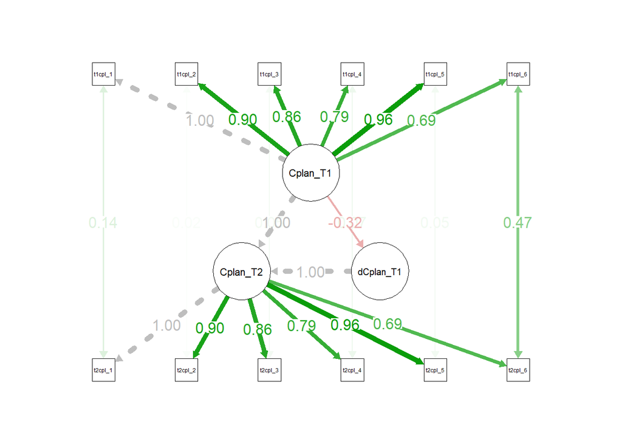

```r
library(semPlot)
semPaths(fitULCS_Cplan, what = "est", layout = "tree", intercepts = FALSE, residuals = FALSE, sizeMan = 4, sizeLat = 10, nCharNodes = 0, edge.label.cex = 1.2, fixedStyle = c("grey",3), curvePivot = TRUE)
```

```r
library(lavaan)
ULCS_Cplan_fixed<-'
Cplan_T1=~1*t1cpl_1+t1cpl_2+t1cpl_3+t1cpl_4+t1cpl_5+t1cpl_6                                 # This specifies the measurement model for Cplan_T1
Cplan_T2=~1*t2cpl_1+equal("Cplan_T1=~t1cpl_2")*t2cpl_2+equal("Cplan_T1=~t1cpl_3")*t2cpl_3
          +equal("Cplan_T1=~t1cpl_4")*t2cpl_4+equal("Cplan_T1=~t1cpl_5")*t2cpl_5
          +equal("Cplan_T1=~t1cpl_6")*t2cpl_6                                               # This specifies the measurement model  with the equality constrained factor loadings

Cplan_T2 ~ 1*Cplan_T1     # Fixed regression of Cplan_T2 on Cplan_T1

dCplan_T1 =~ 1*Cplan_T2   # Fixed regression of dCplan_T1 on Cplan_T2
dCplan_T1~Cplan_T1        # This estimates the self-feedback parameter


Cplan_T2 ~ 0*1            # This line constrains the intercept of Cplan_T2 to 0
Cplan_T2 ~~ 0*Cplan_T2    # This fixes the variance of the Cplan_T2 to 0

dCplan_T1 ~ 0*1             # This estimates the intercept of the change score
Cplan_T1 ~  1             # This estimates the intercept of Cplan_T1
dCplan_T1 ~~  dCplan_T1   # This estimates the variance of the change scores
Cplan_T1 ~~   Cplan_T1    # This estimates the variance of the Cplan_T1


t1cpl_1~~t2cpl_1   # This allows residual covariance on indicator 1 across T1 and T2
t1cpl_2~~t2cpl_2
t1cpl_3~~t2cpl_3
t1cpl_4~~t2cpl_4
t1cpl_5~~t2cpl_5
t1cpl_6~~t2cpl_6

t1cpl_1~~t1cpl_1   # This allows residual variance on indicator 1 at T1
t1cpl_2~~t1cpl_2
t1cpl_3~~t1cpl_3
t1cpl_4~~t1cpl_4
t1cpl_5~~t1cpl_5
t1cpl_6~~t1cpl_6

t2cpl_1~~t2cpl_1   # This allows residual variance on indicator 1 at T2
t2cpl_2~~t2cpl_2
t2cpl_3~~t2cpl_3
t2cpl_4~~t2cpl_4
t2cpl_5~~t2cpl_5
t2cpl_6~~t2cpl_6

t1cpl_1~0*1     # This constrains the intercept of ind 1 to 0 at T1
t1cpl_2~1
t1cpl_3~1
t1cpl_4~1
t1cpl_5~1
t1cpl_6~1


t2cpl_1~0*1    # This constrains the intercept of ind 1 to 0 at T2
t2cpl_2~equal("t1cpl_2~1")*1
t2cpl_3~equal("t1cpl_3~1")*1
t2cpl_4~equal("t1cpl_4~1")*1
t2cpl_5~equal("t1cpl_5~1")*1
t2cpl_6~equal("t1cpl_6~1")*1
'

fitULCS_Cplan_fixed <- lavaan(ULCS_Cplan_fixed, data =my_dat, estimator = 'mlr', fixed.x = FALSE,missing = 'fiml')
summary(fitULCS_Cplan_fixed, fit.measures=TRUE, standardized=TRUE, rsquare=TRUE)
```

```
## lavaan 0.6-5 ended normally after 62 iterations
##
##   Estimator                                         ML
##   Optimization method                           NLMINB
##   Number of free parameters                         42
##   Number of equality constraints                    10
##   Row rank of the constraints matrix                10
##
##                                                   Used       Total
##   Number of observations                           299         300
##   Number of missing patterns                         2
##
## Model Test User Model:
##                                               Standard      Robust
##   Test Statistic                               199.504     164.830
##   Degrees of freedom                                58          58
##   P-value (Chi-square)                           0.000       0.000
##   Scaling correction factor                                  1.210
##     for the Yuan-Bentler correction (Mplus variant)
##
## Model Test Baseline Model:
##
##   Test statistic                              2309.029    1695.586
##   Degrees of freedom                                66          66
##   P-value                                        0.000       0.000
##   Scaling correction factor                                  1.362
##
## User Model versus Baseline Model:
##
##   Comparative Fit Index (CFI)                    0.937       0.934
##   Tucker-Lewis Index (TLI)                       0.928       0.925
##
##   Robust Comparative Fit Index (CFI)                         0.942
##   Robust Tucker-Lewis Index (TLI)                            0.934
##
## Loglikelihood and Information Criteria:
##
##   Loglikelihood user model (H0)              -3829.703   -3829.703
##   Scaling correction factor                                  0.903
##       for the MLR correction
```

[output cut: 107 more lines]

```
##                    Estimate
##     Cplan_T2          1.000
##     dCplan_T1         0.016
##     t1cpl_1           0.702
##     t1cpl_2           0.747
##     t1cpl_3           0.705
##     t1cpl_4           0.597
##     t1cpl_5           0.690
##     t1cpl_6           0.351
##     t2cpl_1           0.757
##     t2cpl_2           0.792
##     t2cpl_3           0.743
##     t2cpl_4           0.598
##     t2cpl_5           0.771
##     t2cpl_6           0.401
```

```r
parameterEstimates(fitULCS_Cplan_fixed)
```

```
##          lhs op       rhs             label    est    se      z pvalue ci.lower
## 1   Cplan_T1 =~   t1cpl_1                    1.000 0.000     NA     NA    1.000
## 2   Cplan_T1 =~   t1cpl_2              .p2.  0.902 0.035 25.763  0.000    0.834
## 3   Cplan_T1 =~   t1cpl_3              .p3.  0.860 0.040 21.396  0.000    0.781
## 4   Cplan_T1 =~   t1cpl_4              .p4.  0.790 0.046 17.022  0.000    0.699
## 5   Cplan_T1 =~   t1cpl_5              .p5.  0.954 0.035 27.142  0.000    0.885
## 6   Cplan_T1 =~   t1cpl_6              .p6.  0.683 0.051 13.464  0.000    0.584
## 7   Cplan_T2 =~   t2cpl_1                    1.000 0.000     NA     NA    1.000
## 8   Cplan_T2 =~   t2cpl_2 Cplan_T1=~t1cpl_2  0.902 0.035 25.763  0.000    0.834
## 9   Cplan_T2 =~   t2cpl_3 Cplan_T1=~t1cpl_3  0.860 0.040 21.396  0.000    0.781
## 10  Cplan_T2 =~   t2cpl_4 Cplan_T1=~t1cpl_4  0.790 0.046 17.022  0.000    0.699
## 11  Cplan_T2 =~   t2cpl_5 Cplan_T1=~t1cpl_5  0.954 0.035 27.142  0.000    0.885
## 12  Cplan_T2 =~   t2cpl_6 Cplan_T1=~t1cpl_6  0.683 0.051 13.464  0.000    0.584
## 13  Cplan_T2  ~  Cplan_T1                    1.000 0.000     NA     NA    1.000
## 14 dCplan_T1 =~  Cplan_T2                    1.000 0.000     NA     NA    1.000
```

[output cut: 89 more lines]

```r
# anova
aov_cpl_free_fixed = anova(fitULCS_Cplan, fitULCS_Cplan_fixed)
aov_cpl_free_fixed
```

```
## Scaled Chi-Squared Difference Test (method = "satorra.bentler.2001")
##
## lavaan NOTE:
##     The "Chisq" column contains standard test statistics, not the
##     robust test that should be reported per model. A robust difference
##     test is a function of two standard (not robust) statistics.
##
##                     Df    AIC    BIC  Chisq Chisq diff Df diff Pr(>Chisq)
## fitULCS_Cplan       57 7704.7 7826.8 178.79
## fitULCS_Cplan_fixed 58 7723.4 7841.8 199.50     26.795       1  2.262e-07 ***
## ---
## Signif. codes:  0 '***' 0.001 '**' 0.01 '*' 0.05 '.' 0.1 ' ' 1
```

```r
aov_cpl_free_fixed[, 7][2]
```

```
## [1] 2.262495e-07
```

```r
aov_cpl_free_fixed[, 7][2] <- format.pval(aov_cpl_free_fixed[ , 7][2], eps = .001, digits = 3)
aov_cpl_free_fixed[, 7][1] <- "-"
options(knitr.kable.NA = '-')
row.names(aov_cpl)[1:2] = c("Free mean change", "Mean change fixed to zero")
```

```r
kable(aov_cpl, col.names = c("Df", "Chisq", "AIC", "BIC", "Chisq diff", "Df diff", "p"), escape=FALSE,format = "html", booktabs = TRUE, digits = 2,
caption = 'Model comparison career planning: Free mean change vs. mean change fixed to zero') %>%
  kable_styling(position = 'left', full_width = F)
```

Df

Chisq

AIC

BIC

Chisq diff

Df diff

p

Free mean change

4500.44

4570.75

41.62

Mean change fixed to zero

9

4525.06

4591.67

68.24

1

<0.001

## 9.2 Univariate Latent Change Score Model Self-efficacy

```r
library(lavaan)
ULCS_SE<-'
SE_T1=~1*t1se_1+t1se_2+t1se_3+t1se_4+t1se_5+t1se_6+t1se_7+t1se_8                                 # This specifies the measurement model for SE_T1
SE_T2=~1*t2se_1+equal("SE_T1=~t1se_2")*t2se_2+equal("SE_T1=~t1se_3")*t2se_3
          +equal("SE_T1=~t1se_4")*t2se_4+equal("SE_T1=~t1se_5")*t2se_5
          +equal("SE_T1=~t1se_6")*t2se_7+equal("SE_T1=~t1se_7")*t2se_6 +equal("SE_T1=~t1se_8")*t2se_8                                          # This specifies the measurement model  with the equality constrained factor loadings

SE_T2 ~ 1*SE_T1     # Fixed regression of SE_T2 on SE_T1

dSE_T1 =~ 1*SE_T2   # Fixed regression of dSE_T1 on SE_T2
dSE_T1~SE_T1        # This estimates the self-feedback parameter


SE_T2 ~ 0*1            # This line constrains the intercept of SE_T2 to 0
SE_T2 ~~ 0*SE_T2    # This fixes the variance of the SE_T2 to 0

dSE_T1 ~ 1             # This estimates the intercept of the change score
SE_T1 ~  1             # This estimates the intercept of SE_T1
dSE_T1 ~~  dSE_T1   # This estimates the variance of the change scores
SE_T1 ~~   SE_T1    # This estimates the variance of the Cplan_T1


t1se_1~~t2se_1   # This allows residual covariance on indicator 1 across T1 and T2
t1se_2~~t2se_2
t1se_3~~t2se_3
t1se_4~~t2se_4
t1se_5~~t2se_5
t1se_6~~t2se_6
t1se_7~~t2se_7
t1se_8~~t2se_8


t1se_1~~t1se_1   # This allows residual variance on indicator 1 at T1
t1se_2~~t1se_2
t1se_3~~t1se_3
t1se_4~~t1se_4
t1se_5~~t1se_5
t1se_6~~t1se_6
t1se_7~~t1se_7
t1se_8~~t1se_8


t2se_1~~t2se_1   # This allows residual variance on indicator 1 at T2
t2se_2~~t2se_2
t2se_3~~t2se_3
t2se_4~~t2se_4
t2se_5~~t2se_5
t2se_6~~t2se_6
t2se_7~~t2se_7
t2se_8~~t2se_8


t1se_1~0*1     # This constrains the intercept of ind 1 to 0 at T1
t1se_2~1
t1se_3~1
t1se_4~1
t1se_5~1
t1se_6~1
t1se_7~1
t1se_8~1



t2se_1~0*1    # This constrains the intercept of ind 1 to 0 at T2
t2se_2~equal("t1se_2~1")*1
t2se_3~equal("t1se_3~1")*1
t2se_4~equal("t1se_4~1")*1
t2se_5~equal("t1se_5~1")*1
t2se_6~equal("t1se_6~1")*1
t2se_7~equal("t1se_7~1")*1
t2se_8~equal("t1se_8~1")*1

'

fitULCS_SE <- lavaan(ULCS_SE, data =my_dat, estimator = 'mlr', fixed.x = FALSE,missing = 'fiml')
summary(fitULCS_SE, fit.measures=TRUE, standardized=TRUE, rsquare=TRUE)
```

```
## lavaan 0.6-5 ended normally after 113 iterations
##
##   Estimator                                         ML
##   Optimization method                           NLMINB
##   Number of free parameters                         57
##   Number of equality constraints                    14
##   Row rank of the constraints matrix                14
##
##   Number of observations                           300
##   Number of missing patterns                         2
##
## Model Test User Model:
##                                               Standard      Robust
##   Test Statistic                               294.442     231.766
##   Degrees of freedom                               109         109
##   P-value (Chi-square)                           0.000       0.000
##   Scaling correction factor                                  1.270
##     for the Yuan-Bentler correction (Mplus variant)
##
## Model Test Baseline Model:
##
##   Test statistic                              2176.541    1672.415
##   Degrees of freedom                               120         120
##   P-value                                        0.000       0.000
##   Scaling correction factor                                  1.301
##
## User Model versus Baseline Model:
##
##   Comparative Fit Index (CFI)                    0.910       0.921
##   Tucker-Lewis Index (TLI)                       0.901       0.913
##
##   Robust Comparative Fit Index (CFI)                         0.923
##   Robust Tucker-Lewis Index (TLI)                            0.915
##
## Loglikelihood and Information Criteria:
##
##   Loglikelihood user model (H0)              -4289.924   -4289.924
##   Scaling correction factor                                  1.039
##       for the MLR correction
##   Loglikelihood unrestricted model (H1)             NA          NA
```

[output cut: 126 more lines]

```
##     t1se_2            0.474
##     t1se_3            0.544
##     t1se_4            0.553
##     t1se_5            0.603
##     t1se_6            0.521
##     t1se_7            0.359
##     t1se_8            0.404
##     t2se_1            0.453
##     t2se_2            0.507
##     t2se_3            0.559
##     t2se_4            0.612
##     t2se_5            0.574
##     t2se_6            0.538
##     t2se_7            0.381
##     t2se_8            0.362
```

```r
parameterEstimates(fitULCS_SE)
```

```
##       lhs op    rhs         label    est    se      z pvalue ci.lower ci.upper
## 1   SE_T1 =~ t1se_1                1.000 0.000     NA     NA    1.000    1.000
## 2   SE_T1 =~ t1se_2          .p2.  1.149 0.073 15.771  0.000    1.006    1.291
## 3   SE_T1 =~ t1se_3          .p3.  1.028 0.067 15.438  0.000    0.898    1.159
## 4   SE_T1 =~ t1se_4          .p4.  1.162 0.075 15.430  0.000    1.014    1.310
## 5   SE_T1 =~ t1se_5          .p5.  1.115 0.090 12.329  0.000    0.938    1.292
## 6   SE_T1 =~ t1se_6          .p6.  1.007 0.096 10.477  0.000    0.818    1.195
## 7   SE_T1 =~ t1se_7          .p7.  1.006 0.096 10.505  0.000    0.819    1.194
## 8   SE_T1 =~ t1se_8          .p8.  0.909 0.097  9.388  0.000    0.719    1.098
## 9   SE_T2 =~ t2se_1                1.000 0.000     NA     NA    1.000    1.000
## 10  SE_T2 =~ t2se_2 SE_T1=~t1se_2  1.149 0.073 15.771  0.000    1.006    1.291
## 11  SE_T2 =~ t2se_3 SE_T1=~t1se_3  1.028 0.067 15.438  0.000    0.898    1.159
## 12  SE_T2 =~ t2se_4 SE_T1=~t1se_4  1.162 0.075 15.430  0.000    1.014    1.310
## 13  SE_T2 =~ t2se_5 SE_T1=~t1se_5  1.115 0.090 12.329  0.000    0.938    1.292
## 14  SE_T2 =~ t2se_7 SE_T1=~t1se_6  1.007 0.096 10.477  0.000    0.818    1.195
```

[output cut: 51 more lines]

```r
paras_ULCS_SE <- parameterEstimates(fitULCS_SE)[c(19,22,23,24,25), ]
for (i in seq_along(paras_ULCS_SE)) {
    if (is.numeric(i)) {
      round(i, 3)
    }
}
paras_ULCS_SE$label <- NULL
paras_ULCS_SE
```

```
##       lhs op    rhs    est    se      z pvalue ci.lower ci.upper
## 19 dSE_T1  ~  SE_T1 -0.290 0.077 -3.780      0   -0.440   -0.139
## 22 dSE_T1 ~1         1.098 0.308  3.559      0    0.493    1.702
## 23  SE_T1 ~1         3.880 0.045 86.571      0    3.792    3.968
## 24 dSE_T1 ~~ dSE_T1  0.169 0.032  5.225      0    0.105    0.232
## 25  SE_T1 ~~  SE_T1  0.314 0.052  6.064      0    0.213    0.415
```

```r
rownames(paras_ULCS_SE) <- NULL
fitULCS_SE_meas <- generate_cfa_fitmeasures(fitULCS_SE)
```

```
## # A tibble: 1 x 10
##   Chi_Sq  df      p     CFI   TLI   AIC      BIC      RMSEA RMSEA.CI    SRMR
##   <chr>   <chr>   <chr> <chr> <chr> <chr>    <chr>    <chr> <glue>      <chr>
## 1 294.442 109.000 0.000 0.910 0.901 8665.848 8825.111 0.075 0.065-0.086 0.061
```

```r
for (i in seq_along(fitULCS_SE_meas)) {
    if (is.numeric(i)) {
      round(i, 3)
    }
}
```

```r
library(kableExtra)
knitr::kable(fitULCS_SE_meas, escape=FALSE, digits = 3, format = "html", booktabs = TRUE, caption = "Fit indices of a univariate latent change score model for self-efficacy") %>%
  kable_styling(position = 'left', full_width = F)
```

Fit indices of a univariate latent change score model for self-efficacy

| Chi_Sq | df | p | CFI | TLI | AIC | BIC | RMSEA | RMSEA.CI | SRMR |
| --- | --- | --- | --- | --- | --- | --- | --- | --- | --- |
| 294.442 | 109.000 | 0.000 | 0.910 | 0.901 | 8665.848 | 8825.111 | 0.075 | 0.065-0.086 | 0.061 |

```r
kableExtra::kable(paras_ULCS_SE, booktabs = TRUE, format = 'html', escape = FALSE, caption = "Parameter estimates of a univariate latent change score model for self-efficacy") %>%
  kable_styling(position = 'left', full_width = F)
```

Parameter estimates of a univariate latent change score model for self-efficacy

| lhs | op | rhs | est | se | z | pvalue | ci.lower | ci.upper |
| --- | --- | --- | --- | --- | --- | --- | --- | --- |
| dSE_T1 | ~ | SE_T1 | -0.2895763 | 0.0766142 | -3.779670 | 0.0001570 | -0.4397373 | -0.1394153 |
| dSE_T1 | ~1 |  | 1.0977415 | 0.3084051 | 3.559414 | 0.0003717 | 0.4932786 | 1.7022043 |
| SE_T1 | ~1 |  | 3.8798603 | 0.0448169 | 86.571324 | 0.0000000 | 3.7920207 | 3.9676998 |
| dSE_T1 | ~~ | dSE_T1 | 0.1685377 | 0.0322554 | 5.225097 | 0.0000002 | 0.1053183 | 0.2317572 |
| SE_T1 | ~~ | SE_T1 | 0.3139808 | 0.0517751 | 6.064323 | 0.0000000 | 0.2125035 | 0.4154581 |

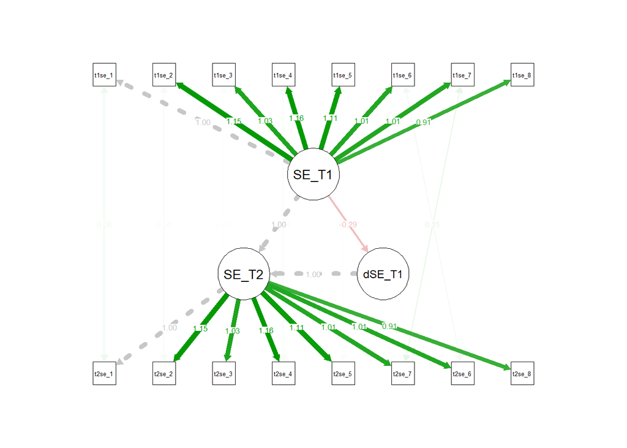

```r
semPaths(fitULCS_SE, what = "est", layout = "tree", intercepts = FALSE, residuals = FALSE, sizeMan = 4, sizeLat = 9, nCharNodes = 0, edge.label.cex = 0.6, fixedStyle = c("grey",3), curvePivot = TRUE)
```

```r
library(lavaan)
ULCS_SE_fixed<-'
SE_T1=~1*t1se_1+t1se_2+t1se_3+t1se_4+t1se_5+t1se_6+t1se_7+t1se_8                                 # This specifies the measurement model for SE_T1
SE_T2=~1*t2se_1+equal("SE_T1=~t1se_2")*t2se_2+equal("SE_T1=~t1se_3")*t2se_3
          +equal("SE_T1=~t1se_4")*t2se_4+equal("SE_T1=~t1se_5")*t2se_5
          +equal("SE_T1=~t1se_6")*t2se_7+equal("SE_T1=~t1se_7")*t2se_6 +equal("SE_T1=~t1se_8")*t2se_8                                          # This specifies the measurement model  with the equality constrained factor loadings

SE_T2 ~ 1*SE_T1     # Fixed regression of SE_T2 on SE_T1

dSE_T1 =~ 1*SE_T2   # Fixed regression of dSE_T1 on SE_T2
dSE_T1~SE_T1        # This estimates the self-feedback parameter


SE_T2 ~ 0*1            # This line constrains the intercept of SE_T2 to 0
SE_T2 ~~ 0*SE_T2    # This fixes the variance of the SE_T2 to 0

dSE_T1 ~ 0*1             # This estimates the intercept of the change score
SE_T1 ~  1             # This estimates the intercept of SE_T1
dSE_T1 ~~  dSE_T1   # This estimates the variance of the change scores
SE_T1 ~~   SE_T1    # This estimates the variance of the Cplan_T1


t1se_1~~t2se_1   # This allows residual covariance on indicator 1 across T1 and T2
t1se_2~~t2se_2
t1se_3~~t2se_3
t1se_4~~t2se_4
t1se_5~~t2se_5
t1se_6~~t2se_6
t1se_7~~t2se_7
t1se_8~~t2se_8


t1se_1~~t1se_1   # This allows residual variance on indicator 1 at T1
t1se_2~~t1se_2
t1se_3~~t1se_3
t1se_4~~t1se_4
t1se_5~~t1se_5
t1se_6~~t1se_6
t1se_7~~t1se_7
t1se_8~~t1se_8


t2se_1~~t2se_1   # This allows residual variance on indicator 1 at T2
t2se_2~~t2se_2
t2se_3~~t2se_3
t2se_4~~t2se_4
t2se_5~~t2se_5
t2se_6~~t2se_6
t2se_7~~t2se_7
t2se_8~~t2se_8


t1se_1~0*1     # This constrains the intercept of ind 1 to 0 at T1
t1se_2~1
t1se_3~1
t1se_4~1
t1se_5~1
t1se_6~1
t1se_7~1
t1se_8~1



t2se_1~0*1    # This constrains the intercept of ind 1 to 0 at T2
t2se_2~equal("t1se_2~1")*1
t2se_3~equal("t1se_3~1")*1
t2se_4~equal("t1se_4~1")*1
t2se_5~equal("t1se_5~1")*1
t2se_6~equal("t1se_6~1")*1
t2se_7~equal("t1se_7~1")*1
t2se_8~equal("t1se_8~1")*1

'

fitULCS_SE_fixed <- lavaan(ULCS_SE_fixed, data =my_dat, estimator = 'mlr', fixed.x = FALSE,missing = 'fiml')

# anova
aov_cpl_free_fixed = anova(fitULCS_SE, fitULCS_SE_fixed)
aov_cpl_free_fixed
```

```
## Scaled Chi-Squared Difference Test (method = "satorra.bentler.2001")
##
## lavaan NOTE:
##     The "Chisq" column contains standard test statistics, not the
##     robust test that should be reported per model. A robust difference
##     test is a function of two standard (not robust) statistics.
##
##                   Df    AIC    BIC  Chisq Chisq diff Df diff Pr(>Chisq)
## fitULCS_SE       109 8665.8 8825.1 294.44
## fitULCS_SE_fixed 110 8686.2 8841.7 316.74     12.754       1  0.0003552 ***
## ---
## Signif. codes:  0 '***' 0.001 '**' 0.01 '*' 0.05 '.' 0.1 ' ' 1
```

```r
aov_cpl_free_fixed[, 7][2]
```

```
## [1] 0.0003552047
```

```r
aov_cpl_free_fixed[, 7][2] <- format.pval(aov_cpl_free_fixed[ , 7][2], eps = .001, digits = 3)
aov_cpl_free_fixed[, 7][1] <- "-"
options(knitr.kable.NA = '-')
row.names(aov_cpl)[1:2] = c("Free mean change", "Mean change fixed to zero")
```

```r
kable(aov_cpl, col.names = c("Df", "Chisq", "AIC", "BIC", "Chisq diff", "Df diff", "p"), escape=FALSE,format = "html", booktabs = TRUE, digits = 2,
caption = 'Model comparison self-efficacy: Free mean change vs. mean change fixed to zero') %>%
  kable_styling(position = 'left', full_width = F)
```

Df

Chisq

AIC

BIC

Chisq diff

Df diff

p

Free mean change

4500.44

4570.75

41.62

Mean change fixed to zero

9

4525.06

4591.67

68.24

1

<0.001

## 9.3 Univariate Latent Change Score Model Worry

```r
library(lavaan)
ULCS_WOR<-'
WOR_T1=~1*t1wor_1+t1wor_2+t1wor_3+t1wor_4                              # This specifies the measurement model for WOR_T1
WOR_T2=~1*t2wor_1+equal("WOR_T1=~t1wor_2")*t2wor_2+equal("WOR_T1=~t1wor_3")*t2wor_3
          +equal("WOR_T1=~t1wor_4")*t2wor_4                                       # This specifies the measurement model  with the equality constrained factor loadings

WOR_T2 ~ 1*WOR_T1     # Fixed regression of WOR_T2 on WOR_T1

dWOR_T1 =~ 1*WOR_T2   # Fixed regression of dWOR_T1 on WOR_T2
dWOR_T1~WOR_T1        # This estimates the self-feedback parameter


WOR_T2 ~ 0*1            # This line constrains the intercept of WOR_T2 to 0
WOR_T2 ~~ 0*WOR_T2    # This fixes the variance of the WOR_T2 to 0

dWOR_T1 ~ 1             # This estimates the intercept of the change score
WOR_T1 ~  1             # This estimates the intercept of WOR_T1
dWOR_T1 ~~  dWOR_T1   # This estimates the variance of the change scores
WOR_T1 ~~   WOR_T1    # This estimates the variance of the Cplan_T1


t1wor_1~~t2wor_1   # This allows residual covariance on indicator 1 across T1 and T2
t1wor_2~~t2wor_2
t1wor_3~~t2wor_3
t1wor_4~~t2wor_4

t1wor_1~~t1wor_1   # This allows residual variance on indicator 1 at T1
t1wor_2~~t1wor_2
t1wor_3~~t1wor_3
t1wor_4~~t1wor_4

t2wor_1~~t2wor_1   # This allows residual variance on indicator 1 at T2
t2wor_2~~t2wor_2
t2wor_3~~t2wor_3
t2wor_4~~t2wor_4

t1wor_1~0*1     # This constrains the intercept of ind 1 to 0 at T1
t1wor_2~1
t1wor_3~1
t1wor_4~1

t2wor_1~0*1    # This constrains the intercept of ind 1 to 0 at T2
t2wor_2~equal("t1wor_2~1")*1
t2wor_3~equal("t1wor_3~1")*1
t2wor_4~equal("t1wor_4~1")*1
'

fitULCS_WOR <- lavaan(ULCS_WOR, data =my_dat, estimator = 'mlr', fixed.x = FALSE,missing = 'fiml')
summary(fitULCS_WOR, fit.measures=TRUE, standardized=TRUE, rsquare=TRUE)
```

```
## lavaan 0.6-5 ended normally after 47 iterations
##
##   Estimator                                         ML
##   Optimization method                           NLMINB
##   Number of free parameters                         29
##   Number of equality constraints                     6
##   Row rank of the constraints matrix                 6
##
##                                                   Used       Total
##   Number of observations                           299         300
##   Number of missing patterns                         2
##
## Model Test User Model:
##                                               Standard      Robust
##   Test Statistic                                38.464      33.978
##   Degrees of freedom                                21          21
##   P-value (Chi-square)                           0.011       0.036
##   Scaling correction factor                                  1.132
##     for the Yuan-Bentler correction (Mplus variant)
##
## Model Test Baseline Model:
##
##   Test statistic                              1038.681     790.370
##   Degrees of freedom                                28          28
##   P-value                                        0.000       0.000
##   Scaling correction factor                                  1.314
##
## User Model versus Baseline Model:
##
##   Comparative Fit Index (CFI)                    0.983       0.983
##   Tucker-Lewis Index (TLI)                       0.977       0.977
##
##   Robust Comparative Fit Index (CFI)                         0.985
##   Robust Tucker-Lewis Index (TLI)                            0.980
##
## Loglikelihood and Information Criteria:
##
##   Loglikelihood user model (H0)              -2479.564   -2479.564
##   Scaling correction factor                                  0.856
##       for the MLR correction
```

[output cut: 87 more lines]

```
##    .t2wor_3           0.706    0.063   11.283    0.000    0.706    0.681
##    .t2wor_4           0.266    0.045    5.973    0.000    0.266    0.309
##
## R-Square:
##                    Estimate
##     WOR_T2            1.000
##     dWOR_T1           0.336
##     t1wor_1           0.672
##     t1wor_2           0.700
##     t1wor_3           0.414
##     t1wor_4           0.678
##     t2wor_1           0.624
##     t2wor_2           0.561
##     t2wor_3           0.319
##     t2wor_4           0.691
```

```r
parameterEstimates(fitULCS_WOR)
```

```
##        lhs op     rhs           label    est    se      z pvalue ci.lower
## 1   WOR_T1 =~ t1wor_1                  1.000 0.000     NA     NA    1.000
## 2   WOR_T1 =~ t1wor_2            .p2.  1.040 0.052 20.094  0.000    0.939
## 3   WOR_T1 =~ t1wor_3            .p3.  0.810 0.063 12.923  0.000    0.687
## 4   WOR_T1 =~ t1wor_4            .p4.  1.087 0.059 18.472  0.000    0.972
## 5   WOR_T2 =~ t2wor_1                  1.000 0.000     NA     NA    1.000
## 6   WOR_T2 =~ t2wor_2 WOR_T1=~t1wor_2  1.040 0.052 20.094  0.000    0.939
## 7   WOR_T2 =~ t2wor_3 WOR_T1=~t1wor_3  0.810 0.063 12.923  0.000    0.687
## 8   WOR_T2 =~ t2wor_4 WOR_T1=~t1wor_4  1.087 0.059 18.472  0.000    0.972
## 9   WOR_T2  ~  WOR_T1                  1.000 0.000     NA     NA    1.000
## 10 dWOR_T1 =~  WOR_T2                  1.000 0.000     NA     NA    1.000
## 11 dWOR_T1  ~  WOR_T1                 -0.448 0.056 -7.947  0.000   -0.559
## 12  WOR_T2 ~1                          0.000 0.000     NA     NA    0.000
## 13  WOR_T2 ~~  WOR_T2                  0.000 0.000     NA     NA    0.000
## 14 dWOR_T1 ~1                          1.021 0.141  7.260  0.000    0.745
```

[output cut: 61 more lines]

```r
paras_ULCS_WOR <- parameterEstimates(fitULCS_WOR)[c(11,14:17), ]
for (i in seq_along(paras_ULCS_WOR)) {
    if (is.numeric(i)) {
      round(i, 3)
    }
}
paras_ULCS_WOR$label <- NULL
paras_ULCS_WOR
```

```
##        lhs op     rhs    est    se      z pvalue ci.lower ci.upper
## 11 dWOR_T1  ~  WOR_T1 -0.448 0.056 -7.947      0   -0.559   -0.338
## 14 dWOR_T1 ~1          1.021 0.141  7.260      0    0.745    1.297
## 15  WOR_T1 ~1          2.404 0.058 41.671      0    2.291    2.518
## 16 dWOR_T1 ~~ dWOR_T1  0.286 0.041  6.927      0    0.205    0.367
## 17  WOR_T1 ~~  WOR_T1  0.719 0.073  9.857      0    0.576    0.862
```

```r
rownames(paras_ULCS_WOR) <- NULL
fitULCS_wor_meas <- generate_cfa_fitmeasures(fitULCS_WOR)
```

```
## # A tibble: 1 x 10
##   Chi_Sq df     p     CFI   TLI   AIC      BIC      RMSEA RMSEA.CI    SRMR
##   <chr>  <chr>  <chr> <chr> <chr> <chr>    <chr>    <chr> <glue>      <chr>
## 1 38.464 21.000 0.011 0.983 0.977 5005.128 5090.239 0.053 0.025-0.079 0.039
```

```r
for (i in seq_along(fitULCS_wor_meas)) {
    if (is.numeric(i)) {
      round(i, 3)
    }
}
```

```r
library(kableExtra)
knitr::kable(fitULCS_wor_meas, escape=FALSE, digits = 3, format = "html", booktabs = TRUE, caption = "Fit indices of a univariate latent change score model for worry") %>%
  kable_styling(position = 'left', full_width = F)
```

Fit indices of a univariate latent change score model for worry

| Chi_Sq | df | p | CFI | TLI | AIC | BIC | RMSEA | RMSEA.CI | SRMR |
| --- | --- | --- | --- | --- | --- | --- | --- | --- | --- |
| 38.464 | 21.000 | 0.011 | 0.983 | 0.977 | 5005.128 | 5090.239 | 0.053 | 0.025-0.079 | 0.039 |

```r
kableExtra::kable(paras_ULCS_WOR, booktabs = TRUE, format = 'html', escape = FALSE, caption = "Parameter estimates of a univariate latent change score model for worry") %>%
  kable_styling(position = 'left', full_width = F)
```

Parameter estimates of a univariate latent change score model for worry

| lhs | op | rhs | est | se | z | pvalue | ci.lower | ci.upper |
| --- | --- | --- | --- | --- | --- | --- | --- | --- |
| dWOR_T1 | ~ | WOR_T1 | -0.4484253 | 0.0564258 | -7.947170 | 0 | -0.5590178 | -0.3378328 |
| dWOR_T1 | ~1 |  | 1.0208968 | 0.1406198 | 7.259980 | 0 | 0.7452871 | 1.2965066 |
| WOR_T1 | ~1 |  | 2.4044876 | 0.0577013 | 41.671268 | 0 | 2.2913951 | 2.5175802 |
| dWOR_T1 | ~~ | dWOR_T1 | 0.2858888 | 0.0412707 | 6.927161 | 0 | 0.2049997 | 0.3667780 |
| WOR_T1 | ~~ | WOR_T1 | 0.7186959 | 0.0729097 | 9.857342 | 0 | 0.5757955 | 0.8615963 |

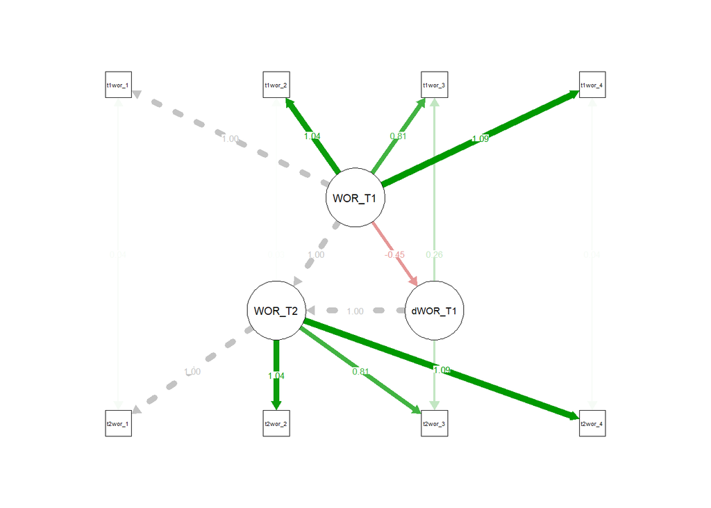

```r
semPaths(fitULCS_WOR, what = "est", layout = "tree", intercepts = FALSE, residuals = FALSE, sizeMan = 4, sizeLat = 9, nCharNodes = 0, edge.label.cex = 0.6, fixedStyle = c("grey",3), curvePivot = TRUE)
```

```r
library(lavaan)
ULCS_wor_fixed<-'
WOR_T1=~1*t1wor_1+t1wor_2+t1wor_3+t1wor_4                                # This specifies the measurement model for WOR_T1
WOR_T2=~1*t2wor_1+equal("WOR_T1=~t1wor_2")*t2wor_2+equal("WOR_T1=~t1wor_3")*t2wor_3
          +equal("WOR_T1=~t1wor_4")*t2wor_4                                       # This specifies the measurement model  with the equality constrained factor loadings

WOR_T2 ~ 1*WOR_T1     # Fixed regression of WOR_T2 on WOR_T1

dWOR_T1 =~ 1*WOR_T2   # Fixed regression of dWOR_T1 on WOR_T2
dWOR_T1~WOR_T1        # This estimates the self-feedback parameter


WOR_T2 ~ 0*1            # This line constrains the intercept of WOR_T2 to 0
WOR_T2 ~~ 0*WOR_T2    # This fixes the variance of the WOR_T2 to 0

dWOR_T1 ~ 0*1             # This estimates the intercept of the change score
WOR_T1 ~  1             # This estimates the intercept of WOR_T1
dWOR_T1 ~~  dWOR_T1   # This estimates the variance of the change scores
WOR_T1 ~~   WOR_T1    # This estimates the variance of the Cplan_T1


t1wor_1~~t2wor_1   # This allows residual covariance on indicator 1 across T1 and T2
t1wor_2~~t2wor_2
t1wor_3~~t2wor_3
t1wor_4~~t2wor_4

t1wor_1~~t1wor_1   # This allows residual variance on indicator 1 at T1
t1wor_2~~t1wor_2
t1wor_3~~t1wor_3
t1wor_4~~t1wor_4

t2wor_1~~t2wor_1   # This allows residual variance on indicator 1 at T2
t2wor_2~~t2wor_2
t2wor_3~~t2wor_3
t2wor_4~~t2wor_4

t1wor_1~0*1     # This constrains the intercept of ind 1 to 0 at T1
t1wor_2~1
t1wor_3~1
t1wor_4~1

t2wor_1~0*1    # This constrains the intercept of ind 1 to 0 at T2
t2wor_2~equal("t1wor_2~1")*1
t2wor_3~equal("t1wor_3~1")*1
t2wor_4~equal("t1wor_4~1")*1
'

fitULCS_wor_fixed <- lavaan(ULCS_wor_fixed, data =my_dat, estimator = 'mlr', fixed.x = FALSE,missing = 'fiml')
# anova
aov_cpl_free_fixed = anova(fitULCS_WOR, fitULCS_wor_fixed)
aov_cpl_free_fixed
```

```
## Scaled Chi-Squared Difference Test (method = "satorra.bentler.2001")
##
## lavaan NOTE:
##     The "Chisq" column contains standard test statistics, not the
##     robust test that should be reported per model. A robust difference
##     test is a function of two standard (not robust) statistics.
##
##                   Df    AIC    BIC  Chisq Chisq diff Df diff Pr(>Chisq)
## fitULCS_WOR       21 5005.1 5090.2 38.464
## fitULCS_wor_fixed 22 5052.6 5134.0 87.901     64.322       1  1.057e-15 ***
## ---
## Signif. codes:  0 '***' 0.001 '**' 0.01 '*' 0.05 '.' 0.1 ' ' 1
```

```r
aov_cpl_free_fixed[, 7][2]
```

```
## [1] 1.056526e-15
```

```r
aov_cpl_free_fixed[, 7][2] <- format.pval(aov_cpl_free_fixed[ , 7][2], eps = .001, digits = 3)
aov_cpl_free_fixed[, 7][1] <- "-"
options(knitr.kable.NA = '-')
row.names(aov_cpl)[1:2] = c("Free mean change", "Mean change fixed to zero")
```

```r
kable(aov_cpl, col.names = c("Df", "Chisq", "AIC", "BIC", "Chisq diff", "Df diff", "p"), escape=FALSE,format = "html", booktabs = TRUE, digits = 2,
caption = 'Model comparison worry: Free mean change vs. mean change fixed to zero') %>%
  kable_styling(position = 'left', full_width = F)
```

Df

Chisq

AIC

BIC

Chisq diff

Df diff

p

Free mean change

4500.44

4570.75

41.62

Mean change fixed to zero

9

4525.06

4591.67

68.24

1

<0.001

# 10 Bivariate LCSM

## 10.1 BLCSM: Career Planning - Worry

```r
library(lavaan)
library(glue)
BLCS_Cplan_worry<-'
Cplan_T1=~1*t1cpl_1+t1cpl_2+t1cpl_3+t1cpl_4+t1cpl_5+t1cpl_6  # This specifies the measurement model for Cplan_T1
Cplan_T2=~1*t2cpl_1+equal("Cplan_T1=~t1cpl_2")*t2cpl_2+equal("Cplan_T1=~t1cpl_3")*t2cpl_3
+equal("Cplan_T1=~t1cpl_4")*t2cpl_4+equal("Cplan_T1=~t1cpl_5")*t2cpl_5
+equal("Cplan_T1=~t1cpl_6")*t2cpl_6

t1cpl_1~~t2cpl_1   # This allows residual covariance on indicator 1 across T1 and T2
t1cpl_2~~t2cpl_2
t1cpl_3~~t2cpl_3
t1cpl_4~~t2cpl_4
t1cpl_5~~t2cpl_5
t1cpl_6~~t2cpl_6

t1cpl_1~~t1cpl_1   # This allows residual variance on indicator 1 at T1
t1cpl_2~~t1cpl_2
t1cpl_3~~t1cpl_3
t1cpl_4~~t1cpl_4
t1cpl_5~~t1cpl_5
t1cpl_6~~t1cpl_6

t2cpl_1~~t2cpl_1   # This allows residual variance on indicator 1 at T2
t2cpl_2~~t2cpl_2
t2cpl_3~~t2cpl_3
t2cpl_4~~t2cpl_4
t2cpl_5~~t2cpl_5
t2cpl_6~~t2cpl_6

t1cpl_1~0*1   # This constrains the intercept of ind 1 to 0 at T1
t1cpl_2~1
t1cpl_3~1
t1cpl_4~1
t1cpl_5~1
t1cpl_6~1


t2cpl_1~0*1    # This constrains the intercept of ind 1 to 0 at T2
t2cpl_2~equal("t1cpl_2~1")*1
t2cpl_3~equal("t1cpl_3~1")*1
t2cpl_4~equal("t1cpl_4~1")*1
t2cpl_5~equal("t1cpl_5~1")*1
t2cpl_6~equal("t1cpl_6~1")*1

Worry_T1=~1*t1wor_1+t1wor_2+t1wor_3+t1wor_4      # This specifies the measurement model
Worry_T2=~1*t2wor_1+equal("Worry_T1=~t1wor_2")*t2wor_2+equal("Worry_T1=~t1wor_3")*t2wor_3+equal("Worry_T2=~t1wor_4")*t2wor_4


t1wor_1~~t2wor_1   # This allows residual covariance on indicator 1 across T1 and T2
t1wor_2~~t2wor_2
t1wor_3~~t2wor_3
t1wor_4~~t2wor_4

t1wor_1~~t1wor_1   # This allows residual variance on indicator 1 at T1
t1wor_2~~t1wor_2
t1wor_3~~t1wor_3
t1wor_4~~t1wor_4

t2wor_1~~t2wor_1   # This allows residual variance on indicator 1 at T1
t2wor_2~~t2wor_2
t2wor_3~~t2wor_3
t2wor_4~~t2wor_4

t1wor_1~0*1    # This constrains the intercept of ind 1 to 0 at T1
t1wor_2~1
t1wor_3~1
t1wor_4~1

t2wor_1~0*1       # This constrains the intercept of ind 1 to 0 at T2
t2wor_2~equal("t1wor_2~1")*1
t2wor_3~equal("t1wor_3~1")*1
t2wor_4~equal("t1wor_4~1")*1


Cplan_T2 ~ 1*Cplan_T1     # Fixed regression of Cplan_T2 on Cplan_T1
dCplan_T1 =~ 1*Cplan_T2   # Fixed regression of dCplan_T1 on Cplan_T2
dCplan_T1 ~ 1             # This estimates the intercept of the change score
Cplan_T1 ~  1             # This estimates the intercept of Cplan_T1
Cplan_T2 ~ 0*1            # This line constrains the intercept of Cplan_T2 to 0


Worry_T2 ~ 1*Worry_T1     # Fixed regression of Worry_T2 on Worry_T1
dWorry_T1 =~ 1*Worry_T2   # Fixed regression of dWorry_T1 on Worry_T2
Worry_T2 ~ 0*1
Worry_T2 ~~ 0*Worry_T2


dCplan_T1 ~~  dCplan_T1   # This estimates the variance of the change scores
Cplan_T1 ~~   Cplan_T1    # This estimates the variance of the Cplan_T1
Cplan_T2 ~~   0*Cplan_T2  # This estimates the variance of the Cplan_T1

dWorry_T1 ~ 1
Worry_T1 ~ 1
dWorry_T1 ~~ dWorry_T1
Worry_T1 ~~ Worry_T1


# This estimates the coupling

dWorry_T1~Worry_T1+Cplan_T1
dCplan_T1~Worry_T1+Cplan_T1

Cplan_T1 ~~ Worry_T1
dCplan_T1 ~~ dWorry_T1
'

fit_BLCS_Cplan_worry <- lavaan(BLCS_Cplan_worry, data=my_dat, estimator='mlr',fixed.x=FALSE,missing='fiml')
summary(fit_BLCS_Cplan_worry, fit.measures=TRUE, standardized=TRUE, rsquare=TRUE)
```

```
## lavaan 0.6-5 ended normally after 92 iterations
##
##   Estimator                                         ML
##   Optimization method                           NLMINB
##   Number of free parameters                         76
##   Number of equality constraints                    15
##   Row rank of the constraints matrix                15
##
##                                                   Used       Total
##   Number of observations                           299         300
##   Number of missing patterns                         3
##
## Model Test User Model:
##                                               Standard      Robust
##   Test Statistic                               345.416     307.921
##   Degrees of freedom                               169         169
##   P-value (Chi-square)                           0.000       0.000
##   Scaling correction factor                                  1.122
##     for the Yuan-Bentler correction (Mplus variant)
##
## Model Test Baseline Model:
##
##   Test statistic                              3564.628    2969.246
##   Degrees of freedom                               190         190
##   P-value                                        0.000       0.000
##   Scaling correction factor                                  1.201
##
## User Model versus Baseline Model:
##
##   Comparative Fit Index (CFI)                    0.948       0.950
##   Tucker-Lewis Index (TLI)                       0.941       0.944
##
##   Robust Comparative Fit Index (CFI)                         0.953
##   Robust Tucker-Lewis Index (TLI)                            0.947
##
## Loglikelihood and Information Criteria:
##
##   Loglikelihood user model (H0)              -6254.532   -6254.532
##   Scaling correction factor                                  0.902
##       for the MLR correction
```

[output cut: 169 more lines]

```
##     t2cpl_4           0.517
##     t2cpl_5           0.710
##     t2cpl_6           0.324
##     t1wor_1           0.683
##     t1wor_2           0.687
##     t1wor_3           0.420
##     t1wor_4           0.676
##     t2wor_1           0.630
##     t2wor_2           0.562
##     t2wor_3           0.327
##     t2wor_4           0.677
##     Worry_T2          1.000
##     dCplan_T1         0.186
##     Cplan_T2          1.000
##     dWorry_T1         0.364
```

```r
parameterEstimates(fit_BLCS_Cplan_worry)
```

```
##          lhs op       rhs             label    est    se      z pvalue ci.lower
## 1   Cplan_T1 =~   t1cpl_1                    1.000 0.000     NA     NA    1.000
## 2   Cplan_T1 =~   t1cpl_2              .p2.  0.903 0.035 25.935  0.000    0.835
## 3   Cplan_T1 =~   t1cpl_3              .p3.  0.861 0.040 21.667  0.000    0.783
## 4   Cplan_T1 =~   t1cpl_4              .p4.  0.791 0.046 17.053  0.000    0.700
## 5   Cplan_T1 =~   t1cpl_5              .p5.  0.959 0.035 27.472  0.000    0.891
## 6   Cplan_T1 =~   t1cpl_6              .p6.  0.685 0.050 13.574  0.000    0.586
## 7   Cplan_T2 =~   t2cpl_1                    1.000 0.000     NA     NA    1.000
## 8   Cplan_T2 =~   t2cpl_2 Cplan_T1=~t1cpl_2  0.903 0.035 25.935  0.000    0.835
## 9   Cplan_T2 =~   t2cpl_3 Cplan_T1=~t1cpl_3  0.861 0.040 21.667  0.000    0.783
## 10  Cplan_T2 =~   t2cpl_4 Cplan_T1=~t1cpl_4  0.791 0.046 17.053  0.000    0.700
## 11  Cplan_T2 =~   t2cpl_5 Cplan_T1=~t1cpl_5  0.959 0.035 27.472  0.000    0.891
## 12  Cplan_T2 =~   t2cpl_6 Cplan_T1=~t1cpl_6  0.685 0.050 13.574  0.000    0.586
## 13   t1cpl_1 ~~   t2cpl_1                    0.134 0.037  3.635  0.000    0.062
## 14   t1cpl_2 ~~   t2cpl_2                    0.025 0.033  0.773  0.439   -0.039
```

[output cut: 171 more lines]

```r
paras_BLCS_Cplan_worry<- parameterEstimates(fit_BLCS_Cplan_worry)[c(87,90,88,89), ]
paras_BLCS_Cplan_worry$label <- NULL
paras_BLCS_Cplan_worry[4] <- round(paras_BLCS_Cplan_worry[4],3)
paras_BLCS_Cplan_worry[8] <- round(paras_BLCS_Cplan_worry[8],3)
paras_BLCS_Cplan_worry[9] <- round(paras_BLCS_Cplan_worry[9],3)
rownames(paras_BLCS_Cplan_worry) <- NULL
paras_BLCS_Cplan_worry[,7 ] <- format.pval(paras_BLCS_Cplan_worry[ , 7], eps = .001, digits = 3)
paras_BLCS_Cplan_worry <- paras_BLCS_Cplan_worry %>% mutate(Est = glue("{est} 95%CI({ci.lower}, {ci.upper})"))
fit_BLCS_Cplan_worry_meas <- generate_cfa_fitmeasures(fit_BLCS_Cplan_worry)
```

```
## # A tibble: 1 x 10
##   Chi_Sq  df      p     CFI   TLI   AIC       BIC       RMSEA RMSEA.CI    SRMR
##   <chr>   <chr>   <chr> <chr> <chr> <chr>     <chr>     <chr> <glue>      <chr>
## 1 345.416 169.000 0.000 0.948 0.941 12631.064 12856.791 0.059 0.050-0.068 0.052
```

```r
for (i in seq_along(fit_BLCS_Cplan_worry_meas)) {
    if (is.numeric(i)) {
      round(i, 3)
    }
}
paras_BLCS_Cplan_worry <- paras_BLCS_Cplan_worry[, c(1:3, 10, 7)]
names(paras_BLCS_Cplan_worry) <- c("", "", "", "Est", "p")
paras_BLCS_Cplan_worry
```

```
##                                                 Est      p
## 1 dWorry_T1 ~ Worry_T1 -0.528 95%CI(-0.667, -0.388) <0.001
## 2 dCplan_T1 ~ Cplan_T1 -0.343 95%CI(-0.473, -0.213) <0.001
## 3 dWorry_T1 ~ Cplan_T1 -0.133 95%CI(-0.235, -0.031)  0.011
## 4 dCplan_T1 ~ Worry_T1  -0.068 95%CI(-0.238, 0.102)  0.435
```

```r
library(kableExtra)
knitr::kable(fit_BLCS_Cplan_worry_meas, escape=FALSE, digits = 3, format = "html", booktabs = TRUE, caption = "Fit indices of a bivariate latent change score model for career planning and worry") %>%
  kable_styling(position = 'left', full_width = F)
```

Fit indices of a bivariate latent change score model for career planning and worry

| Chi_Sq | df | p | CFI | TLI | AIC | BIC | RMSEA | RMSEA.CI | SRMR |
| --- | --- | --- | --- | --- | --- | --- | --- | --- | --- |
| 345.416 | 169.000 | 0.000 | 0.948 | 0.941 | 12631.064 | 12856.791 | 0.059 | 0.050-0.068 | 0.052 |

```r
kableExtra::kable(paras_BLCS_Cplan_worry, booktabs = TRUE, digits = 3, format = 'html', escape = FALSE, caption = "Parameter estimates of a bivariate latent change score model for career planning and worry") %>%
  kable_styling(position = 'left', full_width = F) %>%
  pack_rows("Self-feedback", 1, 2) %>%
  pack_rows("Coupling effect", 3, 4) %>%
  row_spec(c(3,4), bold = T, color = "white", background = "#D7261E")
```

Parameter estimates of a bivariate latent change score model for career planning and worry

|  |  |  | Est | p |
| --- | --- | --- | --- | --- |
| **Self-feedback** |  |  |  |  |
| dWorry_T1 | ~ | Worry_T1 | -0.528 95%CI(-0.667, -0.388) | <0.001 |
| dCplan_T1 | ~ | Cplan_T1 | -0.343 95%CI(-0.473, -0.213) | <0.001 |
| **Coupling effect** |  |  |  |  |
| dWorry_T1 | ~ | Cplan_T1 | -0.133 95%CI(-0.235, -0.031) | 0.011 |
| dCplan_T1 | ~ | Worry_T1 | -0.068 95%CI(-0.238, 0.102) | 0.435 |

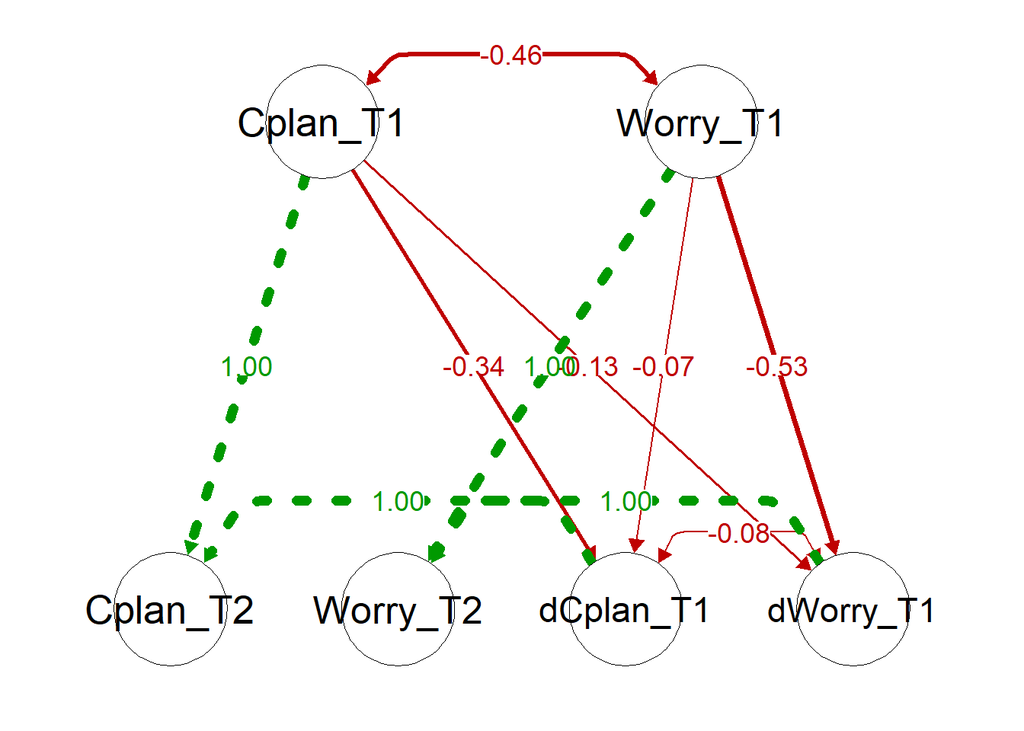

```r
semPaths(fit_BLCS_Cplan_worry, what = "est", layout = "tree", intercepts = FALSE, residuals = FALSE, structural = TRUE, sizeMan = 4, sizeLat = 12, nCharNodes = 0, node.label.cex = 1.6, edge.label.cex = 1.3, fixedStyle = c("grey",3), curvePivot = TRUE, fade = FALSE,  label.prop = 1.5)
```

```r
BLCS_Cplan_byworryfix<-'
Cplan_t1=~1*t1cpl_1+t1cpl_2+t1cpl_3+t1cpl_4+t1cpl_5+t1cpl_6            # this specifies the measurement model for Cplan_t1
Cplan_t2=~1*t2cpl_1+equal("Cplan_t1=~t1cpl_2")*t2cpl_2+equal("Cplan_t1=~t1cpl_3")*t2cpl_3
+equal("Cplan_t1=~t1cpl_4")*t2cpl_4+equal("Cplan_t1=~t1cpl_5")*t2cpl_5
+equal("Cplan_t1=~t1cpl_6")*t2cpl_6

t1cpl_1~~t2cpl_1   # this allows residual covariance on indicator 1 across t1 and t2
t1cpl_2~~t2cpl_2
t1cpl_3~~t2cpl_3
t1cpl_4~~t2cpl_4
t1cpl_5~~t2cpl_5
t1cpl_6~~t2cpl_6

t1cpl_1~~t1cpl_1   # this allows residual variance on indicator 1 at t1
t1cpl_2~~t1cpl_2
t1cpl_3~~t1cpl_3
t1cpl_4~~t1cpl_4
t1cpl_5~~t1cpl_5
t1cpl_6~~t1cpl_6

t2cpl_1~~t2cpl_1   # this allows residual variance on indicator 1 at t2
t2cpl_2~~t2cpl_2
t2cpl_3~~t2cpl_3
t2cpl_4~~t2cpl_4
t2cpl_5~~t2cpl_5
t2cpl_6~~t2cpl_6

t1cpl_1~0*1   # this constrains the intercept of ind 1 to 0 at t1
t1cpl_2~1
t1cpl_3~1
t1cpl_4~1
t1cpl_5~1
t1cpl_6~1


t2cpl_1~0*1    # this constrains the intercept of ind 1 to 0 at t2
t2cpl_2~equal("t1cpl_2~1")*1
t2cpl_3~equal("t1cpl_3~1")*1
t2cpl_4~equal("t1cpl_4~1")*1
t2cpl_5~equal("t1cpl_5~1")*1
t2cpl_6~equal("t1cpl_6~1")*1

Worry_t1=~1*t1wor_1+t1wor_2+t1wor_3+t1wor_4           # this specifies the measurement model for WORRY
Worry_t2=~1*t2wor_1+equal("Worry_t1=~t1wor_2")*t2wor_2+equal("Worry_t1=~t1wor_3")*t2wor_3+equal("Worry_t2=~t1wor_4")*t2wor_4


t1wor_1~~t2wor_1   # this allows residual covariance on indicator 1 across t1 and t2
t1wor_2~~t2wor_2
t1wor_3~~t2wor_3
t1wor_4~~t2wor_4

t1wor_1~~t1wor_1   # this allows residual variance on indicator 1 at t1
t1wor_2~~t1wor_2
t1wor_3~~t1wor_3
t1wor_4~~t1wor_4

t2wor_1~~t2wor_1   # this allows residual variance on indicator 1 at t1
t2wor_2~~t2wor_2
t2wor_3~~t2wor_3
t2wor_4~~t2wor_4

t1wor_1~0*1    # this constrains the intercept of ind 1 to 0 at t1
t1wor_2~1
t1wor_3~1
t1wor_4~1

t2wor_1~0*1       # this constrains the intercept of ind 1 to 0 at t2
t2wor_2~equal("t1wor_2~1")*1
t2wor_3~equal("t1wor_3~1")*1
t2wor_4~equal("t1wor_4~1")*1


Cplan_t2 ~ 1*Cplan_t1     # Fixed regression of Cplan_t2 on Cplan_t1
dCplan_t1 =~ 1*Cplan_t2     # Fixed regression of dCplan_t1 on Cplan_t2
dCplan_t1 ~ 1             # this estimates the intercept of the change score
Cplan_t1 ~  1           # this estimates the intercept of Cplan_t1
Cplan_t2 ~ 0*1          # this line constrains the intercept of Cplan_t2 to 0


Worry_t2 ~ 1*Worry_t1     # Fixed regression of Worry_t2 on Worry_t1
dWorry_t1 =~ 1*Worry_t2     # Fixed regression of dWorry_t1 on Worry_t2
Worry_t2 ~ 0*1
Worry_t2 ~~ 0*Worry_t2


dCplan_t1 ~~  dCplan_t1       # this estimates the variance of the change scores
Cplan_t1 ~~   Cplan_t1    # this estimates the variance of the Cplan_t1
Cplan_t2 ~~   0*Cplan_t2    # this estimates the variance of the Cplan_t1

dWorry_t1 ~ 1
Worry_t1 ~ 1
dWorry_t1 ~~ dWorry_t1
Worry_t1 ~~ Worry_t1


#dCplan_t1~Cplan_t1+Worry_t1 # this estimates the Cplan to Worry
# coupling parameter and the Worry to Worry self-feedback

dWorry_t1~Worry_t1+Cplan_t1
dCplan_t1~0*Worry_t1+Cplan_t1

Cplan_t1 ~~ Worry_t1
dCplan_t1 ~~ dWorry_t1
'
fitBLCS_Cplan_byworryfix <- lavaan(BLCS_Cplan_byworryfix, data=my_dat, estimator='mlr',fixed.x=FALSE,missing='fiml')
summary(fitBLCS_Cplan_byworryfix, fit.measures=TRUE, standardized=TRUE, rsquare=TRUE)
```

```
## lavaan 0.6-5 ended normally after 88 iterations
##
##   Estimator                                         ML
##   Optimization method                           NLMINB
##   Number of free parameters                         75
##   Number of equality constraints                    15
##   Row rank of the constraints matrix                15
##
##                                                   Used       Total
##   Number of observations                           299         300
##   Number of missing patterns                         3
##
## Model Test User Model:
##                                               Standard      Robust
##   Test Statistic                               346.136     308.459
##   Degrees of freedom                               170         170
##   P-value (Chi-square)                           0.000       0.000
##   Scaling correction factor                                  1.122
##     for the Yuan-Bentler correction (Mplus variant)
##
## Model Test Baseline Model:
##
##   Test statistic                              3564.628    2969.246
##   Degrees of freedom                               190         190
##   P-value                                        0.000       0.000
##   Scaling correction factor                                  1.201
##
## User Model versus Baseline Model:
##
##   Comparative Fit Index (CFI)                    0.948       0.950
##   Tucker-Lewis Index (TLI)                       0.942       0.944
##
##   Robust Comparative Fit Index (CFI)                         0.953
##   Robust Tucker-Lewis Index (TLI)                            0.948
##
## Loglikelihood and Information Criteria:
##
##   Loglikelihood user model (H0)              -6254.892   -6254.892
##   Scaling correction factor                                  0.899
##       for the MLR correction
```

[output cut: 169 more lines]

```
##     t2cpl_4           0.517
##     t2cpl_5           0.709
##     t2cpl_6           0.325
##     t1wor_1           0.683
##     t1wor_2           0.687
##     t1wor_3           0.421
##     t1wor_4           0.675
##     t2wor_1           0.629
##     t2wor_2           0.561
##     t2wor_3           0.325
##     t2wor_4           0.675
##     Worry_t2          1.000
##     dCplan_t1         0.181
##     Cplan_t2          1.000
##     dWorry_t1         0.371
```

```r
fitBLCS_Cplan_byworryfix_meas <- generate_cfa_fitmeasures(fitBLCS_Cplan_byworryfix)
```

```
## # A tibble: 1 x 10
##   Chi_Sq  df      p     CFI   TLI   AIC       BIC       RMSEA RMSEA.CI    SRMR
##   <chr>   <chr>   <chr> <chr> <chr> <chr>     <chr>     <chr> <glue>      <chr>
## 1 346.136 170.000 0.000 0.948 0.942 12629.783 12851.810 0.059 0.050-0.068 0.053
```

```r
for (i in seq_along(fitBLCS_Cplan_byworryfix_meas)) {
    if (is.numeric(i)) {
      round(i, 3)
    }
}

parameterEstimates(fitBLCS_Cplan_byworryfix)
```

```
##          lhs op       rhs             label    est    se      z pvalue ci.lower
## 1   Cplan_t1 =~   t1cpl_1                    1.000 0.000     NA     NA    1.000
## 2   Cplan_t1 =~   t1cpl_2              .p2.  0.903 0.035 25.926  0.000    0.835
## 3   Cplan_t1 =~   t1cpl_3              .p3.  0.861 0.040 21.671  0.000    0.783
## 4   Cplan_t1 =~   t1cpl_4              .p4.  0.791 0.046 17.057  0.000    0.700
## 5   Cplan_t1 =~   t1cpl_5              .p5.  0.959 0.035 27.486  0.000    0.891
## 6   Cplan_t1 =~   t1cpl_6              .p6.  0.686 0.050 13.617  0.000    0.587
## 7   Cplan_t2 =~   t2cpl_1                    1.000 0.000     NA     NA    1.000
## 8   Cplan_t2 =~   t2cpl_2 Cplan_t1=~t1cpl_2  0.903 0.035 25.926  0.000    0.835
## 9   Cplan_t2 =~   t2cpl_3 Cplan_t1=~t1cpl_3  0.861 0.040 21.671  0.000    0.783
## 10  Cplan_t2 =~   t2cpl_4 Cplan_t1=~t1cpl_4  0.791 0.046 17.057  0.000    0.700
## 11  Cplan_t2 =~   t2cpl_5 Cplan_t1=~t1cpl_5  0.959 0.035 27.486  0.000    0.891
## 12  Cplan_t2 =~   t2cpl_6 Cplan_t1=~t1cpl_6  0.686 0.050 13.617  0.000    0.587
## 13   t1cpl_1 ~~   t2cpl_1                    0.133 0.037  3.620  0.000    0.061
## 14   t1cpl_2 ~~   t2cpl_2                    0.025 0.033  0.769  0.442   -0.039
```

[output cut: 171 more lines]

```r
paras_BLCS_Cplan_byworryfix<- parameterEstimates(fitBLCS_Cplan_byworryfix)[c(87,90,88,89), ]

paras_BLCS_Cplan_byworryfix$label <- NULL
paras_BLCS_Cplan_byworryfix
```

```
##          lhs op      rhs    est    se      z pvalue ci.lower ci.upper
## 87 dWorry_t1  ~ Worry_t1 -0.537 0.070 -7.657  0.000   -0.674   -0.399
## 90 dCplan_t1  ~ Cplan_t1 -0.315 0.050 -6.300  0.000   -0.412   -0.217
## 88 dWorry_t1  ~ Cplan_t1 -0.137 0.052 -2.646  0.008   -0.238   -0.035
## 89 dCplan_t1  ~ Worry_t1  0.000 0.000     NA     NA    0.000    0.000
```

```r
rownames(paras_BLCS_Cplan_byworryfix) <- NULL
```

```r
free_fixed_cplan_worry <- rbind(fit_BLCS_Cplan_worry_meas, fitBLCS_Cplan_byworryfix_meas)
free_fixed_cplan_worry
```

```
## # A tibble: 2 x 10
##   Chi_Sq  df      p     CFI   TLI   AIC       BIC       RMSEA RMSEA.CI    SRMR
##   <chr>   <chr>   <chr> <chr> <chr> <chr>     <chr>     <chr> <glue>      <chr>
## 1 345.416 169.000 0.000 0.948 0.941 12631.064 12856.791 0.059 0.050-0.068 0.052
## 2 346.136 170.000 0.000 0.948 0.942 12629.783 12851.810 0.059 0.050-0.068 0.053
```

```r
# anova
aov_cpl_free_fixed = anova(fitBLCS_Cplan_byworryfix, fit_BLCS_Cplan_worry)
aov_cpl_free_fixed
```

```
## Scaled Chi-Squared Difference Test (method = "satorra.bentler.2001")
##
## lavaan NOTE:
##     The "Chisq" column contains standard test statistics, not the
##     robust test that should be reported per model. A robust difference
##     test is a function of two standard (not robust) statistics.
##
##                           Df   AIC   BIC  Chisq Chisq diff Df diff Pr(>Chisq)
## fit_BLCS_Cplan_worry     169 12631 12857 345.42
## fitBLCS_Cplan_byworryfix 170 12630 12852 346.14    0.60661       1     0.4361
```

```r
aov_cpl_free_fixed[, 7][2]
```

```
## [1] 0.4360681
```

```r
aov_cpl_free_fixed[, 7][2] <- format.pval(aov_cpl_free_fixed[ , 7][2], eps = .001, digits = 3)
aov_cpl_free_fixed[, 7][1] <- "-"
options(knitr.kable.NA = '-')
row.names(aov_cpl_free_fixed)[1:2] = c("Free coupling effects", "Coupling effect of worry constrained to zero")
```

```r
kable(aov_cpl_free_fixed, col.names = c("Df", "Chisq", "AIC", "BIC", "Chisq diff", "Df diff", "p"), escape=FALSE,format = "html", booktabs = TRUE, digits = 2,
caption = 'Model comparison BLCSM Career planning - worry: Coupling effect of worry free vs. constrained to zero') %>%
  kable_styling(position = 'left', full_width = F)
```

Model comparison BLCSM Career planning - worry: Coupling effect of worry free vs. constrained to zero

Df

Chisq

AIC

BIC

Chisq diff

Df diff

p

Free coupling effects

169

12631.06

12856.79

345.42

Coupling effect of worry constrained to zero

170

12629.78

12851.81

346.14

0.61

1

0.436

```r
BLCS_worry_bycplfixed<-'
Cplan_t1=~1*t1cpl_1+t1cpl_2+t1cpl_3+t1cpl_4+t1cpl_5+t1cpl_6            # this specifies the measurement model for Cplan_t1
Cplan_t2=~1*t2cpl_1+equal("Cplan_t1=~t1cpl_2")*t2cpl_2+equal("Cplan_t1=~t1cpl_3")*t2cpl_3
+equal("Cplan_t1=~t1cpl_4")*t2cpl_4+equal("Cplan_t1=~t1cpl_5")*t2cpl_5
+equal("Cplan_t1=~t1cpl_6")*t2cpl_6

t1cpl_1~~t2cpl_1   # this allows residual covariance on indicator 1 across T1 and T2
t1cpl_2~~t2cpl_2
t1cpl_3~~t2cpl_3
t1cpl_4~~t2cpl_4
t1cpl_5~~t2cpl_5
t1cpl_6~~t2cpl_6

t1cpl_1~~t1cpl_1   # This allows residual variance on indicator 1 at T1
t1cpl_2~~t1cpl_2
t1cpl_3~~t1cpl_3
t1cpl_4~~t1cpl_4
t1cpl_5~~t1cpl_5
t1cpl_6~~t1cpl_6

t2cpl_1~~t2cpl_1   # This allows residual variance on indicator 1 at T2
t2cpl_2~~t2cpl_2
t2cpl_3~~t2cpl_3
t2cpl_4~~t2cpl_4
t2cpl_5~~t2cpl_5
t2cpl_6~~t2cpl_6

t1cpl_1~0*1   # This constrains the intercept of ind 1 to 0 at T1
t1cpl_2~1
t1cpl_3~1
t1cpl_4~1
t1cpl_5~1
t1cpl_6~1


t2cpl_1~0*1    # This constrains the intercept of ind 1 to 0 at T2
t2cpl_2~equal("t1cpl_2~1")*1
t2cpl_3~equal("t1cpl_3~1")*1
t2cpl_4~equal("t1cpl_4~1")*1
t2cpl_5~equal("t1cpl_5~1")*1
t2cpl_6~equal("t1cpl_6~1")*1

Worry_t1=~1*t1wor_1+t1wor_2+t1wor_3+t1wor_4           # this specifies the measurement model for WORRY
Worry_t2=~1*t2wor_1+equal("Worry_t1=~t1wor_2")*t2wor_2+equal("Worry_t1=~t1wor_3")*t2wor_3+equal("Worry_t2=~t1wor_4")*t2wor_4


t1wor_1~~t2wor_1   # this allows residual covariance on indicator 1 across t1 and t2
t1wor_2~~t2wor_2
t1wor_3~~t2wor_3
t1wor_4~~t2wor_4

t1wor_1~~t1wor_1   # this allows residual variance on indicator 1 at t1
t1wor_2~~t1wor_2
t1wor_3~~t1wor_3
t1wor_4~~t1wor_4

t2wor_1~~t2wor_1   # this allows residual variance on indicator 1 at t1
t2wor_2~~t2wor_2
t2wor_3~~t2wor_3
t2wor_4~~t2wor_4

t1wor_1~0*1    # this constrains the intercept of ind 1 to 0 at t1
t1wor_2~1
t1wor_3~1
t1wor_4~1

t2wor_1~0*1       # this constrains the intercept of ind 1 to 0 at t2
t2wor_2~equal("t1wor_2~1")*1
t2wor_3~equal("t1wor_3~1")*1
t2wor_4~equal("t1wor_4~1")*1


Cplan_t2 ~ 1*Cplan_t1     # Fixed regression of Cplan_t2 on Cplan_t1
dCplan_t1 =~ 1*Cplan_t2     # Fixed regression of dCplan_t1 on Cplan_t2
dCplan_t1 ~ 1             # this estimates the intercept of the change score
Cplan_t1 ~  1           # this estimates the intercept of Cplan_t1
Cplan_t2 ~ 0*1          # this line constrains the intercept of Cplan_t2 to 0


Worry_t2 ~ 1*Worry_t1     # Fixed regression of Worry_t2 on Worry_t1
dWorry_t1 =~ 1*Worry_t2     # Fixed regression of dWorry_t1 on Worry_t2
Worry_t2 ~ 0*1
Worry_t2 ~~ 0*Worry_t2


dCplan_t1 ~~  dCplan_t1       # this estimates the variance of the change scores
Cplan_t1 ~~   Cplan_t1    # this estimates the variance of the Cplan_t1
Cplan_t2 ~~   0*Cplan_t2    # this estimates the variance of the Cplan_t1

dWorry_t1 ~ 1
Worry_t1 ~ 1
dWorry_t1 ~~ dWorry_t1
Worry_t1 ~~ Worry_t1


#dCplan_t1~Cplan_t1+Worry_t1 # this estimates the Cplan to Worry
# coupling parameter and the Worry to Worry self-feedback

dWorry_t1~Worry_t1+0*Cplan_t1
dCplan_t1~Worry_t1+Cplan_t1

Cplan_t1 ~~ Worry_t1
dCplan_t1 ~~ dWorry_t1

'
fitBLCS_worry_bycplfixed <- lavaan(BLCS_worry_bycplfixed, data=my_dat, estimator='mlr',fixed.x=FALSE,missing='fiml')
summary(fitBLCS_worry_bycplfixed, fit.measures=TRUE, standardized=TRUE, rsquare=TRUE)
```

```
## lavaan 0.6-5 ended normally after 85 iterations
##
##   Estimator                                         ML
##   Optimization method                           NLMINB
##   Number of free parameters                         75
##   Number of equality constraints                    15
##   Row rank of the constraints matrix                15
##
##                                                   Used       Total
##   Number of observations                           299         300
##   Number of missing patterns                         3
##
## Model Test User Model:
##                                               Standard      Robust
##   Test Statistic                               353.146     314.758
##   Degrees of freedom                               170         170
##   P-value (Chi-square)                           0.000       0.000
##   Scaling correction factor                                  1.122
##     for the Yuan-Bentler correction (Mplus variant)
##
## Model Test Baseline Model:
##
##   Test statistic                              3564.628    2969.246
##   Degrees of freedom                               190         190
##   P-value                                        0.000       0.000
##   Scaling correction factor                                  1.201
##
## User Model versus Baseline Model:
##
##   Comparative Fit Index (CFI)                    0.946       0.948
##   Tucker-Lewis Index (TLI)                       0.939       0.942
##
##   Robust Comparative Fit Index (CFI)                         0.951
##   Robust Tucker-Lewis Index (TLI)                            0.946
##
## Loglikelihood and Information Criteria:
##
##   Loglikelihood user model (H0)              -6258.397   -6258.397
##   Scaling correction factor                                  0.899
##       for the MLR correction
```

[output cut: 169 more lines]

```
##     t2cpl_4           0.511
##     t2cpl_5           0.705
##     t2cpl_6           0.319
##     t1wor_1           0.683
##     t1wor_2           0.682
##     t1wor_3           0.420
##     t1wor_4           0.675
##     t2wor_1           0.632
##     t2wor_2           0.562
##     t2wor_3           0.329
##     t2wor_4           0.683
##     Worry_t2          1.000
##     dCplan_t1         0.207
##     Cplan_t2          1.000
##     dWorry_t1         0.320
```

```r
# anova
aov_cpl_free_fixed = anova(fitBLCS_worry_bycplfixed, fit_BLCS_Cplan_worry)
aov_cpl_free_fixed
```

```
## Scaled Chi-Squared Difference Test (method = "satorra.bentler.2001")
##
## lavaan NOTE:
##     The "Chisq" column contains standard test statistics, not the
##     robust test that should be reported per model. A robust difference
##     test is a function of two standard (not robust) statistics.
##
##                           Df   AIC   BIC  Chisq Chisq diff Df diff Pr(>Chisq)
## fit_BLCS_Cplan_worry     169 12631 12857 345.42
## fitBLCS_worry_bycplfixed 170 12637 12859 353.15     6.6951       1   0.009668
##
## fit_BLCS_Cplan_worry
## fitBLCS_worry_bycplfixed **
## ---
## Signif. codes:  0 '***' 0.001 '**' 0.01 '*' 0.05 '.' 0.1 ' ' 1
```

```r
aov_cpl_free_fixed[, 7][2]
```

```
## [1] 0.009667801
```

```r
aov_cpl_free_fixed[, 7][2] <- format.pval(aov_cpl_free_fixed[ , 7][2], eps = .001, digits = 3)
aov_cpl_free_fixed[, 7][1] <- "-"
options(knitr.kable.NA = '-')
row.names(aov_cpl_free_fixed)[1:2] = c("Free coupling effects", "Coupling effect of career planning constrained to zero")
```

```r
kable(aov_cpl_free_fixed, col.names = c("Df", "Chisq", "AIC", "BIC", "Chisq diff", "Df diff", "p"), escape=FALSE,format = "html", booktabs = TRUE, digits = 2,
caption = 'Model comparison BLCSM Career planning - worry: Coupling effect of career planning free vs. constrained to zero') %>%
  kable_styling(position = 'left', full_width = F)
```

Model comparison BLCSM Career planning - worry: Coupling effect of career planning free vs. constrained to zero

Df

Chisq

AIC

BIC

Chisq diff

Df diff

p

Free coupling effects

169

12631.06

12856.79

345.42

Coupling effect of career planning constrained to zero

170

12636.79

12858.82

353.15

6.7

1

### 10.1.1 BLCSM Subscales Career Planning - Worry

```r
BLCS_Cplan_worry_1<-'
Cplan_T1=~1*t1cpl_1+t1cpl_5+t1cpl_6  # This specifies the measurement model for Cplan_T1
Cplan_T2=~1*t2cpl_1+equal("Cplan_T1=~t1cpl_5")*t2cpl_5+equal("Cplan_T1=~t1cpl_6")*t2cpl_6

t1cpl_1~~t2cpl_1   # This allows residual covariance on indicator 1 across T1 and T2
t1cpl_5~~t2cpl_5
t1cpl_6~~t2cpl_6

t1cpl_1~~t1cpl_1   # This allows residual variance on indicator 1 at T1
t1cpl_5~~t1cpl_5
t1cpl_6~~t1cpl_6

t2cpl_1~~t2cpl_1   # This allows residual variance on indicator 1 at T2
t2cpl_5~~t2cpl_5
t2cpl_6~~t2cpl_6

t1cpl_1~0*1   # This constrains the intercept of ind 1 to 0 at T1
t1cpl_5~1
t1cpl_6~1


t2cpl_1~0*1    # This constrains the intercept of ind 1 to 0 at T2
t2cpl_5~equal("t1cpl_5~1")*1
t2cpl_6~equal("t1cpl_6~1")*1

Worry_T1=~1*t1wor_1+t1wor_2+t1wor_3+t1wor_4           # This specifies the measurement model for WORRY
Worry_T2=~1*t2wor_1+equal("Worry_T1=~t1wor_2")*t2wor_2+equal("Worry_T1=~t1wor_3")*t2wor_3+equal("Worry_T2=~t1wor_4")*t2wor_4


t1wor_1~~t2wor_1   # This allows residual covariance on indicator 1 across T1 and T2
t1wor_2~~t2wor_2
t1wor_3~~t2wor_3
t1wor_4~~t2wor_4

t1wor_1~~t1wor_1   # This allows residual variance on indicator 1 at T1
t1wor_2~~t1wor_2
t1wor_3~~t1wor_3
t1wor_4~~t1wor_4

t2wor_1~~t2wor_1   # This allows residual variance on indicator 1 at T1
t2wor_2~~t2wor_2
t2wor_3~~t2wor_3
t2wor_4~~t2wor_4

t1wor_1~0*1    # This constrains the intercept of ind 1 to 0 at T1
t1wor_2~1
t1wor_3~1
t1wor_4~1

t2wor_1~0*1       # This constrains the intercept of ind 1 to 0 at T2
t2wor_2~equal("t1wor_2~1")*1
t2wor_3~equal("t1wor_3~1")*1
t2wor_4~equal("t1wor_4~1")*1


Cplan_T2 ~ 1*Cplan_T1     # Fixed regression of Cplan_T2 on Cplan_T1
dCplan_T1 =~ 1*Cplan_T2     # Fixed regression of dCplan_T1 on Cplan_T2
dCplan_T1 ~ 1             # This estimates the intercept of the change score
Cplan_T1 ~  1           # This estimates the intercept of Cplan_T1
Cplan_T2 ~ 0*1          # This line constrains the intercept of Cplan_T2 to 0


Worry_T2 ~ 1*Worry_T1     # Fixed regression of Worry_T2 on Worry_T1
dWorry_T1 =~ 1*Worry_T2     # Fixed regression of dWorry_T1 on Worry_T2
dWorry_T1 ~ 1
Worry_T1 ~ 1
Worry_T2 ~ 0*1

Worry_T2 ~~ 0*Worry_T2
Cplan_T2 ~~   0*Cplan_T2    # This fixes the variance of the Cplan_T2

dCplan_T1 ~~  dCplan_T1       # This estimates the variance of the change scores
dWorry_T1 ~~ dWorry_T1

Cplan_T1 ~~   Cplan_T1    # This estimates the variance of the Cplan_T1
Worry_T1 ~~ Worry_T1


#This estimates the Cplan to Worry
# coupling parameter and the Worry to Worry self-feedback

dWorry_T1~Worry_T1+Cplan_T1
dCplan_T1~0*Worry_T1+Cplan_T1

Cplan_T1 ~~ Worry_T1
dCplan_T1 ~~ dWorry_T1

'
fit_BLCS_Cplan_worry_1 <- lavaan(BLCS_Cplan_worry_1, data=my_dat, estimator='mlr',fixed.x=FALSE,missing='fiml')
summary(fit_BLCS_Cplan_worry_1, fit.measures=TRUE, standardized=TRUE, rsquare=TRUE)
```

```
## lavaan 0.6-5 ended normally after 70 iterations
##
##   Estimator                                         ML
##   Optimization method                           NLMINB
##   Number of free parameters                         54
##   Number of equality constraints                     9
##   Row rank of the constraints matrix                 9
##
##                                                   Used       Total
##   Number of observations                           299         300
##   Number of missing patterns                         3
##
## Model Test User Model:
##                                               Standard      Robust
##   Test Statistic                               105.303      98.599
##   Degrees of freedom                                74          74
##   P-value (Chi-square)                           0.010       0.030
##   Scaling correction factor                                  1.068
##     for the Yuan-Bentler correction (Mplus variant)
##
## Model Test Baseline Model:
##
##   Test statistic                              1976.485    1680.203
##   Degrees of freedom                                91          91
##   P-value                                        0.000       0.000
##   Scaling correction factor                                  1.176
##
## User Model versus Baseline Model:
##
##   Comparative Fit Index (CFI)                    0.983       0.985
##   Tucker-Lewis Index (TLI)                       0.980       0.981
##
##   Robust Comparative Fit Index (CFI)                         0.986
##   Robust Tucker-Lewis Index (TLI)                            0.983
##
## Loglikelihood and Information Criteria:
##
##   Loglikelihood user model (H0)              -4569.323   -4569.323
##   Scaling correction factor                                  0.896
##       for the MLR correction
```

[output cut: 139 more lines]

```
##     t2cpl_1           0.793
##     t2cpl_5           0.728
##     t2cpl_6           0.360
##     t1wor_1           0.686
##     t1wor_2           0.685
##     t1wor_3           0.420
##     t1wor_4           0.675
##     t2wor_1           0.632
##     t2wor_2           0.560
##     t2wor_3           0.325
##     t2wor_4           0.675
##     Worry_T2          1.000
##     Cplan_T2          1.000
##     dCplan_T1         0.221
##     dWorry_T1         0.356
```

```r
parameterEstimates(fit_BLCS_Cplan_worry_1)
```

```
##          lhs op       rhs             label    est    se      z pvalue ci.lower
## 1   Cplan_T1 =~   t1cpl_1                    1.000 0.000     NA     NA    1.000
## 2   Cplan_T1 =~   t1cpl_5              .p2.  0.947 0.052 18.373  0.000    0.846
## 3   Cplan_T1 =~   t1cpl_6              .p3.  0.686 0.058 11.780  0.000    0.572
## 4   Cplan_T2 =~   t2cpl_1                    1.000 0.000     NA     NA    1.000
## 5   Cplan_T2 =~   t2cpl_5 Cplan_T1=~t1cpl_5  0.947 0.052 18.373  0.000    0.846
## 6   Cplan_T2 =~   t2cpl_6 Cplan_T1=~t1cpl_6  0.686 0.058 11.780  0.000    0.572
## 7    t1cpl_1 ~~   t2cpl_1                    0.073 0.058  1.265  0.206   -0.040
## 8    t1cpl_5 ~~   t2cpl_5                    0.080 0.047  1.699  0.089   -0.012
## 9    t1cpl_6 ~~   t2cpl_6                    0.403 0.081  4.990  0.000    0.245
## 10   t1cpl_1 ~~   t1cpl_1                    0.402 0.074  5.445  0.000    0.257
## 11   t1cpl_5 ~~   t1cpl_5                    0.379 0.082  4.609  0.000    0.218
## 12   t1cpl_6 ~~   t1cpl_6                    0.888 0.083 10.644  0.000    0.724
## 13   t2cpl_1 ~~   t2cpl_1                    0.300 0.078  3.853  0.000    0.147
## 14   t2cpl_5 ~~   t2cpl_5                    0.385 0.083  4.635  0.000    0.222
```

[output cut: 129 more lines]

```r
paras_BLCS_Cplan_byworryfix_1<- parameterEstimates(fit_BLCS_Cplan_worry_1)[c(66,69,67,68), ]

paras_BLCS_Cplan_byworryfix_1$label <- NULL
paras_BLCS_Cplan_byworryfix_1
```

```
##          lhs op      rhs    est    se      z pvalue ci.lower ci.upper
## 66 dWorry_T1  ~ Worry_T1 -0.518 0.072 -7.206  0.000   -0.658   -0.377
## 69 dCplan_T1  ~ Cplan_T1 -0.395 0.060 -6.590  0.000   -0.512   -0.277
## 67 dWorry_T1  ~ Cplan_T1 -0.105 0.050 -2.096  0.036   -0.204   -0.007
## 68 dCplan_T1  ~ Worry_T1  0.000 0.000     NA     NA    0.000    0.000
```

```r
rownames(paras_BLCS_Cplan_byworryfix_1) <- NULL
```

```r
BLCS_Cplan_worry_2<-'
Cplan_T1=~1*t1cpl_2+t1cpl_3+t1cpl_4  # This specifies the measurement model for Cplan_T1
Cplan_T2=~1*t2cpl_2+equal("Cplan_T1=~t1cpl_3")*t2cpl_3+equal("Cplan_T1=~t1cpl_4")*t2cpl_4

t1cpl_2~~t2cpl_2   # This allows residual covariance on indicator 1 across T1 and T2
t1cpl_3~~t2cpl_3
t1cpl_4~~t2cpl_4

t1cpl_2~~t1cpl_2   # This allows residual variance on indicator 1 at T1
t1cpl_3~~t1cpl_3
t1cpl_4~~t1cpl_4

t2cpl_2~~t2cpl_2   # This allows residual variance on indicator 1 at T2
t2cpl_3~~t2cpl_3
t2cpl_4~~t2cpl_4

t1cpl_2~0*1   # This constrains the intercept of ind 1 to 0 at T1
t1cpl_3~1
t1cpl_4~1


t2cpl_2~0*1    # This constrains the intercept of ind 1 to 0 at T2
t2cpl_3~equal("t1cpl_3~1")*1
t2cpl_4~equal("t1cpl_4~1")*1

Worry_T1=~1*t1wor_1+t1wor_2+t1wor_3+t1wor_4           # This specifies the measurement model for WORRY
Worry_T2=~1*t2wor_1+equal("Worry_T1=~t1wor_2")*t2wor_2+equal("Worry_T1=~t1wor_3")*t2wor_3+equal("Worry_T2=~t1wor_4")*t2wor_4


t1wor_1~~t2wor_1   # This allows residual covariance on indicator 1 across T1 and T2
t1wor_2~~t2wor_2
t1wor_3~~t2wor_3
t1wor_4~~t2wor_4

t1wor_1~~t1wor_1   # This allows residual variance on indicator 1 at T1
t1wor_2~~t1wor_2
t1wor_3~~t1wor_3
t1wor_4~~t1wor_4

t2wor_1~~t2wor_1   # This allows residual variance on indicator 1 at T1
t2wor_2~~t2wor_2
t2wor_3~~t2wor_3
t2wor_4~~t2wor_4

t1wor_1~0*1    # This constrains the intercept of ind 1 to 0 at T1
t1wor_2~1
t1wor_3~1
t1wor_4~1

t2wor_1~0*1       # This constrains the intercept of ind 1 to 0 at T2
t2wor_2~equal("t1wor_2~1")*1
t2wor_3~equal("t1wor_3~1")*1
t2wor_4~equal("t1wor_4~1")*1


Cplan_T2 ~ 1*Cplan_T1     # Fixed regression of Cplan_T2 on Cplan_T1
dCplan_T1 =~ 1*Cplan_T2     # Fixed regression of dCplan_T1 on Cplan_T2
dCplan_T1 ~ 1             # This estimates the intercept of the change score
Cplan_T1 ~  1           # This estimates the intercept of Cplan_T1
Cplan_T2 ~ 0*1          # This line constrains the intercept of Cplan_T2 to 0


Worry_T2 ~ 1*Worry_T1     # Fixed regression of Worry_T2 on Worry_T1
dWorry_T1 =~ 1*Worry_T2     # Fixed regression of dWorry_T1 on Worry_T2
Worry_T2 ~ 0*1
Worry_T2 ~~ 0*Worry_T2


dCplan_T1 ~~  dCplan_T1       # This estimates the variance of the change scores
Cplan_T1 ~~   Cplan_T1    # This estimates the variance of the Cplan_T1
Cplan_T2 ~~   0*Cplan_T2    # This estimates the variance of the Cplan_T1

dWorry_T1 ~ 1
Worry_T1 ~ 1
dWorry_T1 ~~ dWorry_T1
Worry_T1 ~~ Worry_T1


#This estimates the Cplan to Worry
# coupling parameter and the Worry to Worry self-feedback

dWorry_T1~Worry_T1+Cplan_T1
dCplan_T1~0*Worry_T1+Cplan_T1

Cplan_T1 ~~ Worry_T1
dCplan_T1 ~~ dWorry_T1

'

fit_BLCS_Cplan_worry_2 <- lavaan(BLCS_Cplan_worry_2, data=my_dat, estimator='mlr',fixed.x=FALSE,missing='fiml')
summary(fit_BLCS_Cplan_worry_2, fit.measures=TRUE, standardized=TRUE, rsquare=TRUE)
```

```
## lavaan 0.6-5 ended normally after 74 iterations
##
##   Estimator                                         ML
##   Optimization method                           NLMINB
##   Number of free parameters                         54
##   Number of equality constraints                     9
##   Row rank of the constraints matrix                 9
##
##                                                   Used       Total
##   Number of observations                           299         300
##   Number of missing patterns                         3
##
## Model Test User Model:
##                                               Standard      Robust
##   Test Statistic                               134.160     117.705
##   Degrees of freedom                                74          74
##   P-value (Chi-square)                           0.000       0.001
##   Scaling correction factor                                  1.140
##     for the Yuan-Bentler correction (Mplus variant)
##
## Model Test Baseline Model:
##
##   Test statistic                              2177.262    1754.753
##   Degrees of freedom                                91          91
##   P-value                                        0.000       0.000
##   Scaling correction factor                                  1.241
##
## User Model versus Baseline Model:
##
##   Comparative Fit Index (CFI)                    0.971       0.974
##   Tucker-Lewis Index (TLI)                       0.965       0.968
##
##   Robust Comparative Fit Index (CFI)                         0.976
##   Robust Tucker-Lewis Index (TLI)                            0.970
##
## Loglikelihood and Information Criteria:
##
##   Loglikelihood user model (H0)              -4317.346   -4317.346
##   Scaling correction factor                                  0.927
##       for the MLR correction
```

[output cut: 139 more lines]

```
##     t2cpl_2           0.660
##     t2cpl_3           0.792
##     t2cpl_4           0.564
##     t1wor_1           0.675
##     t1wor_2           0.691
##     t1wor_3           0.419
##     t1wor_4           0.680
##     t2wor_1           0.622
##     t2wor_2           0.560
##     t2wor_3           0.325
##     t2wor_4           0.681
##     Worry_T2          1.000
##     dCplan_T1         0.139
##     Cplan_T2          1.000
##     dWorry_T1         0.374
```

```r
parameterEstimates(fit_BLCS_Cplan_worry_2)
```

```
##          lhs op       rhs             label    est    se      z pvalue ci.lower
## 1   Cplan_T1 =~   t1cpl_2                    1.000 0.000     NA     NA    1.000
## 2   Cplan_T1 =~   t1cpl_3              .p2.  1.098 0.047 23.581  0.000    1.006
## 3   Cplan_T1 =~   t1cpl_4              .p3.  0.964 0.057 16.907  0.000    0.852
## 4   Cplan_T2 =~   t2cpl_2                    1.000 0.000     NA     NA    1.000
## 5   Cplan_T2 =~   t2cpl_3 Cplan_T1=~t1cpl_3  1.098 0.047 23.581  0.000    1.006
## 6   Cplan_T2 =~   t2cpl_4 Cplan_T1=~t1cpl_4  0.964 0.057 16.907  0.000    0.852
## 7    t1cpl_2 ~~   t2cpl_2                    0.063 0.044  1.429  0.153   -0.024
## 8    t1cpl_3 ~~   t2cpl_3                   -0.046 0.032 -1.434  0.152   -0.108
## 9    t1cpl_4 ~~   t2cpl_4                    0.046 0.059  0.786  0.432   -0.069
## 10   t1cpl_2 ~~   t1cpl_2                    0.420 0.052  8.050  0.000    0.318
## 11   t1cpl_3 ~~   t1cpl_3                    0.174 0.042  4.123  0.000    0.091
## 12   t1cpl_4 ~~   t1cpl_4                    0.427 0.056  7.596  0.000    0.317
## 13   t2cpl_2 ~~   t2cpl_2                    0.401 0.055  7.344  0.000    0.294
## 14   t2cpl_3 ~~   t2cpl_3                    0.247 0.050  4.966  0.000    0.149
```

[output cut: 129 more lines]

```r
paras_BLCS_Cplan_byworryfix_2<- parameterEstimates(fit_BLCS_Cplan_worry_2)[c(66,69,67,68), ]

paras_BLCS_Cplan_byworryfix_2$label <- NULL
paras_BLCS_Cplan_byworryfix_2
```

```
##          lhs op      rhs    est    se      z pvalue ci.lower ci.upper
## 66 dWorry_T1  ~ Worry_T1 -0.537 0.068 -7.851  0.000   -0.671   -0.403
## 69 dCplan_T1  ~ Cplan_T1 -0.250 0.055 -4.531  0.000   -0.358   -0.142
## 67 dWorry_T1  ~ Cplan_T1 -0.163 0.060 -2.701  0.007   -0.281   -0.045
## 68 dCplan_T1  ~ Worry_T1  0.000 0.000     NA     NA    0.000    0.000
```

```r
rownames(paras_BLCS_Cplan_byworryfix_2) <- NULL

compar <- rbind(paras_BLCS_Cplan_byworryfix, paras_BLCS_Cplan_byworryfix_1, paras_BLCS_Cplan_byworryfix_2)[-c(4,8,12), ]
rownames(compar) <- NULL
compar[, 7] <- format.pval(compar[ , 7], eps = .001, digits = 3)
```

```r
kableExtra::kable(compar, booktabs = TRUE, format = 'html', digits = 3, escape = FALSE, caption = "Parameter estimates of a bivariate latent change score model for career planning and worry") %>%
  kable_styling(position = 'left', full_width = F) %>%
  pack_rows("All items", 1, 3) %>%
  pack_rows("Items 1, 5, 6 (Decidedness)", 4, 6) %>%
  pack_rows("Items 2, 3, 4 (Strategy)", 7, 9) %>%
  row_spec(c(3,6,9), bold = T, color = "white", background = "#D7261E")
```

Parameter estimates of a bivariate latent change score model for career planning and worry

| lhs | op | rhs | est | se | z | pvalue | ci.lower | ci.upper |
| --- | --- | --- | --- | --- | --- | --- | --- | --- |
| **All items** |  |  |  |  |  |  |  |  |
| dWorry_t1 | ~ | Worry_t1 | -0.537 | 0.070 | -7.657 | <0.001 | -0.674 | -0.399 |
| dCplan_t1 | ~ | Cplan_t1 | -0.315 | 0.050 | -6.300 | <0.001 | -0.412 | -0.217 |
| dWorry_t1 | ~ | Cplan_t1 | -0.137 | 0.052 | -2.646 | 0.008 | -0.238 | -0.035 |
| **Items 1, 5, 6 (Decidedness)** |  |  |  |  |  |  |  |  |
| dWorry_T1 | ~ | Worry_T1 | -0.518 | 0.072 | -7.206 | <0.001 | -0.658 | -0.377 |
| dCplan_T1 | ~ | Cplan_T1 | -0.395 | 0.060 | -6.590 | <0.001 | -0.512 | -0.277 |
| dWorry_T1 | ~ | Cplan_T1 | -0.105 | 0.050 | -2.096 | 0.036 | -0.204 | -0.007 |
| **Items 2, 3, 4 (Strategy)** |  |  |  |  |  |  |  |  |
| dWorry_T1 | ~ | Worry_T1 | -0.537 | 0.068 | -7.851 | <0.001 | -0.671 | -0.403 |
| dCplan_T1 | ~ | Cplan_T1 | -0.250 | 0.055 | -4.531 | <0.001 | -0.358 | -0.142 |
| dWorry_T1 | ~ | Cplan_T1 | -0.163 | 0.060 | -2.701 | 0.007 | -0.281 | -0.045 |

## 10.2 BLCSM Career Planning - Self-efficacy

```r
names(my_dat)
```

```
##   [1] "durationt1"  "t1id"        "t1grad_new"  "t1date"      "t1date_diff"
##   [6] "t1pa_1"      "t1pa_2"      "t1pa_3"      "t1pa_4"      "t1pa_5"
##  [11] "t1pa_6"      "t1pa_7"      "t1pa_8"      "t1pa_9"      "t1pa_10"
##  [16] "t1na_1"      "t1na_2"      "t1na_3"      "t1na_4"      "t1na_5"
##  [21] "t1na_6"      "t1na_7_fa_2" "t1na_8"      "t1na_9"      "t1na_10"
##  [26] "t1fa_1"      "t1fa_3"      "t1pp_1"      "t1pp_2"      "t1pp_3"
##  [31] "t1pp_4"      "t1pp_5"      "t1pp_7"      "t1pp_8"      "t1pp_9"
##  [36] "t1pp_10"     "t1pp_11"     "t1se_1"      "t1se_2"      "t1se_3"
##  [41] "t1se_4"      "t1se_5"      "t1se_6"      "t1se_7"      "t1se_8"
##  [46] "t1ogoal_1"   "t1ogoal_2"   "t1ogoal_3"   "t1ogoal_4"   "t1ogoal_5"
##  [51] "t1ogoal_6"   "t1ogoal_7"   "t1ogoal_9"   "t1ogoal_10"  "t1ogoal_11"
##  [56] "t1tfpa_1"    "t1tfpa_2"    "t1tfpa_3"    "t1tfpa_4"    "t1tfpr_1"
##  [61] "t1tfpr_2"    "t1tfpr_3"    "t1tfpr_4"    "t1tffu_1"    "t1tffu_2"
##  [66] "t1tffu_3"    "t1tffu_4"    "t1cpl_1"     "t1cpl_2"     "t1cpl_3"
##  [71] "t1cpl_4"     "t1cpl_5"     "t1cpl_6"     "t1eff"       "t1search_1"
```

[output cut: 58 more lines]

```r
BLCS_se_cpl<-'
SE_T1=~1*t1se_1+t1se_2+t1se_3+t1se_4+t1se_5+t1se_6+t1se_7+t1se_8  # This specifies the measurement model for SE_T1
SE_T2=~1*t2se_1+equal("SE_T1=~t1se_2")*t2se_2+equal("SE_T1=~t1se_3")*t2se_3
+equal("SE_T1=~t1se_4")*t2se_4+equal("SE_T1=~t1se_5")*t2se_5+equal("SE_T1=~t1se_6")*t2se_6+equal("SE_T1=~t1se_7")*t2se_7+equal("SE_T1=~t1se_8")*t2se_8


t1se_1~~t2se_1   # This allows residual covariance on indicator 1 across T1 and T2
t1se_2~~t2se_2
t1se_3~~t2se_3
t1se_4~~t2se_4
t1se_5~~t2se_5
t1se_6~~t2se_6
t1se_7~~t2se_7
t1se_8~~t2se_8

t1se_1~~t1se_1   # This allows residual variance on indicator 1 at T1
t1se_2~~t1se_2
t1se_3~~t1se_3
t1se_4~~t1se_4
t1se_5~~t1se_5
t1se_6~~t1se_6
t1se_7~~t1se_7
t1se_8~~t1se_8

t2se_1~~t2se_1   # This allows residual variance on indicator 1 at T2
t2se_2~~t2se_2
t2se_3~~t2se_3
t2se_4~~t2se_4
t2se_5~~t2se_5
t2se_6~~t2se_6
t2se_7~~t2se_7
t2se_8~~t2se_8

t1se_1~0*1   # This constrains the intercept of ind 1 to 0 at T1
t1se_2~1
t1se_3~1
t1se_4~1
t1se_5~1
t1se_6~1
t1se_7~1
t1se_8~1

t2se_1~0*1    # This constrains the intercept of ind 1 to 0 at T2
t2se_2~equal("t1se_2~1")*1
t2se_3~equal("t1se_3~1")*1
t2se_4~equal("t1se_4~1")*1
t2se_5~equal("t1se_5~1")*1
t2se_6~equal("t1se_6~1")*1
t2se_7~equal("t1se_7~1")*1
t2se_8~equal("t1se_8~1")*1


Cplan_T1=~1*t1cpl_1+t1cpl_2+t1cpl_3+t1cpl_4+t1cpl_5+t1cpl_6      # This specifies the measurement model
Cplan_T2=~1*t2cpl_1+equal("Cplan_T1=~t1cpl_2")*t2cpl_2+equal("Cplan_T1=~t1cpl_3")*t2cpl_3+equal("Cplan_T2=~t1cpl_4")*t2cpl_4+equal("Cplan_T2=~t1cpl_5")*t2cpl_5+equal("Cplan_T2=~t1cpl_6")*t2cpl_6


t1cpl_1~~t2cpl_1   # This allows residual covariance on indicator 1 across T1 and T2
t1cpl_2~~t2cpl_2
t1cpl_3~~t2cpl_3
t1cpl_4~~t2cpl_4
t1cpl_5~~t2cpl_5
t1cpl_6~~t2cpl_6

t1cpl_1~~t1cpl_1   # This allows residual variance on indicator 1 at T1
t1cpl_2~~t1cpl_2
t1cpl_3~~t1cpl_3
t1cpl_4~~t1cpl_4
t1cpl_5~~t1cpl_5
t1cpl_6~~t1cpl_6


t2cpl_1~~t2cpl_1   # This allows residual variance on indicator 1 at T1
t2cpl_2~~t2cpl_2
t2cpl_3~~t2cpl_3
t2cpl_4~~t2cpl_4
t2cpl_5~~t2cpl_5
t2cpl_6~~t2cpl_6


t1cpl_1~0*1    # This constrains the intercept of ind 1 to 0 at T1
t1cpl_2~1
t1cpl_3~1
t1cpl_4~1
t1cpl_5~1
t1cpl_6~1


t2cpl_1~0*1       # This constrains the intercept of ind 1 to 0 at T2
t2cpl_2~equal("t1cpl_2~1")*1
t2cpl_3~equal("t1cpl_3~1")*1
t2cpl_4~equal("t1cpl_4~1")*1
t2cpl_5~equal("t1cpl_5~1")*1
t2cpl_6~equal("t1cpl_6~1")*1



SE_T2 ~ 1*SE_T1     # Fixed regression of SE_T2 on SE_T1
dSE_T1 =~ 1*SE_T2   # Fixed regression of dSE_T1 on SE_T2
dSE_T1 ~ 1             # This estimates the intercept of the change score
SE_T1 ~  1             # This estimates the intercept of SE_T1
SE_T2 ~ 0*1            # This line constrains the intercept of SE_T2 to 0


Cplan_T2 ~ 1*Cplan_T1     # Fixed regression of Cplan_T2 on Cplan_T1
dCplan_T1 =~ 1*Cplan_T2   # Fixed regression of dCplan_T1 on Cplan_T2
Cplan_T2 ~ 0*1
Cplan_T2 ~~ 0*Cplan_T2


dSE_T1 ~~  dSE_T1   # This estimates the variance of the change scores
SE_T1 ~~   SE_T1    # This estimates the variance of the SE_T1
SE_T2 ~~   0*SE_T2  # This estimates the variance of the SE_T1

dCplan_T1 ~ 1
Cplan_T1 ~ 1
dCplan_T1 ~~ dCplan_T1
Cplan_T1 ~~ Cplan_T1


# This estimates the coupling

dCplan_T1~Cplan_T1+SE_T1
dSE_T1~Cplan_T1+SE_T1

SE_T1 ~~ Cplan_T1
dSE_T1 ~~ dCplan_T1
'


fit_BLCS_se_cpl <- lavaan(BLCS_se_cpl, data=my_dat, estimator='mlr',fixed.x=FALSE,missing='fiml')
summary(fit_BLCS_se_cpl, fit.measures=TRUE, standardized=TRUE, rsquare=TRUE)
```

```
## lavaan 0.6-5 ended normally after 136 iterations
##
##   Estimator                                         ML
##   Optimization method                           NLMINB
##   Number of free parameters                        104
##   Number of equality constraints                    21
##   Row rank of the constraints matrix                21
##
##   Number of observations                           300
##   Number of missing patterns                         4
##
## Model Test User Model:
##                                               Standard      Robust
##   Test Statistic                               737.106     637.133
##   Degrees of freedom                               351         351
##   P-value (Chi-square)                           0.000       0.000
##   Scaling correction factor                                  1.157
##     for the Yuan-Bentler correction (Mplus variant)
##
## Model Test Baseline Model:
##
##   Test statistic                              4839.097    4058.556
##   Degrees of freedom                               378         378
##   P-value                                        0.000       0.000
##   Scaling correction factor                                  1.192
##
## User Model versus Baseline Model:
##
##   Comparative Fit Index (CFI)                    0.913       0.922
##   Tucker-Lewis Index (TLI)                       0.907       0.916
##
##   Robust Comparative Fit Index (CFI)                         0.925
##   Robust Tucker-Lewis Index (TLI)                            0.919
##
## Loglikelihood and Information Criteria:
##
##   Loglikelihood user model (H0)              -8064.443   -8064.443
##   Scaling correction factor                                  1.004
##       for the MLR correction
##   Loglikelihood unrestricted model (H1)             NA          NA
```

[output cut: 208 more lines]

```
##     t1cpl_2           0.756
##     t1cpl_3           0.724
##     t1cpl_4           0.609
##     t1cpl_5           0.694
##     t1cpl_6           0.355
##     t2cpl_1           0.678
##     t2cpl_2           0.722
##     t2cpl_3           0.677
##     t2cpl_4           0.543
##     t2cpl_5           0.706
##     t2cpl_6           0.338
##     Cplan_T2          1.000
##     dSE_T1            0.168
##     SE_T2             1.000
##     dCplan_T1         0.197
```

```r
parameterEstimates(fit_BLCS_se_cpl)
```

```
##           lhs op       rhs             label    est    se      z pvalue
## 1       SE_T1 =~    t1se_1                    1.000 0.000     NA     NA
## 2       SE_T1 =~    t1se_2              .p2.  1.148 0.073 15.748  0.000
## 3       SE_T1 =~    t1se_3              .p3.  1.025 0.067 15.348  0.000
## 4       SE_T1 =~    t1se_4              .p4.  1.155 0.075 15.383  0.000
## 5       SE_T1 =~    t1se_5              .p5.  1.103 0.090 12.253  0.000
## 6       SE_T1 =~    t1se_6              .p6.  1.019 0.090 11.331  0.000
## 7       SE_T1 =~    t1se_7              .p7.  0.942 0.122  7.702  0.000
## 8       SE_T1 =~    t1se_8              .p8.  0.893 0.096  9.342  0.000
## 9       SE_T2 =~    t2se_1                    1.000 0.000     NA     NA
## 10      SE_T2 =~    t2se_2     SE_T1=~t1se_2  1.148 0.073 15.748  0.000
## 11      SE_T2 =~    t2se_3     SE_T1=~t1se_3  1.025 0.067 15.348  0.000
## 12      SE_T2 =~    t2se_4     SE_T1=~t1se_4  1.155 0.075 15.383  0.000
## 13      SE_T2 =~    t2se_5     SE_T1=~t1se_5  1.103 0.090 12.253  0.000
## 14      SE_T2 =~    t2se_6     SE_T1=~t1se_6  1.019 0.090 11.331  0.000
```

[output cut: 227 more lines]

```r
paras_BLCS_se_cpl<- parameterEstimates(fit_BLCS_se_cpl)[c(115,118,116,117), ]
paras_BLCS_se_cpl$label <- NULL
paras_BLCS_se_cpl[4] <- round(paras_BLCS_se_cpl[4],3)
paras_BLCS_se_cpl[8] <- round(paras_BLCS_se_cpl[8],3)
paras_BLCS_se_cpl[9] <- round(paras_BLCS_se_cpl[9],3)
rownames(paras_BLCS_se_cpl) <- NULL
paras_BLCS_se_cpl[,7 ] <- format.pval(paras_BLCS_se_cpl[ , 7], eps = .001, digits = 3)
paras_BLCS_se_cpl <- paras_BLCS_se_cpl %>% mutate(Est = glue("{est} 95%CI({ci.lower}, {ci.upper})"))
fit_BLCS_Cplan_worry_meas <- generate_cfa_fitmeasures(fit_BLCS_Cplan_worry)
```

```
## # A tibble: 1 x 10
##   Chi_Sq  df      p     CFI   TLI   AIC       BIC       RMSEA RMSEA.CI    SRMR
##   <chr>   <chr>   <chr> <chr> <chr> <chr>     <chr>     <chr> <glue>      <chr>
## 1 345.416 169.000 0.000 0.948 0.941 12631.064 12856.791 0.059 0.050-0.068 0.052
```

```r
for (i in seq_along(fit_BLCS_Cplan_worry_meas)) {
    if (is.numeric(i)) {
      round(i, 3)
    }
}
paras_BLCS_se_cpl <- paras_BLCS_se_cpl[, c(1:3, 10, 7)]
names(paras_BLCS_se_cpl) <- c("", "", "", "Est", "p")


BLCS_se_cpl_meas <- generate_cfa_fitmeasures(fit_BLCS_se_cpl)
```

```
## # A tibble: 1 x 10
##   Chi_Sq  df      p     CFI   TLI   AIC       BIC       RMSEA RMSEA.CI    SRMR
##   <chr>   <chr>   <chr> <chr> <chr> <chr>     <chr>     <chr> <glue>      <chr>
## 1 737.106 351.000 0.000 0.913 0.907 16294.886 16602.300 0.061 0.054-0.067 0.062
```

```r
for (i in seq_along(BLCS_se_cpl_meas)) {
    if (is.numeric(i)) {
      round(i, 3)
    }
}
```

```r
library(kableExtra)
knitr::kable(BLCS_se_cpl_meas, escape=FALSE, digits = 3, format = "html", booktabs = TRUE, caption = "Fit indices of a bivariate latent change score model for career planning and self-efficacy") %>%
  kable_styling(position = 'left', full_width = F)
```

Fit indices of a bivariate latent change score model for career planning and self-efficacy

| Chi_Sq | df | p | CFI | TLI | AIC | BIC | RMSEA | RMSEA.CI | SRMR |
| --- | --- | --- | --- | --- | --- | --- | --- | --- | --- |
| 737.106 | 351.000 | 0.000 | 0.913 | 0.907 | 16294.886 | 16602.300 | 0.061 | 0.054-0.067 | 0.062 |

```r
kableExtra::kable(paras_BLCS_se_cpl, booktabs = TRUE, digits = 3, format = 'html', escape = FALSE, caption = "Parameter estimates of a bivariate latent change score model for career planning and self-efficacy") %>%
  kable_styling(position = 'left', full_width = F) %>%
  pack_rows("Self-feedback", 1, 2) %>%
  pack_rows("Coupling effect", 3, 4) %>%
  row_spec(c(3,4), bold = T, color = "white", background = "#D7261E")
```

Parameter estimates of a bivariate latent change score model for career planning and self-efficacy

|  |  |  | Est | p |
| --- | --- | --- | --- | --- |
| **Self-feedback** |  |  |  |  |
| dCplan_T1 | ~ | Cplan_T1 | -0.342 95%CI(-0.465, -0.219) | <0.001 |
| dSE_T1 | ~ | SE_T1 | -0.371 95%CI(-0.54, -0.202) | <0.001 |
| **Coupling effect** |  |  |  |  |
| dCplan_T1 | ~ | SE_T1 | 0.063 95%CI(-0.145, 0.27) | 0.554 |
| dSE_T1 | ~ | Cplan_T1 | 0.09 95%CI(0.01, 0.17) | 0.027 |

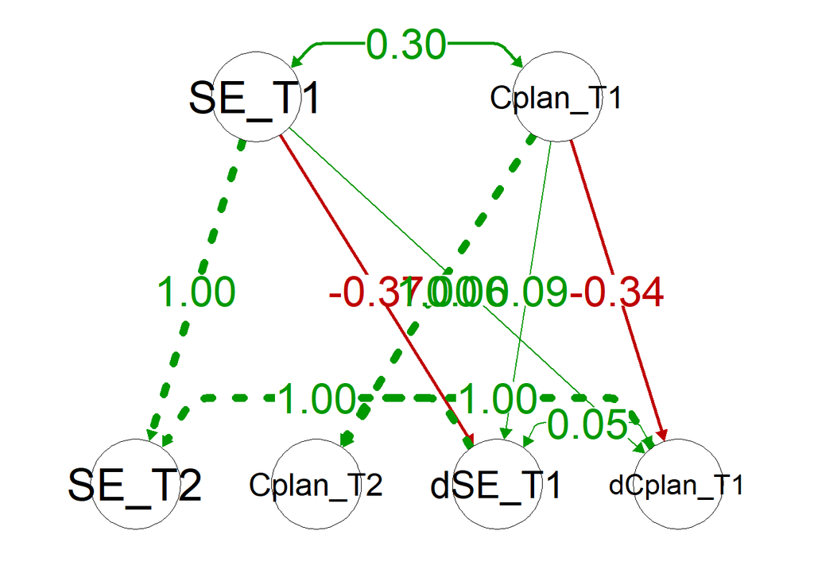

```r
semPaths(fit_BLCS_se_cpl, what = "est", layout = "tree", intercepts = FALSE, residuals = FALSE, structural = TRUE, sizeMan = 4, sizeLat = 12, nCharNodes = 0, node.label.cex = 1.6, edge.label.cex = 2.5, fixedStyle = c("grey",3), curvePivot = TRUE, fade = FALSE, label.prop = 1.5)
```

```r
BLCS_cplan_sefixed<-'
SE_T1=~1*t1se_1+t1se_2+t1se_3+t1se_4+t1se_5+t1se_6+t1se_7+t1se_8  # This specifies the measurement model for SE_T1
SE_T2=~1*t2se_1+equal("SE_T1=~t1se_2")*t2se_2+equal("SE_T1=~t1se_3")*t2se_3
+equal("SE_T1=~t1se_4")*t2se_4+equal("SE_T1=~t1se_5")*t2se_5+equal("SE_T1=~t1se_6")*t2se_6+equal("SE_T1=~t1se_7")*t2se_7+equal("SE_T1=~t1se_8")*t2se_8


t1se_1~~t2se_1   # This allows residual covariance on indicator 1 across T1 and T2
t1se_2~~t2se_2
t1se_3~~t2se_3
t1se_4~~t2se_4
t1se_5~~t2se_5
t1se_6~~t2se_6
t1se_7~~t2se_7
t1se_8~~t2se_8

t1se_1~~t1se_1   # This allows residual variance on indicator 1 at T1
t1se_2~~t1se_2
t1se_3~~t1se_3
t1se_4~~t1se_4
t1se_5~~t1se_5
t1se_6~~t1se_6
t1se_7~~t1se_7
t1se_8~~t1se_8

t2se_1~~t2se_1   # This allows residual variance on indicator 1 at T2
t2se_2~~t2se_2
t2se_3~~t2se_3
t2se_4~~t2se_4
t2se_5~~t2se_5
t2se_6~~t2se_6
t2se_7~~t2se_7
t2se_8~~t2se_8

t1se_1~0*1   # This constrains the intercept of ind 1 to 0 at T1
t1se_2~1
t1se_3~1
t1se_4~1
t1se_5~1
t1se_6~1
t1se_7~1
t1se_8~1

t2se_1~0*1    # This constrains the intercept of ind 1 to 0 at T2
t2se_2~equal("t1se_2~1")*1
t2se_3~equal("t1se_3~1")*1
t2se_4~equal("t1se_4~1")*1
t2se_5~equal("t1se_5~1")*1
t2se_6~equal("t1se_6~1")*1
t2se_7~equal("t1se_7~1")*1
t2se_8~equal("t1se_8~1")*1


Cplan_T1=~1*t1cpl_1+t1cpl_2+t1cpl_3+t1cpl_4+t1cpl_5+t1cpl_6      # This specifies the measurement model
Cplan_T2=~1*t2cpl_1+equal("Cplan_T1=~t1cpl_2")*t2cpl_2+equal("Cplan_T1=~t1cpl_3")*t2cpl_3+equal("Cplan_T2=~t1cpl_4")*t2cpl_4+equal("Cplan_T2=~t1cpl_5")*t2cpl_5+equal("Cplan_T2=~t1cpl_6")*t2cpl_6


t1cpl_1~~t2cpl_1   # This allows residual covariance on indicator 1 across T1 and T2
t1cpl_2~~t2cpl_2
t1cpl_3~~t2cpl_3
t1cpl_4~~t2cpl_4
t1cpl_5~~t2cpl_5
t1cpl_6~~t2cpl_6

t1cpl_1~~t1cpl_1   # This allows residual variance on indicator 1 at T1
t1cpl_2~~t1cpl_2
t1cpl_3~~t1cpl_3
t1cpl_4~~t1cpl_4
t1cpl_5~~t1cpl_5
t1cpl_6~~t1cpl_6


t2cpl_1~~t2cpl_1   # This allows residual variance on indicator 1 at T1
t2cpl_2~~t2cpl_2
t2cpl_3~~t2cpl_3
t2cpl_4~~t2cpl_4
t2cpl_5~~t2cpl_5
t2cpl_6~~t2cpl_6


t1cpl_1~0*1    # This constrains the intercept of ind 1 to 0 at T1
t1cpl_2~1
t1cpl_3~1
t1cpl_4~1
t1cpl_5~1
t1cpl_6~1


t2cpl_1~0*1       # This constrains the intercept of ind 1 to 0 at T2
t2cpl_2~equal("t1cpl_2~1")*1
t2cpl_3~equal("t1cpl_3~1")*1
t2cpl_4~equal("t1cpl_4~1")*1
t2cpl_5~equal("t1cpl_5~1")*1
t2cpl_6~equal("t1cpl_6~1")*1


Cplan_T2 ~ 1*Cplan_T1     # Fixed regression of Cplan_T2 on Cplan_T1
dCplan_T1 =~ 1*Cplan_T2     # Fixed regression of dCplan_T1 on Cplan_T2
dCplan_T1 ~ 1             # This estimates the intercept of the change score
Cplan_T1 ~  1           # This estimates the intercept of Cplan_T1
Cplan_T2 ~ 0*1          # This line constrains the intercept of Cplan_T2 to 0


SE_T2 ~ 1*SE_T1     # Fixed regression of SE_T2 on SE_T1
dSE_T1 =~ 1*SE_T2     # Fixed regression of dSE_T1 on SE_T2
SE_T2 ~ 0*1
SE_T2 ~~ 0*SE_T2


dCplan_T1 ~~  dCplan_T1       # This estimates the variance of the change scores
Cplan_T1 ~~   Cplan_T1    # This estimates the variance of the Cplan_T1
Cplan_T2 ~~   0*Cplan_T2    # This estimates the variance of the Cplan_T1

dSE_T1 ~ 1
SE_T1 ~ 1
dSE_T1 ~~ dSE_T1
SE_T1 ~~ SE_T1


#dCplan_T1~Cplan_T1+SE_T1 # This estimates the Cplan to Worry
# coupling parameter and the Worry to Worry self-feedback

dSE_T1~SE_T1+Cplan_T1
dCplan_T1~0*SE_T1+Cplan_T1

Cplan_T1 ~~ SE_T1
dCplan_T1 ~~ dSE_T1

'

fit_BLCS_cplan_sefixed <- lavaan(BLCS_cplan_sefixed, data=my_dat, estimator='mlr',fixed.x=FALSE,missing='fiml')
summary(fit_BLCS_cplan_sefixed, fit.measures=TRUE, standardized=TRUE, rsquare=TRUE)
```

```
## lavaan 0.6-5 ended normally after 141 iterations
##
##   Estimator                                         ML
##   Optimization method                           NLMINB
##   Number of free parameters                        103
##   Number of equality constraints                    21
##   Row rank of the constraints matrix                21
##
##   Number of observations                           300
##   Number of missing patterns                         4
##
## Model Test User Model:
##                                               Standard      Robust
##   Test Statistic                               737.420     637.826
##   Degrees of freedom                               352         352
##   P-value (Chi-square)                           0.000       0.000
##   Scaling correction factor                                  1.156
##     for the Yuan-Bentler correction (Mplus variant)
##
## Model Test Baseline Model:
##
##   Test statistic                              4839.097    4058.556
##   Degrees of freedom                               378         378
##   P-value                                        0.000       0.000
##   Scaling correction factor                                  1.192
##
## User Model versus Baseline Model:
##
##   Comparative Fit Index (CFI)                    0.914       0.922
##   Tucker-Lewis Index (TLI)                       0.907       0.917
##
##   Robust Comparative Fit Index (CFI)                         0.925
##   Robust Tucker-Lewis Index (TLI)                            0.919
##
## Loglikelihood and Information Criteria:
##
##   Loglikelihood user model (H0)              -8064.600   -8064.600
##   Scaling correction factor                                  1.005
##       for the MLR correction
##   Loglikelihood unrestricted model (H1)             NA          NA
```

[output cut: 208 more lines]

```
##     t1cpl_2           0.756
##     t1cpl_3           0.724
##     t1cpl_4           0.609
##     t1cpl_5           0.694
##     t1cpl_6           0.355
##     t2cpl_1           0.679
##     t2cpl_2           0.722
##     t2cpl_3           0.677
##     t2cpl_4           0.543
##     t2cpl_5           0.707
##     t2cpl_6           0.339
##     SE_T2             1.000
##     dCplan_T1         0.194
##     Cplan_T2          1.000
##     dSE_T1            0.172
```

```r
# anova
aov_cpl_free_fixed = anova(fit_BLCS_se_cpl, fit_BLCS_cplan_sefixed)
aov_cpl_free_fixed
```

```
## Scaled Chi-Squared Difference Test (method = "satorra.bentler.2001")
##
## lavaan NOTE:
##     The "Chisq" column contains standard test statistics, not the
##     robust test that should be reported per model. A robust difference
##     test is a function of two standard (not robust) statistics.
##
##                         Df   AIC   BIC  Chisq Chisq diff Df diff Pr(>Chisq)
## fit_BLCS_se_cpl        351 16295 16602 737.11
## fit_BLCS_cplan_sefixed 352 16293 16597 737.42    0.35292       1     0.5525
```

```r
aov_cpl_free_fixed[, 7][1] <- "-"
options(knitr.kable.NA = '-')
row.names(aov_cpl_free_fixed)[1:2] = c("Free coupling effects", "Coupling effect of self-efficacy constrained to zero")
```

```r
kable(aov_cpl_free_fixed, col.names = c("Df", "Chisq", "AIC", "BIC", "Chisq diff", "Df diff", "p"), escape=FALSE,format = "html", booktabs = TRUE, digits = 2,
caption = 'Model comparison BLCSM Career planning - self-efficacy: Coupling effect of self-efficacy free vs. constrained to zero') %>%
  kable_styling(position = 'left', full_width = F)
```

Model comparison BLCSM Career planning - self-efficacy: Coupling effect of self-efficacy free vs. constrained to zero

Df

AIC

BIC

Chisq diff

Df diff

p

Free coupling effects

351

16294.89

16602.30

737.11

Coupling effect of self-efficacy constrained to zero

352

16293.20

16596.91

737.42

0.35

1

0.552465115302149

```r
BLCS_se_cplanfixed<-'
SE_T1=~1*t1se_1+t1se_2+t1se_3+t1se_4+t1se_5+t1se_6+t1se_7+t1se_8  # This specifies the measurement model for SE_T1
SE_T2=~1*t2se_1+equal("SE_T1=~t1se_2")*t2se_2+equal("SE_T1=~t1se_3")*t2se_3
+equal("SE_T1=~t1se_4")*t2se_4+equal("SE_T1=~t1se_5")*t2se_5+equal("SE_T1=~t1se_6")*t2se_6+equal("SE_T1=~t1se_7")*t2se_7+equal("SE_T1=~t1se_8")*t2se_8


t1se_1~~t2se_1   # This allows residual covariance on indicator 1 across T1 and T2
t1se_2~~t2se_2
t1se_3~~t2se_3
t1se_4~~t2se_4
t1se_5~~t2se_5
t1se_6~~t2se_6
t1se_7~~t2se_7
t1se_8~~t2se_8

t1se_1~~t1se_1   # This allows residual variance on indicator 1 at T1
t1se_2~~t1se_2
t1se_3~~t1se_3
t1se_4~~t1se_4
t1se_5~~t1se_5
t1se_6~~t1se_6
t1se_7~~t1se_7
t1se_8~~t1se_8

t2se_1~~t2se_1   # This allows residual variance on indicator 1 at T2
t2se_2~~t2se_2
t2se_3~~t2se_3
t2se_4~~t2se_4
t2se_5~~t2se_5
t2se_6~~t2se_6
t2se_7~~t2se_7
t2se_8~~t2se_8

t1se_1~0*1   # This constrains the intercept of ind 1 to 0 at T1
t1se_2~1
t1se_3~1
t1se_4~1
t1se_5~1
t1se_6~1
t1se_7~1
t1se_8~1

t2se_1~0*1    # This constrains the intercept of ind 1 to 0 at T2
t2se_2~equal("t1se_2~1")*1
t2se_3~equal("t1se_3~1")*1
t2se_4~equal("t1se_4~1")*1
t2se_5~equal("t1se_5~1")*1
t2se_6~equal("t1se_6~1")*1
t2se_7~equal("t1se_7~1")*1
t2se_8~equal("t1se_8~1")*1


Cplan_T1=~1*t1cpl_1+t1cpl_2+t1cpl_3+t1cpl_4+t1cpl_5+t1cpl_6      # This specifies the measurement model
Cplan_T2=~1*t2cpl_1+equal("Cplan_T1=~t1cpl_2")*t2cpl_2+equal("Cplan_T1=~t1cpl_3")*t2cpl_3+equal("Cplan_T2=~t1cpl_4")*t2cpl_4+equal("Cplan_T2=~t1cpl_5")*t2cpl_5+equal("Cplan_T2=~t1cpl_6")*t2cpl_6


t1cpl_1~~t2cpl_1   # This allows residual covariance on indicator 1 across T1 and T2
t1cpl_2~~t2cpl_2
t1cpl_3~~t2cpl_3
t1cpl_4~~t2cpl_4
t1cpl_5~~t2cpl_5
t1cpl_6~~t2cpl_6

t1cpl_1~~t1cpl_1   # This allows residual variance on indicator 1 at T1
t1cpl_2~~t1cpl_2
t1cpl_3~~t1cpl_3
t1cpl_4~~t1cpl_4
t1cpl_5~~t1cpl_5
t1cpl_6~~t1cpl_6


t2cpl_1~~t2cpl_1   # This allows residual variance on indicator 1 at T1
t2cpl_2~~t2cpl_2
t2cpl_3~~t2cpl_3
t2cpl_4~~t2cpl_4
t2cpl_5~~t2cpl_5
t2cpl_6~~t2cpl_6


t1cpl_1~0*1    # This constrains the intercept of ind 1 to 0 at T1
t1cpl_2~1
t1cpl_3~1
t1cpl_4~1
t1cpl_5~1
t1cpl_6~1


t2cpl_1~0*1       # This constrains the intercept of ind 1 to 0 at T2
t2cpl_2~equal("t1cpl_2~1")*1
t2cpl_3~equal("t1cpl_3~1")*1
t2cpl_4~equal("t1cpl_4~1")*1
t2cpl_5~equal("t1cpl_5~1")*1
t2cpl_6~equal("t1cpl_6~1")*1


Cplan_T2 ~ 1*Cplan_T1     # Fixed regression of Cplan_T2 on Cplan_T1
dCplan_T1 =~ 1*Cplan_T2     # Fixed regression of dCplan_T1 on Cplan_T2
dCplan_T1 ~ 1             # This estimates the intercept of the change score
Cplan_T1 ~  1           # This estimates the intercept of Cplan_T1
Cplan_T2 ~ 0*1          # This line constrains the intercept of Cplan_T2 to 0


SE_T2 ~ 1*SE_T1     # Fixed regression of SE_T2 on SE_T1
dSE_T1 =~ 1*SE_T2     # Fixed regression of dSE_T1 on SE_T2
SE_T2 ~ 0*1
SE_T2 ~~ 0*SE_T2


dCplan_T1 ~~  dCplan_T1       # This estimates the variance of the change scores
Cplan_T1 ~~   Cplan_T1    # This estimates the variance of the Cplan_T1
Cplan_T2 ~~   0*Cplan_T2    # This estimates the variance of the Cplan_T1

dSE_T1 ~ 1
SE_T1 ~ 1
dSE_T1 ~~ dSE_T1
SE_T1 ~~ SE_T1


#dCplan_T1~Cplan_T1+SE_T1 # This estimates the Cplan to Worry
# coupling parameter and the Worry to Worry self-feedback

dSE_T1~SE_T1+0*Cplan_T1
dCplan_T1~SE_T1+Cplan_T1

Cplan_T1 ~~ SE_T1
dCplan_T1 ~~ dSE_T1

'

fit_BLCS_se_cplanfixed <- lavaan(BLCS_se_cplanfixed, data=my_dat, estimator='mlr',fixed.x=FALSE,missing='fiml')
summary(fit_BLCS_se_cplanfixed, fit.measures=TRUE, standardized=TRUE, rsquare=TRUE)
```

```
## lavaan 0.6-5 ended normally after 148 iterations
##
##   Estimator                                         ML
##   Optimization method                           NLMINB
##   Number of free parameters                        103
##   Number of equality constraints                    21
##   Row rank of the constraints matrix                21
##
##   Number of observations                           300
##   Number of missing patterns                         4
##
## Model Test User Model:
##                                               Standard      Robust
##   Test Statistic                               743.480     642.777
##   Degrees of freedom                               352         352
##   P-value (Chi-square)                           0.000       0.000
##   Scaling correction factor                                  1.157
##     for the Yuan-Bentler correction (Mplus variant)
##
## Model Test Baseline Model:
##
##   Test statistic                              4839.097    4058.556
##   Degrees of freedom                               378         378
##   P-value                                        0.000       0.000
##   Scaling correction factor                                  1.192
##
## User Model versus Baseline Model:
##
##   Comparative Fit Index (CFI)                    0.912       0.921
##   Tucker-Lewis Index (TLI)                       0.906       0.915
##
##   Robust Comparative Fit Index (CFI)                         0.923
##   Robust Tucker-Lewis Index (TLI)                            0.918
##
## Loglikelihood and Information Criteria:
##
##   Loglikelihood user model (H0)              -8067.630   -8067.630
##   Scaling correction factor                                  1.003
##       for the MLR correction
##   Loglikelihood unrestricted model (H1)             NA          NA
```

[output cut: 208 more lines]

```
##     t1cpl_2           0.757
##     t1cpl_3           0.725
##     t1cpl_4           0.609
##     t1cpl_5           0.694
##     t1cpl_6           0.354
##     t2cpl_1           0.673
##     t2cpl_2           0.717
##     t2cpl_3           0.672
##     t2cpl_4           0.537
##     t2cpl_5           0.702
##     t2cpl_6           0.333
##     SE_T2             1.000
##     dCplan_T1         0.214
##     Cplan_T2          1.000
##     dSE_T1            0.128
```

```r
# anova
aov_cpl_free_fixed = anova(fit_BLCS_se_cpl, fit_BLCS_se_cplanfixed)
options(knitr.kable.NA = '-')
row.names(aov_cpl_free_fixed)[1:2] = c("Free coupling effects", "Coupling effect of career planning constrained to zero")
```

```r
kable(aov_cpl_free_fixed, col.names = c("Df", "Chisq", "AIC", "BIC", "Chisq diff", "Df diff", "p"), escape=FALSE,format = "html", booktabs = TRUE, digits = 3,
caption = 'Model comparison BLCSM Career planning - self-efficacy: Coupling effect of career planning free vs. constrained to zero') %>%
  kable_styling(position = 'left', full_width = F)
```

Model comparison BLCSM Career planning - self-efficacy: Coupling effect of career planning free vs. constrained to zero

Df

AIC

BIC

Chisq diff

Df diff

p

Free coupling effects

351

16294.89

16602.30

737.106

Coupling effect of career planning constrained to zero

352

16299.26

16602.97

743.480

5.948

1

0.015

## 10.3 BLCSM Worry - Self-efficacy

```r
BLCS_se_worry<-'
SE_T1=~1*t1se_1+t1se_2+t1se_3+t1se_4+t1se_5+t1se_6+t1se_7+t1se_8  # This specifies the measurement model for SE_T1
SE_T2=~1*t2se_1+equal("SE_T1=~t1se_2")*t2se_2+equal("SE_T1=~t1se_3")*t2se_3
+equal("SE_T1=~t1se_4")*t2se_4+equal("SE_T1=~t1se_5")*t2se_5+equal("SE_T1=~t1se_6")*t2se_6+equal("SE_T1=~t1se_7")*t2se_7+equal("SE_T1=~t1se_8")*t2se_8


t1se_1~~t2se_1   # This allows residual covariance on indicator 1 across T1 and T2
t1se_2~~t2se_2
t1se_3~~t2se_3
t1se_4~~t2se_4
t1se_5~~t2se_5
t1se_6~~t2se_6
t1se_7~~t2se_7
t1se_8~~t2se_8

t1se_1~~t1se_1   # This allows residual variance on indicator 1 at T1
t1se_2~~t1se_2
t1se_3~~t1se_3
t1se_4~~t1se_4
t1se_5~~t1se_5
t1se_6~~t1se_6
t1se_7~~t1se_7
t1se_8~~t1se_8

t2se_1~~t2se_1   # This allows residual variance on indicator 1 at T2
t2se_2~~t2se_2
t2se_3~~t2se_3
t2se_4~~t2se_4
t2se_5~~t2se_5
t2se_6~~t2se_6
t2se_7~~t2se_7
t2se_8~~t2se_8

t1se_1~0*1   # This constrains the intercept of ind 1 to 0 at T1
t1se_2~1
t1se_3~1
t1se_4~1
t1se_5~1
t1se_6~1
t1se_7~1
t1se_8~1

t2se_1~0*1    # This constrains the intercept of ind 1 to 0 at T2
t2se_2~equal("t1se_2~1")*1
t2se_3~equal("t1se_3~1")*1
t2se_4~equal("t1se_4~1")*1
t2se_5~equal("t1se_5~1")*1
t2se_6~equal("t1se_6~1")*1
t2se_7~equal("t1se_7~1")*1
t2se_8~equal("t1se_8~1")*1


Worry_T1=~1*t1wor_1+t1wor_2+t1wor_3+t1wor_4      # This specifies the measurement model
Worry_T2=~1*t2wor_1+equal("Worry_T1=~t1wor_2")*t2wor_2+equal("Worry_T1=~t1wor_3")*t2wor_3+equal("Worry_T2=~t1wor_4")*t2wor_4


t1wor_1~~t2wor_1   # This allows residual covariance on indicator 1 across T1 and T2
t1wor_2~~t2wor_2
t1wor_3~~t2wor_3
t1wor_4~~t2wor_4

t1wor_1~~t1wor_1   # This allows residual variance on indicator 1 at T1
t1wor_2~~t1wor_2
t1wor_3~~t1wor_3
t1wor_4~~t1wor_4

t2wor_1~~t2wor_1   # This allows residual variance on indicator 1 at T1
t2wor_2~~t2wor_2
t2wor_3~~t2wor_3
t2wor_4~~t2wor_4

t1wor_1~0*1    # This constrains the intercept of ind 1 to 0 at T1
t1wor_2~1
t1wor_3~1
t1wor_4~1

t2wor_1~0*1       # This constrains the intercept of ind 1 to 0 at T2
t2wor_2~equal("t1wor_2~1")*1
t2wor_3~equal("t1wor_3~1")*1
t2wor_4~equal("t1wor_4~1")*1


SE_T2 ~ 1*SE_T1     # Fixed regression of SE_T2 on SE_T1
dSE_T1 =~ 1*SE_T2   # Fixed regression of dSE_T1 on SE_T2
dSE_T1 ~ 1             # This estimates the intercept of the change score
SE_T1 ~  1             # This estimates the intercept of SE_T1
SE_T2 ~ 0*1            # This line constrains the intercept of SE_T2 to 0


Worry_T2 ~ 1*Worry_T1     # Fixed regression of Worry_T2 on Worry_T1
dWorry_T1 =~ 1*Worry_T2   # Fixed regression of dWorry_T1 on Worry_T2
Worry_T2 ~ 0*1
Worry_T2 ~~ 0*Worry_T2


dSE_T1 ~~  dSE_T1   # This estimates the variance of the change scores
SE_T1 ~~   SE_T1    # This estimates the variance of the SE_T1
SE_T2 ~~   0*SE_T2  # This estimates the variance of the SE_T1

dWorry_T1 ~ 1
Worry_T1 ~ 1
dWorry_T1 ~~ dWorry_T1
Worry_T1 ~~ Worry_T1


# This estimates the coupling

dWorry_T1~Worry_T1+SE_T1
dSE_T1~Worry_T1+SE_T1

SE_T1 ~~ Worry_T1
dSE_T1 ~~ dWorry_T1
'

fit_BLCS_se_worry <- lavaan(BLCS_se_worry, data=my_dat, estimator='mlr',fixed.x=FALSE,missing='fiml')
summary(fit_BLCS_se_worry, fit.measures=TRUE, standardized=TRUE, rsquare=TRUE)
```

```
## lavaan 0.6-5 ended normally after 145 iterations
##
##   Estimator                                         ML
##   Optimization method                           NLMINB
##   Number of free parameters                         90
##   Number of equality constraints                    19
##   Row rank of the constraints matrix                19
##
##   Number of observations                           300
##   Number of missing patterns                         3
##
## Model Test User Model:
##                                               Standard      Robust
##   Test Statistic                               483.129     419.615
##   Degrees of freedom                               253         253
##   P-value (Chi-square)                           0.000       0.000
##   Scaling correction factor                                  1.151
##     for the Yuan-Bentler correction (Mplus variant)
##
## Model Test Baseline Model:
##
##   Test statistic                              3487.586    2950.833
##   Degrees of freedom                               276         276
##   P-value                                        0.000       0.000
##   Scaling correction factor                                  1.182
##
## User Model versus Baseline Model:
##
##   Comparative Fit Index (CFI)                    0.928       0.938
##   Tucker-Lewis Index (TLI)                       0.922       0.932
##
##   Robust Comparative Fit Index (CFI)                         0.939
##   Robust Tucker-Lewis Index (TLI)                            0.934
##
## Loglikelihood and Information Criteria:
##
##   Loglikelihood user model (H0)              -6708.418   -6708.418
##   Scaling correction factor                                  0.980
##       for the MLR correction
##   Loglikelihood unrestricted model (H1)             NA          NA
```

[output cut: 188 more lines]

```
##     t2se_6            0.546
##     t2se_7            0.362
##     t2se_8            0.359
##     t1wor_1           0.674
##     t1wor_2           0.695
##     t1wor_3           0.418
##     t1wor_4           0.676
##     t2wor_1           0.632
##     t2wor_2           0.559
##     t2wor_3           0.321
##     t2wor_4           0.680
##     Worry_T2          1.000
##     dSE_T1            0.145
##     SE_T2             1.000
##     dWorry_T1         0.362
```

```r
parameterEstimates(fit_BLCS_se_worry)
```

```
##           lhs op       rhs             label    est    se      z pvalue
## 1       SE_T1 =~    t1se_1                    1.000 0.000     NA     NA
## 2       SE_T1 =~    t1se_2              .p2.  1.145 0.073 15.739  0.000
## 3       SE_T1 =~    t1se_3              .p3.  1.021 0.066 15.405  0.000
## 4       SE_T1 =~    t1se_4              .p4.  1.157 0.075 15.536  0.000
## 5       SE_T1 =~    t1se_5              .p5.  1.110 0.090 12.371  0.000
## 6       SE_T1 =~    t1se_6              .p6.  1.023 0.089 11.460  0.000
## 7       SE_T1 =~    t1se_7              .p7.  0.958 0.122  7.841  0.000
## 8       SE_T1 =~    t1se_8              .p8.  0.900 0.095  9.424  0.000
## 9       SE_T2 =~    t2se_1                    1.000 0.000     NA     NA
## 10      SE_T2 =~    t2se_2     SE_T1=~t1se_2  1.145 0.073 15.739  0.000
## 11      SE_T2 =~    t2se_3     SE_T1=~t1se_3  1.021 0.066 15.405  0.000
## 12      SE_T2 =~    t2se_4     SE_T1=~t1se_4  1.157 0.075 15.536  0.000
## 13      SE_T2 =~    t2se_5     SE_T1=~t1se_5  1.110 0.090 12.371  0.000
## 14      SE_T2 =~    t2se_6     SE_T1=~t1se_6  1.023 0.089 11.460  0.000
```

[output cut: 199 more lines]

```r
paras_BLCS_se_wor<- parameterEstimates(fit_BLCS_se_worry)[c(101,104,102,103), ]
paras_BLCS_se_wor$label <- NULL

paras_BLCS_se_wor[4] <- round(paras_BLCS_se_wor[4],3)
paras_BLCS_se_wor[8] <- round(paras_BLCS_se_wor[8],3)
paras_BLCS_se_wor[9] <- round(paras_BLCS_se_wor[9],3)
rownames(paras_BLCS_se_wor) <- NULL
paras_BLCS_se_wor[,7 ] <- format.pval(paras_BLCS_se_wor[ , 7], eps = .001, digits = 3)
paras_BLCS_se_wor <- paras_BLCS_se_wor %>% mutate(Est = glue("{est} 95%CI({ci.lower}, {ci.upper})"))
fit_BLCS_Cplan_worry_meas <- generate_cfa_fitmeasures(fit_BLCS_Cplan_worry)
```

```
## # A tibble: 1 x 10
##   Chi_Sq  df      p     CFI   TLI   AIC       BIC       RMSEA RMSEA.CI    SRMR
##   <chr>   <chr>   <chr> <chr> <chr> <chr>     <chr>     <chr> <glue>      <chr>
## 1 345.416 169.000 0.000 0.948 0.941 12631.064 12856.791 0.059 0.050-0.068 0.052
```

```r
for (i in seq_along(fit_BLCS_Cplan_worry_meas)) {
    if (is.numeric(i)) {
      round(i, 3)
    }
}
paras_BLCS_se_wor <- paras_BLCS_se_wor[, c(1:3, 10, 7)]
names(paras_BLCS_se_wor) <- c("", "", "", "Est", "p")


BLCS_se_wor_meas <- generate_cfa_fitmeasures(fit_BLCS_se_worry)
```

```
## # A tibble: 1 x 10
##   Chi_Sq  df      p     CFI   TLI   AIC       BIC       RMSEA RMSEA.CI    SRMR
##   <chr>   <chr>   <chr> <chr> <chr> <chr>     <chr>     <chr> <glue>      <chr>
## 1 483.129 253.000 0.000 0.928 0.922 13558.837 13821.805 0.055 0.048-0.062 0.055
```

```r
for (i in seq_along(BLCS_se_wor_meas)) {
    if (is.numeric(i)) {
      round(i, 3)
    }
}
```

```r
library(kableExtra)
knitr::kable(BLCS_se_wor_meas, escape=FALSE, digits = 3, format = "html", booktabs = TRUE, caption = "Fit indices of a bivariate latent change score model for self-efficacy and worry") %>%
  kable_styling(position = 'left', full_width = F)
```

Fit indices of a bivariate latent change score model for self-efficacy and worry

| Chi_Sq | df | p | CFI | TLI | AIC | BIC | RMSEA | RMSEA.CI | SRMR |
| --- | --- | --- | --- | --- | --- | --- | --- | --- | --- |
| 483.129 | 253.000 | 0.000 | 0.928 | 0.922 | 13558.837 | 13821.805 | 0.055 | 0.048-0.062 | 0.055 |

```r
kableExtra::kable(paras_BLCS_se_wor, booktabs = TRUE, digits = 3, format = 'html', escape = FALSE, caption = "Parameter estimates of a bivariate latent change score model for self-efficacy and worry") %>%
  kable_styling(position = 'left', full_width = F) %>%
  pack_rows("Self-feedback", 1, 2) %>%
  pack_rows("Coupling effect", 3, 4) %>%
  row_spec(c(3,4), bold = T, color = "white", background = "#D7261E")
```

Parameter estimates of a bivariate latent change score model for self-efficacy and worry

|  |  |  | Est | p |
| --- | --- | --- | --- | --- |
| **Self-feedback** |  |  |  |  |
| dWorry_T1 | ~ | Worry_T1 | -0.532 95%CI(-0.678, -0.386) | <0.001 |
| dSE_T1 | ~ | SE_T1 | -0.34 95%CI(-0.509, -0.172) | <0.001 |
| **Coupling effect** |  |  |  |  |
| dWorry_T1 | ~ | SE_T1 | -0.237 95%CI(-0.426, -0.048) | 0.014 |
| dSE_T1 | ~ | Worry_T1 | -0.066 95%CI(-0.159, 0.027) | 0.166 |

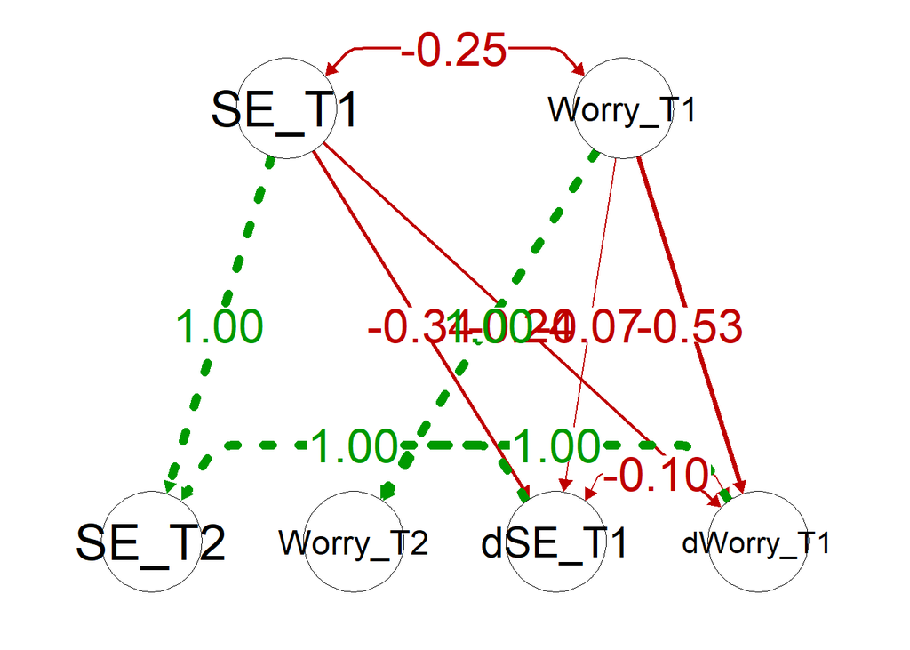

```r
semPaths(fit_BLCS_se_worry, what = "est", layout = "tree", intercepts = FALSE, residuals = FALSE, structural = TRUE, sizeMan = 4, sizeLat = 12, nCharNodes = 0, node.label.cex = 1.6, edge.label.cex = 2.5, fixedStyle = c("grey",3), curvePivot = TRUE, fade = FALSE, label.prop = 1.5)
```

```r
BLCS_se_worryfixed<-'
SE_T1=~1*t1se_1+t1se_2+t1se_3+t1se_4+t1se_5+t1se_6+t1se_7+t1se_8  # This specifies the measurement model for SE_T1
SE_T2=~1*t2se_1+equal("SE_T1=~t1se_2")*t2se_2+equal("SE_T1=~t1se_3")*t2se_3
+equal("SE_T1=~t1se_4")*t2se_4+equal("SE_T1=~t1se_5")*t2se_5+equal("SE_T1=~t1se_6")*t2se_6+equal("SE_T1=~t1se_7")*t2se_7+equal("SE_T1=~t1se_8")*t2se_8


t1se_1~~t2se_1   # This allows residual covariance on indicator 1 across T1 and T2
t1se_2~~t2se_2
t1se_3~~t2se_3
t1se_4~~t2se_4
t1se_5~~t2se_5
t1se_6~~t2se_6
t1se_7~~t2se_7
t1se_8~~t2se_8

t1se_1~~t1se_1   # This allows residual variance on indicator 1 at T1
t1se_2~~t1se_2
t1se_3~~t1se_3
t1se_4~~t1se_4
t1se_5~~t1se_5
t1se_6~~t1se_6
t1se_7~~t1se_7
t1se_8~~t1se_8

t2se_1~~t2se_1   # This allows residual variance on indicator 1 at T2
t2se_2~~t2se_2
t2se_3~~t2se_3
t2se_4~~t2se_4
t2se_5~~t2se_5
t2se_6~~t2se_6
t2se_7~~t2se_7
t2se_8~~t2se_8

t1se_1~0*1   # This constrains the intercept of ind 1 to 0 at T1
t1se_2~1
t1se_3~1
t1se_4~1
t1se_5~1
t1se_6~1
t1se_7~1
t1se_8~1

t2se_1~0*1    # This constrains the intercept of ind 1 to 0 at T2
t2se_2~equal("t1se_2~1")*1
t2se_3~equal("t1se_3~1")*1
t2se_4~equal("t1se_4~1")*1
t2se_5~equal("t1se_5~1")*1
t2se_6~equal("t1se_6~1")*1
t2se_7~equal("t1se_7~1")*1
t2se_8~equal("t1se_8~1")*1


Worry_T1=~1*t1wor_1+t1wor_2+t1wor_3+t1wor_4      # This specifies the measurement model
Worry_T2=~1*t2wor_1+equal("Worry_T1=~t1wor_2")*t2wor_2+equal("Worry_T1=~t1wor_3")*t2wor_3+equal("Worry_T2=~t1wor_4")*t2wor_4


t1wor_1~~t2wor_1   # This allows residual covariance on indicator 1 across T1 and T2
t1wor_2~~t2wor_2
t1wor_3~~t2wor_3
t1wor_4~~t2wor_4

t1wor_1~~t1wor_1   # This allows residual variance on indicator 1 at T1
t1wor_2~~t1wor_2
t1wor_3~~t1wor_3
t1wor_4~~t1wor_4

t2wor_1~~t2wor_1   # This allows residual variance on indicator 1 at T1
t2wor_2~~t2wor_2
t2wor_3~~t2wor_3
t2wor_4~~t2wor_4

t1wor_1~0*1    # This constrains the intercept of ind 1 to 0 at T1
t1wor_2~1
t1wor_3~1
t1wor_4~1

t2wor_1~0*1       # This constrains the intercept of ind 1 to 0 at T2
t2wor_2~equal("t1wor_2~1")*1
t2wor_3~equal("t1wor_3~1")*1
t2wor_4~equal("t1wor_4~1")*1


SE_T2 ~ 1*SE_T1     # Fixed regression of SE_T2 on SE_T1
dSE_T1 =~ 1*SE_T2   # Fixed regression of dSE_T1 on SE_T2
dSE_T1 ~ 1             # This estimates the intercept of the change score
SE_T1 ~  1             # This estimates the intercept of SE_T1
SE_T2 ~ 0*1            # This line constrains the intercept of SE_T2 to 0


Worry_T2 ~ 1*Worry_T1     # Fixed regression of Worry_T2 on Worry_T1
dWorry_T1 =~ 1*Worry_T2   # Fixed regression of dWorry_T1 on Worry_T2
Worry_T2 ~ 0*1
Worry_T2 ~~ 0*Worry_T2


dSE_T1 ~~  dSE_T1   # This estimates the variance of the change scores
SE_T1 ~~   SE_T1    # This estimates the variance of the SE_T1
SE_T2 ~~   0*SE_T2  # This estimates the variance of the SE_T1

dWorry_T1 ~ 1
Worry_T1 ~ 1
dWorry_T1 ~~ dWorry_T1
Worry_T1 ~~ Worry_T1


# This estimates the coupling

dWorry_T1~Worry_T1+SE_T1
dSE_T1~0*Worry_T1+SE_T1

SE_T1 ~~ Worry_T1
dSE_T1 ~~ dWorry_T1
'
fit_BLCS_se_worryfixed <- lavaan(BLCS_se_worryfixed, data=my_dat, estimator='mlr',fixed.x=FALSE,missing='fiml')
summary(fit_BLCS_se_worryfixed, fit.measures=TRUE, standardized=TRUE, rsquare=TRUE)
```

```
## lavaan 0.6-5 ended normally after 150 iterations
##
##   Estimator                                         ML
##   Optimization method                           NLMINB
##   Number of free parameters                         89
##   Number of equality constraints                    19
##   Row rank of the constraints matrix                19
##
##   Number of observations                           300
##   Number of missing patterns                         3
##
## Model Test User Model:
##                                               Standard      Robust
##   Test Statistic                               484.943     421.551
##   Degrees of freedom                               254         254
##   P-value (Chi-square)                           0.000       0.000
##   Scaling correction factor                                  1.150
##     for the Yuan-Bentler correction (Mplus variant)
##
## Model Test Baseline Model:
##
##   Test statistic                              3487.586    2950.833
##   Degrees of freedom                               276         276
##   P-value                                        0.000       0.000
##   Scaling correction factor                                  1.182
##
## User Model versus Baseline Model:
##
##   Comparative Fit Index (CFI)                    0.928       0.937
##   Tucker-Lewis Index (TLI)                       0.922       0.932
##
##   Robust Comparative Fit Index (CFI)                         0.939
##   Robust Tucker-Lewis Index (TLI)                            0.934
##
## Loglikelihood and Information Criteria:
##
##   Loglikelihood user model (H0)              -6709.325   -6709.325
##   Scaling correction factor                                  0.981
##       for the MLR correction
##   Loglikelihood unrestricted model (H1)             NA          NA
```

[output cut: 188 more lines]

```
##     t2se_6            0.546
##     t2se_7            0.362
##     t2se_8            0.358
##     t1wor_1           0.674
##     t1wor_2           0.695
##     t1wor_3           0.417
##     t1wor_4           0.677
##     t2wor_1           0.626
##     t2wor_2           0.553
##     t2wor_3           0.315
##     t2wor_4           0.675
##     Worry_T2          1.000
##     dSE_T1            0.131
##     SE_T2             1.000
##     dWorry_T1         0.385
```

```r
# anova
aov_free_fixed = anova(fit_BLCS_se_worry, fit_BLCS_se_worryfixed)
options(knitr.kable.NA = '-')
row.names(aov_free_fixed)[1:2] = c("Free coupling effects", "Coupling effect of worry constrained to zero")
```

```r
kable(aov_free_fixed, col.names = c("Df", "Chisq", "AIC", "BIC", "Chisq diff", "Df diff", "p"), escape=FALSE,format = "html", booktabs = TRUE, digits = 3,
caption = 'Model comparison BLCSM Self-efficacy - Worry: Coupling effect of Worry free vs. constrained to zero') %>%
  kable_styling(position = 'left', full_width = F)
```

Model comparison BLCSM Self-efficacy - Worry: Coupling effect of Worry free vs. constrained to zero

Df

AIC

BIC

Chisq diff

Df diff

p

Free coupling effects

253

13558.84

13821.81

483.129

Coupling effect of worry constrained to zero

254

13558.65

13817.92

484.943

2.014

1

0.156

```r
BLCS_worry_sefixed<-'
SE_T1=~1*t1se_1+t1se_2+t1se_3+t1se_4+t1se_5+t1se_6+t1se_7+t1se_8  # This specifies the measurement model for SE_T1
SE_T2=~1*t2se_1+equal("SE_T1=~t1se_2")*t2se_2+equal("SE_T1=~t1se_3")*t2se_3
+equal("SE_T1=~t1se_4")*t2se_4+equal("SE_T1=~t1se_5")*t2se_5+equal("SE_T1=~t1se_6")*t2se_6+equal("SE_T1=~t1se_7")*t2se_7+equal("SE_T1=~t1se_8")*t2se_8


t1se_1~~t2se_1   # This allows residual covariance on indicator 1 across T1 and T2
t1se_2~~t2se_2
t1se_3~~t2se_3
t1se_4~~t2se_4
t1se_5~~t2se_5
t1se_6~~t2se_6
t1se_7~~t2se_7
t1se_8~~t2se_8

t1se_1~~t1se_1   # This allows residual variance on indicator 1 at T1
t1se_2~~t1se_2
t1se_3~~t1se_3
t1se_4~~t1se_4
t1se_5~~t1se_5
t1se_6~~t1se_6
t1se_7~~t1se_7
t1se_8~~t1se_8

t2se_1~~t2se_1   # This allows residual variance on indicator 1 at T2
t2se_2~~t2se_2
t2se_3~~t2se_3
t2se_4~~t2se_4
t2se_5~~t2se_5
t2se_6~~t2se_6
t2se_7~~t2se_7
t2se_8~~t2se_8

t1se_1~0*1   # This constrains the intercept of ind 1 to 0 at T1
t1se_2~1
t1se_3~1
t1se_4~1
t1se_5~1
t1se_6~1
t1se_7~1
t1se_8~1

t2se_1~0*1    # This constrains the intercept of ind 1 to 0 at T2
t2se_2~equal("t1se_2~1")*1
t2se_3~equal("t1se_3~1")*1
t2se_4~equal("t1se_4~1")*1
t2se_5~equal("t1se_5~1")*1
t2se_6~equal("t1se_6~1")*1
t2se_7~equal("t1se_7~1")*1
t2se_8~equal("t1se_8~1")*1


Worry_T1=~1*t1wor_1+t1wor_2+t1wor_3+t1wor_4      # This specifies the measurement model
Worry_T2=~1*t2wor_1+equal("Worry_T1=~t1wor_2")*t2wor_2+equal("Worry_T1=~t1wor_3")*t2wor_3+equal("Worry_T2=~t1wor_4")*t2wor_4


t1wor_1~~t2wor_1   # This allows residual covariance on indicator 1 across T1 and T2
t1wor_2~~t2wor_2
t1wor_3~~t2wor_3
t1wor_4~~t2wor_4

t1wor_1~~t1wor_1   # This allows residual variance on indicator 1 at T1
t1wor_2~~t1wor_2
t1wor_3~~t1wor_3
t1wor_4~~t1wor_4

t2wor_1~~t2wor_1   # This allows residual variance on indicator 1 at T1
t2wor_2~~t2wor_2
t2wor_3~~t2wor_3
t2wor_4~~t2wor_4

t1wor_1~0*1    # This constrains the intercept of ind 1 to 0 at T1
t1wor_2~1
t1wor_3~1
t1wor_4~1

t2wor_1~0*1       # This constrains the intercept of ind 1 to 0 at T2
t2wor_2~equal("t1wor_2~1")*1
t2wor_3~equal("t1wor_3~1")*1
t2wor_4~equal("t1wor_4~1")*1


SE_T2 ~ 1*SE_T1     # Fixed regression of SE_T2 on SE_T1
dSE_T1 =~ 1*SE_T2   # Fixed regression of dSE_T1 on SE_T2
dSE_T1 ~ 1             # This estimates the intercept of the change score
SE_T1 ~  1             # This estimates the intercept of SE_T1
SE_T2 ~ 0*1            # This line constrains the intercept of SE_T2 to 0


Worry_T2 ~ 1*Worry_T1     # Fixed regression of Worry_T2 on Worry_T1
dWorry_T1 =~ 1*Worry_T2   # Fixed regression of dWorry_T1 on Worry_T2
Worry_T2 ~ 0*1
Worry_T2 ~~ 0*Worry_T2


dSE_T1 ~~  dSE_T1   # This estimates the variance of the change scores
SE_T1 ~~   SE_T1    # This estimates the variance of the SE_T1
SE_T2 ~~   0*SE_T2  # This estimates the variance of the SE_T1

dWorry_T1 ~ 1
Worry_T1 ~ 1
dWorry_T1 ~~ dWorry_T1
Worry_T1 ~~ Worry_T1


# This estimates the coupling

dWorry_T1~Worry_T1+0*SE_T1
dSE_T1~Worry_T1+SE_T1

SE_T1 ~~ Worry_T1
dSE_T1 ~~ dWorry_T1
'

fit_BLCS_worry_sefixed <- lavaan(BLCS_worry_sefixed, data=my_dat, estimator='mlr',fixed.x=FALSE,missing='fiml')
summary(fit_BLCS_worry_sefixed, fit.measures=TRUE, standardized=TRUE, rsquare=TRUE)
```

```
## lavaan 0.6-5 ended normally after 132 iterations
##
##   Estimator                                         ML
##   Optimization method                           NLMINB
##   Number of free parameters                         89
##   Number of equality constraints                    19
##   Row rank of the constraints matrix                19
##
##   Number of observations                           300
##   Number of missing patterns                         3
##
## Model Test User Model:
##                                               Standard      Robust
##   Test Statistic                               489.542     425.590
##   Degrees of freedom                               254         254
##   P-value (Chi-square)                           0.000       0.000
##   Scaling correction factor                                  1.150
##     for the Yuan-Bentler correction (Mplus variant)
##
## Model Test Baseline Model:
##
##   Test statistic                              3487.586    2950.833
##   Degrees of freedom                               276         276
##   P-value                                        0.000       0.000
##   Scaling correction factor                                  1.182
##
## User Model versus Baseline Model:
##
##   Comparative Fit Index (CFI)                    0.927       0.936
##   Tucker-Lewis Index (TLI)                       0.920       0.930
##
##   Robust Comparative Fit Index (CFI)                         0.938
##   Robust Tucker-Lewis Index (TLI)                            0.932
##
## Loglikelihood and Information Criteria:
##
##   Loglikelihood user model (H0)              -6711.625   -6711.625
##   Scaling correction factor                                  0.981
##       for the MLR correction
##   Loglikelihood unrestricted model (H1)             NA          NA
```

[output cut: 188 more lines]

```
##     t2se_6            0.535
##     t2se_7            0.352
##     t2se_8            0.349
##     t1wor_1           0.674
##     t1wor_2           0.691
##     t1wor_3           0.419
##     t1wor_4           0.674
##     t2wor_1           0.639
##     t2wor_2           0.560
##     t2wor_3           0.324
##     t2wor_4           0.682
##     Worry_T2          1.000
##     dSE_T1            0.186
##     SE_T2             1.000
##     dWorry_T1         0.320
```

```r
# anova
aov_free_fixed = anova(fit_BLCS_se_worry, fit_BLCS_worry_sefixed)
options(knitr.kable.NA = '-')
row.names(aov_free_fixed)[1:2] = c("Free coupling effects", "Coupling effect of self-efficacy constrained to zero")
```

```r
kable(aov_free_fixed, col.names = c("Df", "Chisq", "AIC", "BIC", "Chisq diff", "Df diff", "p"), escape=FALSE,format = "html", booktabs = TRUE, digits = 3,
caption = 'Model comparison BLCSM Self-efficacy - Worry: Coupling effect of Self-efficacy free vs. constrained to zero') %>%
  kable_styling(position = 'left', full_width = F)
```

Model comparison BLCSM Self-efficacy - Worry: Coupling effect of Self-efficacy free vs. constrained to zero

Df

Chisq

AIC

BIC

Chisq diff

Df diff

p

Free coupling effects

253

13558.84

13821.81

483.129

Coupling effect of self-efficacy constrained to zero

254

13563.25

13822.51

489.542

7.345

1

0.007

## 10.4 BLCSM - Multiple groups comparison

### 10.4.1 BLCSM Career Planning - Worry (t2jobfound)

```r
attributes(my_dat$t2job)
```

```
## $label
## [1] "Have you already found a job for the time after your graduation?"
##
## $labels
##                                                         Yes
##                                                           1
##                                                 No, not yet
##                                                           2
## Potentially (e.g., I have a received an informal job offer)
##                                                           3
##                         No, I will not graduate this summer
##                                                           4
##
## $class
## [1] "haven_labelled"
```

```r
mydat_multi <- my_dat %>%
  zap_label(.) %>%
  zap_labels(.) %>%
     mutate_at("t2job", funs(dplyr::recode(., `1` = 2L, `3` = 2L, `2` = 1L, `4` = 1L)))

BLCS_Cplan_worry<-'
Cplan_T1=~1*t1cpl_1+t1cpl_2+t1cpl_3+t1cpl_4+t1cpl_5+t1cpl_6  # This specifies the measurement model for Cplan_T1
Cplan_T2=~1*t2cpl_1+equal("Cplan_T1=~t1cpl_2")*t2cpl_2+equal("Cplan_T1=~t1cpl_3")*t2cpl_3
+equal("Cplan_T1=~t1cpl_4")*t2cpl_4+equal("Cplan_T1=~t1cpl_5")*t2cpl_5
+equal("Cplan_T1=~t1cpl_6")*t2cpl_6

t1cpl_1~~t2cpl_1   # This allows residual covariance on indicator 1 across T1 and T2
t1cpl_2~~t2cpl_2
t1cpl_3~~t2cpl_3
t1cpl_4~~t2cpl_4
t1cpl_5~~t2cpl_5
t1cpl_6~~t2cpl_6

t1cpl_1~~t1cpl_1   # This allows residual variance on indicator 1 at T1
t1cpl_2~~t1cpl_2
t1cpl_3~~t1cpl_3
t1cpl_4~~t1cpl_4
t1cpl_5~~t1cpl_5
t1cpl_6~~t1cpl_6

t2cpl_1~~t2cpl_1   # This allows residual variance on indicator 1 at T2
t2cpl_2~~t2cpl_2
t2cpl_3~~t2cpl_3
t2cpl_4~~t2cpl_4
t2cpl_5~~t2cpl_5
t2cpl_6~~t2cpl_6

t1cpl_1~0*1   # This constrains the intercept of ind 1 to 0 at T1
t1cpl_2~1
t1cpl_3~1
t1cpl_4~1
t1cpl_5~1
t1cpl_6~1


t2cpl_1~0*1    # This constrains the intercept of ind 1 to 0 at T2
t2cpl_2~equal("t1cpl_2~1")*1
t2cpl_3~equal("t1cpl_3~1")*1
t2cpl_4~equal("t1cpl_4~1")*1
t2cpl_5~equal("t1cpl_5~1")*1
t2cpl_6~equal("t1cpl_6~1")*1

Worry_T1=~1*t1wor_1+t1wor_2+t1wor_3+t1wor_4      # This specifies the measurement model
Worry_T2=~1*t2wor_1+equal("Worry_T1=~t1wor_2")*t2wor_2+equal("Worry_T1=~t1wor_3")*t2wor_3+equal("Worry_T2=~t1wor_4")*t2wor_4


t1wor_1~~t2wor_1   # This allows residual covariance on indicator 1 across T1 and T2
t1wor_2~~t2wor_2
t1wor_3~~t2wor_3
t1wor_4~~t2wor_4

t1wor_1~~t1wor_1   # This allows residual variance on indicator 1 at T1
t1wor_2~~t1wor_2
t1wor_3~~t1wor_3
t1wor_4~~t1wor_4

t2wor_1~~t2wor_1   # This allows residual variance on indicator 1 at T1
t2wor_2~~t2wor_2
t2wor_3~~t2wor_3
t2wor_4~~t2wor_4

t1wor_1~0*1    # This constrains the intercept of ind 1 to 0 at T1
t1wor_2~1
t1wor_3~1
t1wor_4~1

t2wor_1~0*1       # This constrains the intercept of ind 1 to 0 at T2
t2wor_2~equal("t1wor_2~1")*1
t2wor_3~equal("t1wor_3~1")*1
t2wor_4~equal("t1wor_4~1")*1


Cplan_T2 ~ 1*Cplan_T1     # Fixed regression of Cplan_T2 on Cplan_T1
dCplan_T1 =~ 1*Cplan_T2   # Fixed regression of dCplan_T1 on Cplan_T2
dCplan_T1 ~ 1             # This estimates the intercept of the change score
Cplan_T1 ~  1             # This estimates the intercept of Cplan_T1
Cplan_T2 ~ 0*1            # This line constrains the intercept of Cplan_T2 to 0


Worry_T2 ~ 1*Worry_T1     # Fixed regression of Worry_T2 on Worry_T1
dWorry_T1 =~ 1*Worry_T2   # Fixed regression of dWorry_T1 on Worry_T2
Worry_T2 ~ 0*1
Worry_T2 ~~ 0*Worry_T2


dCplan_T1 ~~  dCplan_T1   # This estimates the variance of the change scores
Cplan_T1 ~~   Cplan_T1    # This estimates the variance of the Cplan_T1
Cplan_T2 ~~   0*Cplan_T2  # This estimates the variance of the Cplan_T1

dWorry_T1 ~ 1
Worry_T1 ~ 1
dWorry_T1 ~~ dWorry_T1
Worry_T1 ~~ Worry_T1


# This estimates the coupling

dWorry_T1~Worry_T1+Cplan_T1
dCplan_T1~0*Worry_T1+Cplan_T1

Cplan_T1 ~~ Worry_T1
dCplan_T1 ~~ dWorry_T1
'

fit_BLCS_Cplan_worry <- lavaan(BLCS_Cplan_worry, data=mydat_multi, group = "t2job", estimator='mlr',fixed.x=FALSE,missing='fiml')
summary(fit_BLCS_Cplan_worry, fit.measures=TRUE, standardized=TRUE, rsquare=TRUE)
```

```
## lavaan 0.6-5 ended normally after 143 iterations
##
##   Estimator                                         ML
##   Optimization method                           NLMINB
##   Number of free parameters                        150
##   Number of equality constraints                    15
##   Row rank of the constraints matrix                15
##
##   Number of observations per group:
##     2                                               61
##     1                                              160
##   Number of missing patterns per group:
##     2                                                2
##     1                                                2
##
## Model Test User Model:
##                                               Standard      Robust
##   Test Statistic                               525.235     496.107
##   Degrees of freedom                               325         325
##   P-value (Chi-square)                           0.000       0.000
##   Scaling correction factor                                  1.059
##     for the Yuan-Bentler correction (Mplus variant)
##   Test statistic for each group:
##     2                                          225.943     213.413
##     1                                          299.292     282.694
##
## Model Test Baseline Model:
##
##   Test statistic                              3336.015    2971.685
##   Degrees of freedom                               380         380
##   P-value                                        0.000       0.000
##   Scaling correction factor                                  1.123
##
## User Model versus Baseline Model:
##
##   Comparative Fit Index (CFI)                    0.932       0.934
##   Tucker-Lewis Index (TLI)                       0.921       0.923
##
##   Robust Comparative Fit Index (CFI)                         0.938
##   Robust Tucker-Lewis Index (TLI)                            0.927
```

[output cut: 337 more lines]

```
##     t2cpl_4           0.531
##     t2cpl_5           0.713
##     t2cpl_6           0.275
##     t1wor_1           0.705
##     t1wor_2           0.717
##     t1wor_3           0.365
##     t1wor_4           0.683
##     t2wor_1           0.721
##     t2wor_2           0.524
##     t2wor_3           0.285
##     t2wor_4           0.688
##     Worry_T2          1.000
##     dCplan_T1         0.287
##     Cplan_T2          1.000
##     dWorry_T1         0.337
```

```r
parameterEstimates(fit_BLCS_Cplan_worry)
```

```
##           lhs op       rhs block group             label    est    se      z
## 1    Cplan_T1 =~   t1cpl_1     1     1                    1.000 0.000     NA
## 2    Cplan_T1 =~   t1cpl_2     1     1              .p2.  0.836 0.063 13.337
## 3    Cplan_T1 =~   t1cpl_3     1     1              .p3.  0.809 0.070 11.561
## 4    Cplan_T1 =~   t1cpl_4     1     1              .p4.  0.688 0.091  7.543
## 5    Cplan_T1 =~   t1cpl_5     1     1              .p5.  0.966 0.050 19.213
## 6    Cplan_T1 =~   t1cpl_6     1     1              .p6.  0.758 0.084  9.043
## 7    Cplan_T2 =~   t2cpl_1     1     1                    1.000 0.000     NA
## 8    Cplan_T2 =~   t2cpl_2     1     1 Cplan_T1=~t1cpl_2  0.836 0.063 13.337
## 9    Cplan_T2 =~   t2cpl_3     1     1 Cplan_T1=~t1cpl_3  0.809 0.070 11.561
## 10   Cplan_T2 =~   t2cpl_4     1     1 Cplan_T1=~t1cpl_4  0.688 0.091  7.543
## 11   Cplan_T2 =~   t2cpl_5     1     1 Cplan_T1=~t1cpl_5  0.966 0.050 19.213
## 12   Cplan_T2 =~   t2cpl_6     1     1 Cplan_T1=~t1cpl_6  0.758 0.084  9.043
## 13    t1cpl_1 ~~   t2cpl_1     1     1                    0.180 0.079  2.282
## 14    t1cpl_2 ~~   t2cpl_2     1     1                    0.017 0.037  0.463
```

[output cut: 355 more lines]

```r
paras_fit_BLCS_Cplan_worry<- parameterEstimates(fit_BLCS_Cplan_worry)[c(87,90,88, 179, 182, 180), ]
paras_fit_BLCS_Cplan_worry$label <- NULL
paras_fit_BLCS_Cplan_worry$block <- NULL
paras_fit_BLCS_Cplan_worry$group <- NULL
paras_fit_BLCS_Cplan_worry
```

```
##           lhs op      rhs    est    se      z pvalue ci.lower ci.upper
## 87  dWorry_T1  ~ Worry_T1 -0.632 0.163 -3.879  0.000   -0.952   -0.313
## 90  dCplan_T1  ~ Cplan_T1 -0.370 0.099 -3.748  0.000   -0.564   -0.177
## 88  dWorry_T1  ~ Cplan_T1  0.012 0.102  0.116  0.907   -0.188    0.212
## 179 dWorry_T1  ~ Worry_T1 -0.467 0.089 -5.221  0.000   -0.642   -0.292
## 182 dCplan_T1  ~ Cplan_T1 -0.365 0.071 -5.166  0.000   -0.503   -0.227
## 180 dWorry_T1  ~ Cplan_T1 -0.181 0.060 -3.012  0.003   -0.299   -0.063
```

```r
paras_fit_BLCS_Cplan_worry[, 7] <- format.pval(paras_fit_BLCS_Cplan_worry[ , 7], eps = .001, digits = 3)
rownames(paras_fit_BLCS_Cplan_worry) <- NULL

BLCS_Cplan_worry_meas <- generate_cfa_fitmeasures(fit_BLCS_Cplan_worry)
```

```
## # A tibble: 1 x 10
##   Chi_Sq  df      p     CFI   TLI   AIC       BIC       RMSEA RMSEA.CI    SRMR
##   <chr>   <chr>   <chr> <chr> <chr> <chr>     <chr>     <chr> <glue>      <chr>
## 1 525.235 325.000 0.000 0.932 0.921 10703.594 11162.346 0.075 0.063-0.086 0.066
```

```r
for (i in seq_along(BLCS_Cplan_worry_meas)) {
    if (is.numeric(i)) {
      round(i, 3)
    }
}
```

```r
library(kableExtra)
knitr::kable(BLCS_se_wor_meas, escape=FALSE, digits = 3, format = "html", booktabs = TRUE, caption = "Fit indices of a multigroup bivariate latent change score model for career planning and worry (job found at T2") %>%
  kable_styling(position = 'left', full_width = F)
```

[output not shown]

```r
kableExtra::kable(paras_fit_BLCS_Cplan_worry, booktabs = TRUE, digits = 3, format = 'html', escape = FALSE, caption = "Parameter estimates of a multigroup bivariate latent change score model for career planning and worry (job found at T2)") %>%
  kable_styling(position = 'left', full_width = F) %>%
  pack_rows("Group 1: Job found at T2", 1, 3) %>%
  pack_rows("Group 2: No job found at T2", 4, 6) %>%
  row_spec(c(3,6), bold = T, color = "white", background = "#D7261E")
```

Parameter estimates of a multigroup bivariate latent change score model for career planning and worry (job found at T2)

| lhs | op | rhs | est | se | z | pvalue | ci.lower | ci.upper |
| --- | --- | --- | --- | --- | --- | --- | --- | --- |
| **Group 1: Job found at T2** |  |  |  |  |  |  |  |  |
| dWorry_T1 | ~ | Worry_T1 | -0.632 | 0.163 | -3.879 | <0.001 | -0.952 | -0.313 |
| dCplan_T1 | ~ | Cplan_T1 | -0.370 | 0.099 | -3.748 | <0.001 | -0.564 | -0.177 |
| dWorry_T1 | ~ | Cplan_T1 | 0.012 | 0.102 | 0.116 | 0.907 | -0.188 | 0.212 |
| **Group 2: No job found at T2** |  |  |  |  |  |  |  |  |
| dWorry_T1 | ~ | Worry_T1 | -0.467 | 0.089 | -5.221 | <0.001 | -0.642 | -0.292 |
| dCplan_T1 | ~ | Cplan_T1 | -0.365 | 0.071 | -5.166 | <0.001 | -0.503 | -0.227 |
| dWorry_T1 | ~ | Cplan_T1 | -0.181 | 0.060 | -3.012 | 0.003 | -0.299 | -0.063 |

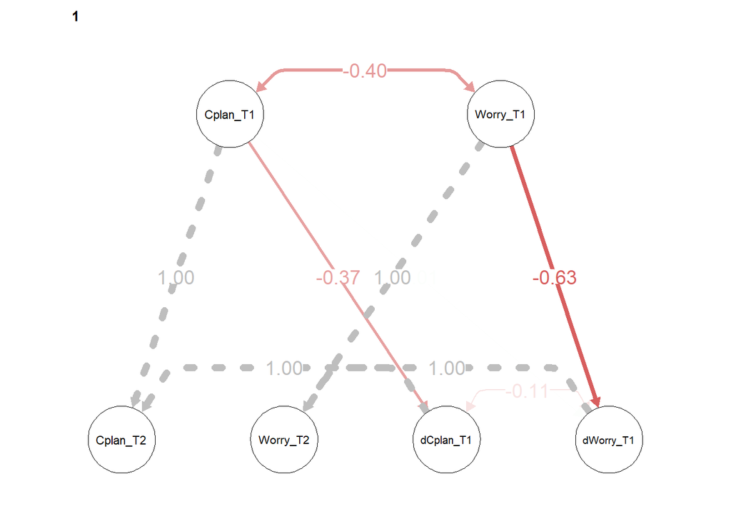

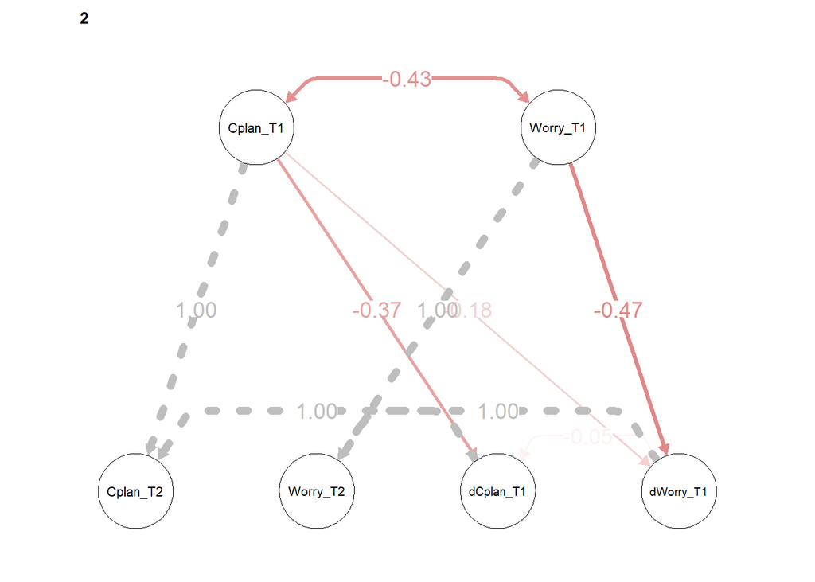

```r
semPaths(fit_BLCS_Cplan_worry, what = "est", layout = "tree", intercepts = FALSE, residuals = FALSE, structural = TRUE, sizeMan = 4, sizeLat = 10, nCharNodes = 0, edge.label.cex = 1.3, fixedStyle = c("grey",3), curvePivot = TRUE)
```

```r
mydat_multi <- my_dat %>%
  zap_label(.) %>%
  zap_labels(.) %>%
     mutate_at("t2job", funs(dplyr::recode(., `1` = 2L, `3` = 2L, `2` = 1L, `4` = 1L)))

BLCS_cplan_se<-'
SE_T1=~1*t1se_1+t1se_2+t1se_3+t1se_4+t1se_5+t1se_6+t1se_7+t1se_8  # This specifies the measurement model for SE_T1
SE_T2=~1*t2se_1+equal("SE_T1=~t1se_2")*t2se_2+equal("SE_T1=~t1se_3")*t2se_3
+equal("SE_T1=~t1se_4")*t2se_4+equal("SE_T1=~t1se_5")*t2se_5+equal("SE_T1=~t1se_6")*t2se_6+equal("SE_T1=~t1se_7")*t2se_7+equal("SE_T1=~t1se_8")*t2se_8


t1se_1~~t2se_1   # This allows residual covariance on indicator 1 across T1 and T2
t1se_2~~t2se_2
t1se_3~~t2se_3
t1se_4~~t2se_4
t1se_5~~t2se_5
t1se_6~~t2se_6
t1se_7~~t2se_7
t1se_8~~t2se_8

t1se_1~~t1se_1   # This allows residual variance on indicator 1 at T1
t1se_2~~t1se_2
t1se_3~~t1se_3
t1se_4~~t1se_4
t1se_5~~t1se_5
t1se_6~~t1se_6
t1se_7~~t1se_7
t1se_8~~t1se_8

t2se_1~~t2se_1   # This allows residual variance on indicator 1 at T2
t2se_2~~t2se_2
t2se_3~~t2se_3
t2se_4~~t2se_4
t2se_5~~t2se_5
t2se_6~~t2se_6
t2se_7~~t2se_7
t2se_8~~t2se_8

t1se_1~0*1   # This constrains the intercept of ind 1 to 0 at T1
t1se_2~1
t1se_3~1
t1se_4~1
t1se_5~1
t1se_6~1
t1se_7~1
t1se_8~1

t2se_1~0*1    # This constrains the intercept of ind 1 to 0 at T2
t2se_2~equal("t1se_2~1")*1
t2se_3~equal("t1se_3~1")*1
t2se_4~equal("t1se_4~1")*1
t2se_5~equal("t1se_5~1")*1
t2se_6~equal("t1se_6~1")*1
t2se_7~equal("t1se_7~1")*1
t2se_8~equal("t1se_8~1")*1


Cplan_T1=~1*t1cpl_1+t1cpl_2+t1cpl_3+t1cpl_4+t1cpl_5+t1cpl_6      # This specifies the measurement model
Cplan_T2=~1*t2cpl_1+equal("Cplan_T1=~t1cpl_2")*t2cpl_2+equal("Cplan_T1=~t1cpl_3")*t2cpl_3+equal("Cplan_T2=~t1cpl_4")*t2cpl_4+equal("Cplan_T2=~t1cpl_5")*t2cpl_5+equal("Cplan_T2=~t1cpl_6")*t2cpl_6


t1cpl_1~~t2cpl_1   # This allows residual covariance on indicator 1 across T1 and T2
t1cpl_2~~t2cpl_2
t1cpl_3~~t2cpl_3
t1cpl_4~~t2cpl_4
t1cpl_5~~t2cpl_5
t1cpl_6~~t2cpl_6

t1cpl_1~~t1cpl_1   # This allows residual variance on indicator 1 at T1
t1cpl_2~~t1cpl_2
t1cpl_3~~t1cpl_3
t1cpl_4~~t1cpl_4
t1cpl_5~~t1cpl_5
t1cpl_6~~t1cpl_6


t2cpl_1~~t2cpl_1   # This allows residual variance on indicator 1 at T1
t2cpl_2~~t2cpl_2
t2cpl_3~~t2cpl_3
t2cpl_4~~t2cpl_4
t2cpl_5~~t2cpl_5
t2cpl_6~~t2cpl_6


t1cpl_1~0*1    # This constrains the intercept of ind 1 to 0 at T1
t1cpl_2~1
t1cpl_3~1
t1cpl_4~1
t1cpl_5~1
t1cpl_6~1


t2cpl_1~0*1       # This constrains the intercept of ind 1 to 0 at T2
t2cpl_2~equal("t1cpl_2~1")*1
t2cpl_3~equal("t1cpl_3~1")*1
t2cpl_4~equal("t1cpl_4~1")*1
t2cpl_5~equal("t1cpl_5~1")*1
t2cpl_6~equal("t1cpl_6~1")*1


Cplan_T2 ~ 1*Cplan_T1     # Fixed regression of Cplan_T2 on Cplan_T1
dCplan_T1 =~ 1*Cplan_T2     # Fixed regression of dCplan_T1 on Cplan_T2
dCplan_T1 ~ 1             # This estimates the intercept of the change score
Cplan_T1 ~  1           # This estimates the intercept of Cplan_T1
Cplan_T2 ~ 0*1          # This line constrains the intercept of Cplan_T2 to 0


SE_T2 ~ 1*SE_T1     # Fixed regression of SE_T2 on SE_T1
dSE_T1 =~ 1*SE_T2     # Fixed regression of dSE_T1 on SE_T2
SE_T2 ~ 0*1
SE_T2 ~~ 0*SE_T2


dCplan_T1 ~~  dCplan_T1       # This estimates the variance of the change scores
Cplan_T1 ~~   Cplan_T1    # This estimates the variance of the Cplan_T1
Cplan_T2 ~~   0*Cplan_T2    # This estimates the variance of the Cplan_T1

dSE_T1 ~ 1
SE_T1 ~ 1
dSE_T1 ~~ dSE_T1
SE_T1 ~~ SE_T1


#dCplan_T1~Cplan_T1+SE_T1 # This estimates the Cplan to Worry
# coupling parameter and the Worry to Worry self-feedback

dSE_T1~SE_T1+Cplan_T1
dCplan_T1~0*SE_T1+Cplan_T1

Cplan_T1 ~~ SE_T1
dCplan_T1 ~~ dSE_T1

'

fit_BLCS_cplan_se <- lavaan(BLCS_cplan_se, data=mydat_multi, group = "t2job", estimator='mlr',fixed.x=FALSE,missing='fiml')
summary(fit_BLCS_cplan_se, fit.measures=TRUE, standardized=TRUE, rsquare=TRUE)
```

```
## lavaan 0.6-5 ended normally after 233 iterations
##
##   Estimator                                         ML
##   Optimization method                           NLMINB
##   Number of free parameters                        206
##   Number of equality constraints                    21
##   Row rank of the constraints matrix                21
##
##   Number of observations per group:
##     2                                               61
##     1                                              160
##   Number of missing patterns per group:
##     2                                                2
##     1                                                2
##
## Model Test User Model:
##                                               Standard      Robust
##   Test Statistic                              1268.447    1223.534
##   Degrees of freedom                               683         683
##   P-value (Chi-square)                           0.000       0.000
##   Scaling correction factor                                  1.037
##     for the Yuan-Bentler correction (Mplus variant)
##   Test statistic for each group:
##     2                                          642.769     620.010
##     1                                          625.678     603.525
##
## Model Test Baseline Model:
##
##   Test statistic                              4889.680    4533.835
##   Degrees of freedom                               756         756
##   P-value                                        0.000       0.000
##   Scaling correction factor                                  1.078
##
## User Model versus Baseline Model:
##
##   Comparative Fit Index (CFI)                    0.858       0.857
##   Tucker-Lewis Index (TLI)                       0.843       0.842
##
##   Robust Comparative Fit Index (CFI)                         0.862
##   Robust Tucker-Lewis Index (TLI)                            0.848
```

[output cut: 417 more lines]

```
##     t1cpl_2           0.799
##     t1cpl_3           0.750
##     t1cpl_4           0.680
##     t1cpl_5           0.683
##     t1cpl_6           0.387
##     t2cpl_1           0.622
##     t2cpl_2           0.724
##     t2cpl_3           0.688
##     t2cpl_4           0.532
##     t2cpl_5           0.710
##     t2cpl_6           0.272
##     SE_T2             1.000
##     dCplan_T1         0.286
##     Cplan_T2          1.000
##     dSE_T1            0.147
```

```r
parameterEstimates(fit_BLCS_cplan_se)
```

```
##           lhs op       rhs block group             label    est    se      z
## 1       SE_T1 =~    t1se_1     1     1                    1.000 0.000     NA
## 2       SE_T1 =~    t1se_2     1     1              .p2.  1.294 0.217  5.967
## 3       SE_T1 =~    t1se_3     1     1              .p3.  1.459 0.218  6.685
## 4       SE_T1 =~    t1se_4     1     1              .p4.  1.471 0.297  4.958
## 5       SE_T1 =~    t1se_5     1     1              .p5.  1.164 0.233  4.993
## 6       SE_T1 =~    t1se_6     1     1              .p6.  1.335 0.223  5.978
## 7       SE_T1 =~    t1se_7     1     1              .p7.  1.484 0.465  3.190
## 8       SE_T1 =~    t1se_8     1     1              .p8.  0.950 0.393  2.416
## 9       SE_T2 =~    t2se_1     1     1                    1.000 0.000     NA
## 10      SE_T2 =~    t2se_2     1     1     SE_T1=~t1se_2  1.294 0.217  5.967
## 11      SE_T2 =~    t2se_3     1     1     SE_T1=~t1se_3  1.459 0.218  6.685
## 12      SE_T2 =~    t2se_4     1     1     SE_T1=~t1se_4  1.471 0.297  4.958
## 13      SE_T2 =~    t2se_5     1     1     SE_T1=~t1se_5  1.164 0.233  4.993
## 14      SE_T2 =~    t2se_6     1     1     SE_T1=~t1se_6  1.335 0.223  5.978
```

[output cut: 467 more lines]

```r
paras_fit_BLCS_cplan_se<- parameterEstimates(fit_BLCS_cplan_se)[c(115, 118, 116, 235, 238, 236), ]
paras_fit_BLCS_cplan_se$label <- NULL
paras_fit_BLCS_cplan_se
```

```
##           lhs op      rhs block group    est    se      z pvalue ci.lower
## 115    dSE_T1  ~    SE_T1     1     1 -0.628 0.187 -3.364  0.001   -0.993
## 118 dCplan_T1  ~ Cplan_T1     1     1 -0.386 0.098 -3.918  0.000   -0.579
## 116    dSE_T1  ~ Cplan_T1     1     1  0.058 0.056  1.026  0.305   -0.052
## 235    dSE_T1  ~    SE_T1     2     2 -0.330 0.143 -2.313  0.021   -0.609
## 238 dCplan_T1  ~ Cplan_T1     2     2 -0.365 0.070 -5.210  0.000   -0.503
## 236    dSE_T1  ~ Cplan_T1     2     2  0.093 0.052  1.799  0.072   -0.008
##     ci.upper
## 115   -0.262
## 118   -0.193
## 116    0.168
## 235   -0.050
## 238   -0.228
## 236    0.195
```

```r
paras_fit_BLCS_cplan_se[, 7] <- format.pval(paras_fit_BLCS_cplan_se[ , 7], eps = .001, digits = 3)
rownames(paras_fit_BLCS_cplan_se) <- NULL

fit_BLCS_cplan_se_meas <- generate_cfa_fitmeasures(fit_BLCS_cplan_se)
```

```
## # A tibble: 1 x 10
##   Chi_Sq   df      p     CFI   TLI   AIC       BIC       RMSEA RMSEA.CI    SRMR
##   <chr>    <chr>   <chr> <chr> <chr> <chr>     <chr>     <chr> <glue>      <chr>
## 1 1268.447 683.000 0.000 0.858 0.843 13806.398 14435.058 0.088 0.081-0.096 0.081
```

```r
for (i in seq_along(fit_BLCS_cplan_se_meas)) {
    if (is.numeric(i)) {
      round(i, 3)
    }
}
```

# 11 Mediation

## 11.1 The effect of T1 Career planning on T2 Worry ‘mediated’ by T2 Self-efficacy

```r
t1cplan_t2se_t2worry <- '
# measurement model:
t1cpl =~ t1cpl_1+t1cpl_2+t1cpl_3+t1cpl_4+t1cpl_5+t1cpl_6
t2se =~ t2se_1+t2se_2+t2se_3+t2se_4+t2se_5+t2se_6+t2se_7+t2se_8
t2wor =~ t2wor_1 + t2wor_2 + t2wor_3+ t2wor_4

t2wor ~ b*t2se + c* t1cpl
t2se ~ a*t1cpl
indirect := a * b
total    := c + (a * b)
'
set.seed(1234)
fit_t1cplan_t2se_t2worry <- lavaan::sem(model = t1cplan_t2se_t2worry, data = my_dat, se = "bootstrap", bootstrap = 1000, missing = "fiml")
summary(fit_t1cplan_t2se_t2worry, fit.measures=TRUE, standardize=F, rsquare=TRUE,
        estimates = TRUE, ci = TRUE)
```

```
## lavaan 0.6-5 ended normally after 66 iterations
##
##   Estimator                                         ML
##   Optimization method                           NLMINB
##   Number of free parameters                         57
##
##                                                   Used       Total
##   Number of observations                           299         300
##   Number of missing patterns                         2
##
## Model Test User Model:
##
##   Test statistic                               324.380
##   Degrees of freedom                               132
##   P-value (Chi-square)                           0.000
##
## Model Test Baseline Model:
##
##   Test statistic                              2717.463
##   Degrees of freedom                               153
##   P-value                                        0.000
##
## User Model versus Baseline Model:
##
##   Comparative Fit Index (CFI)                    0.925
##   Tucker-Lewis Index (TLI)                       0.913
##
## Loglikelihood and Information Criteria:
##
##   Loglikelihood user model (H0)              -5064.127
##   Loglikelihood unrestricted model (H1)             NA
##
##   Akaike (AIC)                               10242.254
##   Bayesian (BIC)                             10453.180
##   Sample-size adjusted Bayesian (BIC)        10272.411
##
## Root Mean Square Error of Approximation:
##
##   RMSEA                                          0.070
##   90 Percent confidence interval - lower         0.060
```

[output cut: 105 more lines]

```
##     t2se_5            0.598
##     t2se_6            0.556
##     t2se_7            0.305
##     t2se_8            0.327
##     t2wor_1           0.613
##     t2wor_2           0.499
##     t2wor_3           0.325
##     t2wor_4           0.741
##     t2se              0.220
##     t2wor             0.426
##
## Defined Parameters:
##                    Estimate  Std.Err  z-value  P(>|z|) ci.lower ci.upper
##     indirect         -0.156    0.037   -4.238    0.000   -0.234   -0.092
##     total            -0.301    0.052   -5.773    0.000   -0.403   -0.196
```

```r
library(lavaan)
parameterEstimates(fit_t1cplan_t2se_t2worry)
```

```
##         lhs op     rhs    label    est    se      z pvalue ci.lower ci.upper
## 1     t1cpl =~ t1cpl_1           1.000 0.000     NA     NA    1.000    1.000
## 2     t1cpl =~ t1cpl_2           0.880 0.039 22.403  0.000    0.804    0.955
## 3     t1cpl =~ t1cpl_3           0.832 0.047 17.802  0.000    0.745    0.928
## 4     t1cpl =~ t1cpl_4           0.788 0.050 15.780  0.000    0.693    0.895
## 5     t1cpl =~ t1cpl_5           0.927 0.050 18.442  0.000    0.834    1.034
## 6     t1cpl =~ t1cpl_6           0.694 0.057 12.216  0.000    0.581    0.805
## 7      t2se =~  t2se_1           1.000 0.000     NA     NA    1.000    1.000
## 8      t2se =~  t2se_2           1.149 0.098 11.739  0.000    0.996    1.384
## 9      t2se =~  t2se_3           1.097 0.090 12.199  0.000    0.926    1.284
## 10     t2se =~  t2se_4           1.210 0.109 11.121  0.000    1.016    1.461
## 11     t2se =~  t2se_5           1.166 0.129  9.053  0.000    0.939    1.448
## 12     t2se =~  t2se_6           1.060 0.129  8.206  0.000    0.823    1.341
## 13     t2se =~  t2se_7           0.859 0.167  5.151  0.000    0.569    1.215
## 14     t2se =~  t2se_8           0.859 0.165  5.223  0.000    0.560    1.223
```

[output cut: 51 more lines]

```r
paras_fit_t1cplan_t2se_t2worry<- parameterEstimates(fit_t1cplan_t2se_t2worry)[c(64,65), ]
paras_fit_t1cplan_t2se_t2worry$label <- NULL
paras_fit_t1cplan_t2se_t2worry[, 7] <- format.pval(paras_fit_t1cplan_t2se_t2worry[ , 7], eps = .001, digits = 3)
rownames(paras_fit_t1cplan_t2se_t2worry) <- NULL

library(glue)
BLCS_Cplan_worry_meas <- generate_cfa_fitmeasures(fit_t1cplan_t2se_t2worry)
```

```
## # A tibble: 1 x 10
##   Chi_Sq  df      p     CFI   TLI   AIC       BIC       RMSEA RMSEA.CI    SRMR
##   <chr>   <chr>   <chr> <chr> <chr> <chr>     <chr>     <chr> <glue>      <chr>
## 1 324.380 132.000 0.000 0.925 0.913 10242.254 10453.180 0.070 0.060-0.079 0.048
```

```r
for (i in seq_along(BLCS_Cplan_worry_meas)) {
    if (is.numeric(i)) {
      round(i, 3)
    }
}
```

```r
library(kableExtra)
knitr::kable(BLCS_Cplan_worry_meas, escape=FALSE, digits = 3, format = "html", booktabs = TRUE, caption = "The effect of career planning on worry mediated by self-efficacy: Model Fit") %>%
  kable_styling(position = 'left', full_width = F)
```

The effect of career planning on worry mediated by self-efficacy: Model Fit

| Chi_Sq | df | p | CFI | TLI | AIC | BIC | RMSEA | RMSEA.CI | SRMR |
| --- | --- | --- | --- | --- | --- | --- | --- | --- | --- |
| 324.380 | 132.000 | 0.000 | 0.925 | 0.913 | 10242.254 | 10453.180 | 0.070 | 0.060-0.079 | 0.048 |

```r
kableExtra::kable(paras_fit_t1cplan_t2se_t2worry, booktabs = TRUE, digits = 3, format = 'html', escape = FALSE, caption = "The effect of career planning on worry mediate' by self-efficacy: Inirect and total effect") %>%
  kable_styling(position = 'left', full_width = F)
```

The effect of career planning on worry mediate’ by self-efficacy: Inirect and total effect

| lhs | op | rhs | est | se | z | pvalue | ci.lower | ci.upper |
| --- | --- | --- | --- | --- | --- | --- | --- | --- |
| indirect | := | a*b | -0.156 | 0.037 | -4.238 | <0.001 | -0.234 | -0.092 |
| total | := | c+(a*b) | -0.301 | 0.052 | -5.773 | <0.001 | -0.403 | -0.196 |

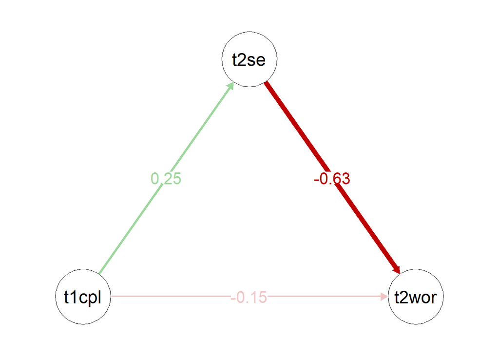

```r
lyot <- matrix(c(-0.5, 0.0, 0, 0.5, 0.5, 0), ncol = 2, byrow = T)
semPaths(fit_t1cplan_t2se_t2worry, what = "est", layout = lyot, intercepts = FALSE, residuals = FALSE, structural = TRUE, sizeMan = 4, sizeLat = 12, nCharNodes = 0, edge.label.cex = 1.6, fixedStyle = c("grey",3), curvePivot = TRUE)
```

# References

Ball, Charlie. 2018. “Graduate labour market myths.” In *Graduate Careers in Context - Research, Policy, and Practice*, edited by Ciaran Burke and Fiona Christie. Taylor & Francis.

Ballas, D., and D. Dorling. 2007. “Measuring the impact of major life events upon happiness.” *International Journal of Epidemiology* 36 (6): 1244–52. https://doi.org/10.1093/ije/dym182.

Bandura, Albert. 2000. “Self-efficacy: The foundation of agency.” In *Control of Human Behavior, Mental Processes, and Consciousness*, edited by Walter J. Perrig and Alexander Grob, 16–31. Psychology Press.

Chen, Gilad, Stanley M. Gully, and Dov Eden. 2001. “Validation of a New General Self-Efficacy Scale.” *Organizational Research Methods* 4 (1): 62–83. https://doi.org/10.1177/109442810141004.

Chung, Y. B. 2002. “Career Decision-Making Self-Efficacy and Career Commitment: Gender and Ethnic Differences Among College Students.” *Journal of Career Development* 28: 277–84. https://doi.org/https://doi.org/10.1023/A:1015146122546.

Clore, G. L., K. Gasper, and E. Garvin. 2001. “Affect as information.” In *Handbook of Affect and Social Cognition*, edited by J. P. Forgas, 121–44. Mahwah, NJ: Lawrence Erlbaum Associates.

Creed, Peter A., Tracy Fallon, and Michelle Hood. 2009. “The relationship between career adaptability, person and situation variables, and career concerns in young adults.” *Journal of Vocational Behavior* 74 (2): 219–29. https://doi.org/10.1016/j.jvb.2008.12.004.

Del Corso, Jennifer, and Mark C. Rehfuss. 2011. “The role of narrative in career construction theory.” *Journal of Vocational Behavior* 79 (2): 334–39. https://doi.org/10.1016/j.jvb.2011.04.003.

Gould, Sam. 1979. “Characteristics of Career Planners in Upwardly Mobile Occupations.” *Academy of Management Journal* 22 (3): 539–50. https://doi.org/10.5465/255743.

Hirschi, Andreas. 2009. “Career adaptability development in adolescence: Multiple predictors and effect on sense of power and life satisfaction.” *Journal of Vocational Behavior* 74 (2): 145–55. https://doi.org/10.1016/j.jvb.2009.01.002.

Koen, Jessie, Ute-Christine Klehe, and Annelies E. M. Van Vianen. 2012. “Training career adaptability to facilitate a successful school-to-work transition.” *Journal of Vocational Behavior* 81 (3): 395–408. https://doi.org/10.1016/j.jvb.2012.10.003.

Leach, Tony. 2017. “‘It seems at the moment my career is dependent on factors outside of my control’: reflections on graduates’ experiences of employment and career enactment in an era of economic uncertainty and austerity.” *British Journal of Guidance & Counselling* 45 (2): 188–98. https://doi.org/10.1080/03069885.2016.1254724.

Lent, Robert W., Steven D. Brown, and Gail Hackett. 1994. “Toward a Unifying Social Cognitive Theory of Career and Academic Interest, Choice, and Performance.” *Journal of Vocational Behavior* 45 (1): 79–122. https://doi.org/10.1006/jvbe.1994.1027.

Ng, Thomas W. H., Lillian T. Eby, Kelly L. Sorensen, and Daniel C. Feldman. 2005. “PREDICTORS OF OBJECTIVE AND SUBJECTIVE CAREER SUCCESS: A META-ANALYSIS.” *Personnel Psychology* 58 (2): 367–408. https://doi.org/10.1111/j.1744-6570.2005.00515.x.

Rijsoort, Stella van, Paul Emmelkamp, and Geert Vervaeke. 1999. “The Penn State Worry Questionnaire and the Worry Domains Questionnaire: structure, reliability and validity.” *Clinical Psychology & Psychotherapy* 6 (4): 297–307. https://doi.org/10.1002/(SICI)1099-0879(199910)6:4<297::AID-CPP206>3.0.CO;2-E.

Savickas, Mark L. 2005. “The theory and practice of career construction.” In *Career Development and Counseling: Putting Theory and Research to Work*, edited by Steven D Brown and Robert W Lent, 42–70. New Jersey: John Wiley & Sons.

Skorikov, Vladimir. 2007. “Continuity in adolescent career preparation and its effects on adjustment.” *Journal of Vocational Behavior* 70 (1): 8–24. https://doi.org/10.1016/j.jvb.2006.04.007.

Stringer, Kate, Jennifer Kerpelman, and Vladimir Skorikov. 2011. “Career preparation: A longitudinal, process-oriented examination.” *Journal of Vocational Behavior* 79 (1): 158–69. https://doi.org/10.1016/j.jvb.2010.12.012.

Stumpf, Stephen A, Arthur P Brief, and Karen Hartman. 1987. “Self-efficacy expectations and coping with career-related events.” *Journal of Vocational Behavior* 31 (1): 91–108. https://doi.org/10.1016/0001-8791(87)90037-6.

Sweeny, Kate, and Michael D. Dooley. 2017. “The surprising upsides of worry.” *Social and Personality Psychology Compass* 11 (4): e12311. https://doi.org/10.1111/spc3.12311.

Worthy, Darrell A., Kaileigh A. Byrne, and Sherecce Fields. 2014. “Effects of emotion on prospection during decision-making.” *Frontiers in Psychology* 5 (June). https://doi.org/10.3389/fpsyg.2014.00591.